# Historical Dynamics_Why States Rise and Fall.Turchin2003.历史动力学_国家为何兴衰

历史动力学：国家为何兴衰

[美]彼得·图尔钦 著

陆殷莉 刁琳琳 译

中信出版集团

## 目录

“比较译丛”序

前言

致谢

第1章 问题陈述

1.1 我们在历史问题上为何需要数学理论？

1.2 历史动态研究项目

1.3 总结

第2章 地缘政治

2.1 动态研究的基础知识介绍

2.2 柯林斯的地缘政治理论

2.3 结论：作为一阶进程的地缘政治

2.4 总结

第3章 集体团结

3.1 社会学中的群体

3.2 集体团结和历史动态

3.3 总结

第4章 元民族边境理论

4.1 边境是群体团结的孵化器

4.2 数学理论

4.3 总结

第5章 对元民族边境理论的实证检验

5.1 设置检验

5.2 结果

5.3 位置优势？

5.4 结论：欧洲的形成

5.5 总结

第6章 民族动力学

6.1 新并入人口的忠诚度动态

6.2 理论

6.3 实证检验

6.4 结论：自动催化模型的数据支持

6.5 总结

第7章 人口结构理论

7.1 人口动态和国家崩溃

7.2 数学理论

7.3 实证应用

7.4 总结

第8章 人口数量的长周期

8.1 前言

8.2 人口动态的“规模”和“阶”

8.3 长期实证模式

8.4 人口动态和政治动荡

8.5 总结

第9章 案例研究

9.1 法国

9.2 俄罗斯

第10章 结语

10.1 主要事态发展综述

10.2 将各种机制整合成一个综合机制

10.3 拓宽研究重心

10.4 发展方向是历史动力学理论？

附录A 数学附录

A.1 将汉尼曼模型转化为微分方程

A.2 边境假设的空间模拟

A.3 纳入了阶级结构的人口-结构模型

A.4 精英周期模型

附录B 元民族边境理论中的数据汇总

B.1 “文化区”的简要描述

B.2 边境的量化研究

B.3 对政权规模的量化：公元后第一个千年

B.4 对政权规模的量化：公元后第二个千年

版权页

# “比较译丛”序

2002年，我为中信出版社刚刚成立的《比较》编辑室推荐了当时在国际经济学界产生了广泛影响的几本著作，其中包括《枪炮、病菌与钢铁》《从资本家手中拯救资本主义》《再造市场》（中译本后来的书名为《市场演进的故事》）。其时，通过二十世纪九十年代的改革，中国经济的改革开放取得了阶段性成果，突出标志是初步建立了市场经济体制的基本框架和加入世贸组织。当时我推荐这些著作的一个目的是，通过比较分析世界上不同国家的经济体制转型和经济发展经验，启发我们在新的阶段，多角度、更全面地思考中国的体制转型和经济发展的机制。由此便开启了“比较译丛”的翻译和出版。从那时起至今的十多年间，“比较译丛”引介了数十种译著，内容涵盖经济学前沿理论、转轨经济、比较制度分析、经济史、经济增长和发展等诸多方面。

时至2015年，中国已经成为全球第二大经济体，跻身中等收入国家的行列，并开始向高收入国家转型。中国经济的增速虽有所放缓，但依然保持在中高速的水平上。与此同时，曾经引领世界经济发展的欧美等发达经济体，却陷入了由次贷危机引爆的全球金融危机，至今仍未走出衰退的阴影。这种对比自然地引发出有关制度比较和发展模式比较的讨论。在这种形势下，我认为更有必要以开放的心态，更多、更深入地学习各国的发展经验和教训，从中汲取智慧，这对思考中国的深层次问题极具价值。正如美国著名政治学家和社会学家李普塞特（Seymour Martin Lipset）说过的一句名言：“只懂得一个国家的人，他实际上什么国家都不懂”（Those who only know one country know no country）。这是因为只有越过自己的国家，才能知道什么是真正的共同规律，什么是真正的特殊情况。如果没有比较分析的视野，既不利于深刻地认识中国，也不利于明智地认识世界。

相比于人们眼中的既得利益，人的思想观念更应受到重视。就像技术创新可以放宽资源约束一样，思想观念的创新可以放宽政策选择面临的政治约束。无论是我们国家在上世纪八九十年代的改革，还是过去和当下世界其他国家的一些重大变革，都表明“重要的改变并不是权力和利益结构的变化，而是当权者将新的思想观念付诸实施。改革不是发生在既得利益者受挫的时候，而是发生在他们运用不同策略追求利益的时候，或者他们的利益被重新界定的时候”<sup>[1]</sup>。可以说，利益和思想观念是改革的一体两面。囿于利益而不敢在思想观念上有所突破，改革就不可能破冰前行。正是在这个意义上，当今中国仍然是一个需要思想创新、观念突破的时代。而比较分析可以激发好奇心，开拓新视野，启发独立思考，加深对世界的理解，因此是催生思想观念创新的重要机制。衷心希望“比较译丛”能够成为这个过程中的一部分。

[1] Dani Rodrik,“When Ideas Trump Interests: Preferences,Worldviews,and Policy Innovations,”NBER Working Paper 19631,2003.

# 前言

很多历史进程都是动态的：人口的增长和衰落、帝国的疆域扩张和收缩、政治的集权/分权趋势以及世界宗教的扩散，这些只是其中数例而已。研究动态系统的一般方法是根据特定机制提出对立假设，将这些假设转化为数学模型，并将模型预测与实证模式进行对比。数学建模是本项研究的一个关键要素，因为纯靠语言描述是无法全面理解定量动态现象的——它经常会受到复杂反馈（complex feedback）的影响。另一个重要因素是充分利用统计技术（如时间序列分析）对模型预测模式和实际观察模式进行定量和严格的对比。事实证明，这种一般方法在自然科学中的应用非常成功。但它能否有助于加深我们对历史进程的理解呢？

《历史动力学》一书正是为了回答这个问题而做出的尝试。我们选择了农业国家的疆域动态这个具体问题进行分析。换言之，我们能否弄明白为什么有些政体在某些时候会扩张，而在另外一些时候会收缩？这种聚焦于疆域扩张/收缩的做法有一个优势，那就是我们在历史动态这一领域有着相当准确的实证数据（历史地图集）。之所以重点关注农业政体，既是因为实证材料的丰富程度（大致从公元前第三个千年到公元后1800 年），也是因为这些社会与现代政体相比要简单得多，因而更易于理解和建模。

虽然本书的主要着眼点是疆域动态，但很显然，国家能否扩张很大程度上取决于其内部特征。因此，要想弄明白国家如何以及为何扩张和收缩，我们需要研究社会动态的军事、经济、人口、民族和意识形态等多个方面。我研究了四个有望解释疆域动态的社会学理论。第一个理论是兰德尔·柯林斯（Randall Collins）的地缘政治模型。这是一个清晰明确的理论，稍做努力就可以将之转换成数学模型。与之形成对比的第二个理论是一种原创设想。根据14世纪阿拉伯思想家伊本·赫勒敦（lbn Khaldun）的观点和社会生物学的最新发展，我提出了一个旨在解释集体行动能力为什么会因社会而异的理论。第三个理论研究了民族同化/宗教信仰转变的动态问题。最后，第四个理论关注的是人口动态与社会政治稳定之间的相互作用。人口增长与国家崩溃之间的关联是根据杰克·戈德斯通（Jack Goldstone）的人口-结构模型（这也是一个清晰明确的理论，很容易转换成动态模型）得出来的。在这个模型中，我添加了反馈机制并假设了国家崩溃和由此导致的社会政治不稳定会对人口数量产生怎样的负面影响。这四个理论分别涉及历史动态的不同领域，因此从逻辑上来说并不是相互排斥的。不过，我们可以依据它们来推导对特定实证模式的备择假说（alternative hypothese）并用数据进行检验。我在书中介绍了一些这样的实证检验。

# 致谢

多位人士对前期的全书草稿或章节草稿提出了诸多意见。我要特别感谢Tom Hall、Jack Goldstone、Sergey Nefedov和一位匿名审稿人，他们阅读了全稿并提出了极为中肯的意见和批评。我还要向Marc Artzrouni、Robert Boyd、Christopher Chase-Dunn、Randall Collins、Lev Ginzburg、Robert Hanneman、John Komlos和Nikolai Rozov致以深深的谢意，感谢他们对本书前几稿各个部分所提的意见。非常感谢Svetlana Borinskaya、Andrey Korotayev和莫斯科社会进化小组其他成员的建设性批评和全方位鼓励。感谢Marc Artzrouni为图2.4提供了仿真模型的图形输出。最后，我要感谢Jennifer Slater的出色编辑、Kathy Tebo在录入和校对方面所给予的帮助以及Mirko Janc的“TeXpert”排版。

# 第1章 问题陈述

## 1.1 我们在历史问题上为何需要数学理论？

为什么有些政体——各种各样的酋邦和国家——能够成功地启动疆域扩张计划并成为帝国？为什么帝国迟早会衰落？历史学家和社会学家对上述疑问和相关问题给出了各种各样的答案。这些答案既有侧重于某一特定政体独有特征的具体解释，也有一般的社会动态理论。人们对解读历史一直怀有莫大的兴趣，不过，近年来这一领域的理论活动有加强趋势（Rozov，1997）。历史社会学正在尝试成为成熟的理论科学。

但是，为什么历史社会学家使用的是如此有限的理论工具？社会科学中的“理论”通常意味着对概念和定义的深思细想。它是语言层面的、概念性的、发散性的。由此得出的理论命题在本质上是定性的。没有人否认这种理论活动的巨大价值，但这还不够。我们还可以采取形式数学方法来构建理论，这些方法已经在物理学和生物学领域取得了极大的成功。但是，使用数学模型的形式理论在历史社会学中非常少见（我们将在后面的章节中介绍一些例外情况）。

科学史明确指出：一门学科通常只有在发展出了数学理论之后才会成熟。如果这门学科涉及动态数量，那就更需要数学理论了（参见下一节）。大家都知道经典力学这一典型实例。但其实生物学有两个离我们更近的实例，分别是20世纪第二个25年里出现的综合进化论（Ruse，1999）和人口生态学中正在发展的综合统一法（如Turchin，2003）。在所有这些案例中，数学理论的发展都为学科的综合提供了推动力。

历史社会学可以采取类似的做法吗？此前人们已经有过几次尝试（如Bagehot，1895；Rashevsky，1968），但它们显然没能对现今的历史研究方法产生影响。我认为这一失败有两个主要原因。首先，这些尝试的灵感直接来自物理科学的成功。然而，物理学家选择研究的系统和现象通常都迥异于历史学的系统和现象。物理学家倾向于选择非常简单的基本没有交互成分的系统（如太阳系、氢原子等）或是由大量同类成分构成的系统（如热力学）。因此，他们可以进行非常精确的定量预测和实证检验。但即便在物理学应用中，这种系统也很少见，而在社会科学中，只有微不足道的问题才能被简化到如此简单的程度。真实社会总是由很多从定性和定量角度来说各不相同的因子构成，它们以非常复杂的方式相互作用。此外，社会不是封闭的系统：它们会受到外部力量（如其他人类社会）和自然世界的强烈影响。因此，适用于简单系统的传统物理方法在历史应用中以失败告终也就不足为奇了。

其次，物理学家时常采取的定量法需要大量精确测量的数据。比如，研究非线性激光动态的物理学家会二话不说地建立起高度可控的实验室设备并着手收集数十万个极其精确的测量结果。然后他们会在高性能计算机上以复杂的方法对这些数据进行分析。而一个历史社会学家面临的问题远非如此，原因是他通常缺乏所研究的历史系统方方面面的数据，而只拥有其他方面零碎而粗略的信息。比如说，对所有社会来说，最重要的一个研究层面就是它拥有多少成员。但即便是这种信息，经常也得由历史学家在大量猜测的基础上进行重建。

如果这两个问题是过往尝试以失败告终的真正原因，那么自然科学近来的一些发展给我们带来了希望。首先，在过去的二三十年间，物理学家和生物学家展开了对复杂系统的协同研究。在此我可以列举出很多方法：非线性动态、协同理论、复杂性等。功能强大的计算机是使这些方法行之有效的关键因素。其次，生物学家和生态学家已经学会了如何处理简短而嘈杂的数据集。同样，强大的计算能力是一个关键性的推动因素，它使非线性模型拟合、平稳自助法（bootstrapping）和交叉验证等运算密集型方法具有了可行性。

此外，社会科学领域也取得了颇有希望的进展。我指的是定量方法在历史领域的兴起，也就是计量史学（Williamson，1991）。目前，有很多研究人员收集了有关历史进程各个方面的定量数据，现在已经有大量电子数据可以查阅。

这些观察结果表明，现在在历史社会学领域再次尝试构建并检验定量理论也许正当其时。即使我们取得的只是片面的成功，但极高的潜在回报让我们有理由再做一次尝试。近年来，建模和定量方法在历史学领域的一些应用已经形成了一些很有意思的洞见。

## 1.2 历史动态研究项目

很多历史进程都是动态的。一般而言，动态学就是科学地研究随时间变化的对象。动态学的一个方面涉及对时间行为（temporal behaviors），即轨迹（有时被称为运动学）的现象学描述。但动态学的核心是研究那些带来时间变化并形成观测轨迹的机制。有一种很常见的方法已经在无数次实际应用中证实了自身的价值，这种方法就是取一个整体现象，设想将其切分成单独的部分并假定这些部分是彼此交互的。这种方法叫动态系统法，因为整个现象被表述为由若干交互元素（或子系统，因为每个元素也可以表现为较低级别的系统）构成的系统。

举例来说，请回想一下本书开篇提出的那个问题。一个帝国是一个动态对象，因为它的各个层面（最明显的是其治下疆域的面积和臣民的数量）会随着时间而变化：帝国或是兴起，或是衰落。对帝国动态的各种解释涉及帝国的不同方面。比如说，我们可能会关注盈余产品攫取和战争的相互作用过程（如Tilly，1990）。然后，我们可以将帝国设定为一个由农民、执政精英、军队以及商人等子系统组成的系统。此外，帝国控制着一定的疆域，周边有一些相邻政体（也就是说，还有一个更高级别的系统，或者说元系统，我们研究的帝国是其中的一个子系统）。在动态系统法中，我们必须用数学方法来描述不同子系统如何交互（可能还要描述元系统中的其他系统如何影响我们的系统）。这一数学描述就是这个系统的模型，我们可以使用各种方法研究模型预测的动态，并将预测结果与实际观测动态进行对比，从而对模型进行检验。

将整体现象视为交互子系统的概念表述总是带有一定程度的人为性。这种人为性本身并不能成为反对某一特定系统模型的论据。所有模型都会对现实情况进行简化。在评估任何一个模型的价值时，都应当将之与可选模型进行对比，并考虑每种模型在预测数据时的准确性、模型的简洁程度以及它的假设会对现实产生多大影响。有一点很重要，那就是请记住，自然科学领域有很多非常有用的模型，而我们都知道它们的假设是错误的。事实上，从定义看，所有模型都是错误的。这不应该成为指责它们的理由。

数学模型在动态研究中尤为重要，因为动态现象的典型特点就是非线性反馈，这种反馈通常会有不同的时滞。如果我们假设的机制是以线性和加性方式运作的（如趋势外推法），那么非形式化的描述模型就足以生成预测，但在处理以非线性和滞后为特点的系统时，它们可能会有极大的误导性。一般而言，非线性动态系统能涵盖的行为在广度上要远远超出非形式推理的想象（比如说，请参见Hanneman et al.，1995）。因此，如果我们希望将关于系统的整套假设与关于其动态行为的预测进行严格关联时，形式化的数学工具是必不可少的。

### 1.2.1 界定问题集

历史给我们提出了很多难题，因此我们必须想好这样的研究将着手探讨哪些问题。我选择的侧重点是政体的疆域动态，原因如下。大部分记录在案的历史都涉及一个政体占领其他政体领土的疆域扩张，而这一目标通常是通过战争实现的。为什么有些政体实现了扩张而另一些政体没能向外扩张？这是历史学领域的一个重要难题，我们从研究帝国兴衰的书籍之众多就可以看出这一点。此外，有关疆域动态变化的时空记录可能是研究人员能够获取的最佳定量数据集之一。比如说，电子地图集CENTENNIA（Reed，1996）提供了欧洲、中东和北非在公元1000—2000年疆域变化的连续记录。对于本书的研究来说，拥有这样的数据是极有价值的，因为它可以提供一个主数据集，我们可以通过该数据集来对比各个模型的预测。

国家疆域的动态也是一个重要因素。正如我在上一节中指出的那样，如果没有形式化的数学工具，就很难对动态现象进行研究。因此，如果我们希望为历史学构建数学理论，就应该选择数学模型最有可能提供重要见解的那些现象。

疆域动态并不代表整个历史，但它是历史的核心维度之一，原因有二。首先，我们需要引用各种社会机制来解释疆域动态，如军事、政治、经济和意识形态进程。因此，如果把侧重点放在疆域变化上，我们就不可能只关注军事和政治史了。其次，国家的特征，如内部稳定和执政精英的财富，本身就是重要的变量，可以解释历史的其他诸多方面，如艺术、哲学和科学的发展。

### 1.2.2 关注农业政体

政体的类别多种多样，既有狩猎采集部落，也有现代后工业化国家。如果我们想要取得研究进展，就必须关注特定的社会经济构成。工业化和后工业化政体的不利之处在于它们的变化步伐相当迅速，社会变得非常复杂（比如说，职业种类众多）。此外，我们离这些社会太近，很难客观地对它们进行研究。而狩猎采集社会的主要劣势是我们在研究时主要只能依靠考古数据。看起来受这两大劣势影响最小的要属农业社会：它们在自身的历史进程中大多数时候都经历着相当缓慢的改变，而且我们对其中很多社会都有足够的历史记录。事实上，95%以上的历史记录都是关于农业社会的历史。为了进一步缩小本书的侧重范围，我基本不会提及游牧社会，也不考虑海扩期的城邦国家（不过，这两种政体都非常重要，我将在别处对它们展开论述）。

这样的话，我们仍有一大段人类历史可以使用，大致范围是公元前4000年至公元1800年或1900年，具体视地区而定。我的主要研究对象是公元500—1900年的欧洲，但偶尔也会涉足中国。不过这一理论理应适用于所有农业政体，因此我们的目标是在世界其他地区对理论进行检验。

### 1.2.3 分层建模法

动态系统建模有一条启发式“经验法则”：不要在模型中包含两个以上的层级。违反这条规则的模型是那种尝试模拟系统内交互子系统的动态和每个子系统内子子系统交互作用的模型。使用基于个体的仿真模拟进行跨国动态建模也违反了这一规则（除非我们是对简单的酋邦建模）。从实际操作角度看，即使功能强大的计算机也需要很长时间才能模拟出由数百万因子构成的系统。更重要的是，从概念角度来看，很难对这种多级模拟的结果进行解读。实践表明，在解决涉及多级系统的问题时，需要分开处理每个级别的相关问题；或者更确切地说，应该是每对级别的相关问题（较低级别提供机制，上一级是我们观察模式时所需的级别）。

因此，在本书所做的研究中，我考量了三类模型。在第一类模型中，个体（或者也可能是个体家庭）交互决定了群体动态。这些模型的目标是为了弄清楚基于个体的机制如何生成群体层面的模式。在第二类中，我们立足于群体层面的机制研究政体层面产生的模式。最后，第三类模型解决的是政体在跨国层面如何交互的问题。重中之重将是第二类模型（群体-政体）。我知道，这些内容目前听起来相当抽象；尤其是我所说的“群体”到底是什么意思？我会等到第3章再来讨论这个重要问题。此外，我并不想过于教条地遵循两个级别这一规则。如果我们发现规则限制过多，就应该打破规则；重要的是，只在必要的时候才这样做。

### 1.2.4 数学框架

理论构建的难点是：选择将被建模的机制，对不同子系统的交互方式做出假设，选择函数形式，估算参数。一旦完成所有这些工作，获取模型预测从概念上来说将是一件直截了当的事儿，只不过这个过程充满技术性，费力且耗时。对于简单一些的模型来说，我们也许会有现成可用的分析（通过分析法来求解模型意味着导出一个公式，给出所有参数值的精确解）。但是，一旦模型达到中等复杂度，我们一般就得使用第二种方法：在计算机上以数字方式求解。第三种方法是使用基于行为人的模拟（agent-based simulation，ABS）模拟（Kohler and Gumerman，2000）。这些获取模型预测的方法不应被视为严格意义上的三选一方案。相反，一个成熟的理论会同时使用所有这三种方法。

比如说，基于行为人的模拟是一非常强大的工具，如果假定构成一个社会的个人是以某种特定方式行事的话，就可以用它来调查这个社会的新兴属性（如果将行为人重新定义为个人群体或整个政体，我们还可以用这种方法来解决更高级别的问题）。基于行为人的模拟很容易扩展，我们可以添加各种随机因素，通常也可以模拟任何能够想到的机制。原则上，可以只使用基于行为人的模拟来构建理论。然而，在实际操作中，只侧重这类模型是一种糟糕的做法。实际操作方面的一个限制是，当前可用的计算能力虽然令人叹为观止，但这种能力并不是无限的，因而限制了我们在基于行为人的模拟中能够处理的复杂程度。更重要的是，基于行为人的模拟具有概念上的缺陷。目前并没有统一的语言可用于描述基于行为人的模拟，因此除了那些专攻这类模型所用的计算机语言的人之外，每个模型对其他人来说都是晦涩难懂的。微小的操作细节就有可能导致预测动态的天差地别，只有在极少数情况下，使用不同语言的从业者才会交叉翻译其基于行为人的模拟［一个罕见的例外情况请参见Axelrod（1997）］。最后，基于行为人的模拟的强大之处同时也是它们的软肋所在：由于向模型中添加子元素太过容易，因此它们很快就会变得太过复杂而难以理解。

基于微分（或差分）方程的更传统的动态系统建模语言具有几个优点。首先，它已经实现了极大程度的标准化，因此，建立微分方程系统的模型比描述相同假设的计算机代码更容易理解。当然，前提是观察该模型的人对这些方程有着丰富的经验，遗憾的是，大多数社会科学家乃至生物学家都不符合这一要求。尽管如此，我们还是希望非物理科学的计算水平会随着时间的推移而提高，而本书在此也许会有一些帮助。其次，对大多数简单或中等复杂的模型来说都有现成的分析结果可用。即使我们没有明确的分析（大多数非线性模型都是如此），我们也可以在这些模型预测的长期动态的定性层面获取一些分析性见解。再者，用于求解微分模型的数值计算法现在已经实现了高度标准化。因此，其他研究人员可以轻松看懂作者的数值结果。总之，微分（差分）方程为动态研究中的理论构建提供了一种极为有效的通用语言。

请注意，我并不反对使用基于行为人的模拟。事实上，近来有人提出通过构建虚拟社会自下而上地研究社会科学（Epstein and Axtell，1996），我认为这样的想法着实令人兴奋［请参见Kohler and Gumerman（2000），这一杰作阐述了这种方法在应用于社会科学中的实际问题时具有哪些优势］。事实上，我的建议是在使用基于行为人的模拟时一定要用其他方法对之予以补充，这些方法可能不如基于行为人的模拟那么强大，但它们更善于从一团乱麻的现实当中提取并交流重要的见解。理论构建的最佳方法就是利用从对模型的纸笔人工计算到对行为人模拟的数值求解等所有可以利用的工具。

## 1.3 总结

我对历史动态理论构建研究提出了以下建议，以此来总结序章论述的内容。

●明确需要解决的问题：农业政体的疆域动态。主要问题是：为什么某些政体在某些时候会向外扩张？为什么它们在另外一些时候会收缩甚至完全退出历史舞台？更具挑战性的问题是，帝国崛起和消亡的根本原因是什么？

●确定主数据集：世界某一地区在某一时间段内有关疆域动态的时空记录。数据集的作用是充当各种机械理论的检验平台。每种理论的成功与否取决于它所做的预测与主数据中定量模式的拟合程度。

●确定一组假说，其中每个假说都提出一个特定的机制或一组机制来解释政体的疆域扩张/收缩。其中很多假设已被前人提出来过，另外一些则可能需要重新构建。假说清单无须做到详尽无遗，但是根据知识现状来看最有可能的几个假说应当被包括在内。各种假说之间也无须相互排斥。

●将列表中的所有假说都转换成数学模型。通常情况下，我们会设定不同的函数形式和参数值，将单个假说转换成一系列模型。

●确定辅助数据。这里指的是我们针对每个特定假说及其相关模型所需的数据。比如，若一个假说认为人口增长与国家崩溃之间存在联系，那么我们就需要人口动态方面的数据。（除了主数据检验之外）辅助数据也为假设的辅助检验奠定了基础。因此，基于人口动态的假说所做的预测应该与人口数据中观察到的模式相匹配。而基于正当性动态的假说就无须预测人口数据；相反，它的预测应当与正当性随时间而波动的情况相匹配。

●使用合理的技术（即分析、数值和模拟法）对模型求解。选择在假说/模型之间存在分歧的模型输出（output）特征，并通过主数据集判定哪个假说在这个方面的预测要好于其他假说。需要被纳入考量的有每个假说预测合理辅助数据的能力、由假设生成的模型的简约程度以及相关的循环性（比如说，在同一数据被同时用于参数估算和模型检验时）。尝试选择使用最少数量的自由参数并对数据的各种特征做出最佳预测的一个（或多个）模型。

●重复该过程，加入其他假说并寻找更多可用于检验各种模型的数据。

显然，这是一种高度理想化的做法，从实证角度来说近乎天真。在实际操作中，它不太可能像上文描述的那样行之有效。不过，设定很高的目标有其意义所在。本书接下来的内容都在尽量尝试着遵循这一研究方案。我们将会看到，现实情况会以各种令人警醒的方式形成干扰。我认为，虽然不能实现上述远大目标，但研究结果仍深具启发。不过，这一点尚需交由读者评判。

# 第2章 地缘政治

本书中所指的地缘政治是狭义上的，它涉及的是历史动态的空间层面。地缘政治模型引用的机制有两大类：远距离投射力量的能力和空间位置的影响。因此，在回顾国家疆域动态理论时，地缘政治是一个自然而然的起点。此外，它是历史社会学中理论化程度最高的领域之一（如Collins，1978，1986，1995），而且其现有的形式化模型可能是数量最多的（见下文）。不过，我在本章中的论述表明，狭义的地缘政治模型不足以解释实证模式；特别需要指出的是，它们无法解释之前力量强大且疆域广阔的政体为何会进入持续的衰落。

## 2.1 动态研究的基础知识介绍

我没有立即从地缘政治模型着手，而是就一些能够通过动态系统表现出来的一般行为回顾了一些相关的基本事实。虽然这是一些相当基本的事实，但它们还是值得探讨的，因为（1）它们可能并不为那些在动态模型方面缺少丰富经验的人所熟知；（2）我可以借此机会介绍一个简单的分类方案，然后在整本书中都可以参照这一方案。法拉罗（Fararo，1989）对动态社会系统有过深入的介绍。

### 2.1.1 无限增长

线性增长是最简单的动态模型，它遵循以下微分方程

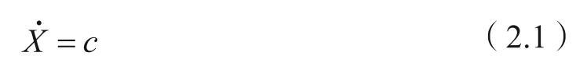

这里的X是一个变量，而是X的变化率（通常写为dX/dt），c是一个常量。这个模型有一个广为人知的应用，那就是牛顿第一定律，在该定律中，X是物体的位置，而c是恒定的速度（牛顿第一定律指出，在没有任何外力作用于物体的情况下，它将保持匀速运动）。该方程的解是X（t）=X<sub>0</sub>+ct，其中t为时间，X<sub>0</sub>是物体的初始位置，X（0）=X<sub>0</sub>。这个解表明，X会随时间而出现线性变化（图2.1a），变化率为c。因此，我将这种动态称为线性增长（如果c为负数的话，则是线性下降）。

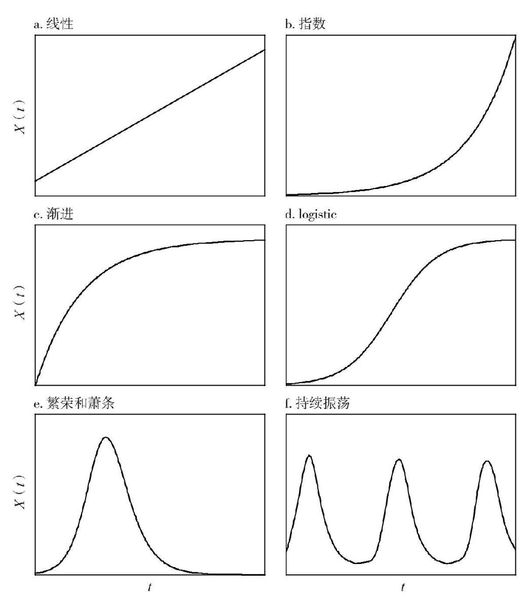

图2.1 动态的定性类型

另一种简单增长模型遵循以下微分方程：

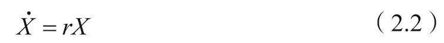

这是一个指数增长模型。参数r是另一个常量，被称为相对变化率（因为总变化率是相对变化率r和X的乘积）。由于X的变化率被设定为与X成正比，因此这种类型的增长有时被称为自动催化型增长：X越多，它增长得就越快。指数方程为生物种群的增长提供了最简单的模型，可被视为种群动态第一定律（Turchin，2003）。自动催化部分的出现是因为种群中的动物越多，种群增长的速度就越快（因为每只动物都可以繁殖）。指数模型的解是一条向上弯曲的曲线（图2.1b）。

线性和指数模型都属于无限增长。这类模型通常为动态系统建模提供了良好的起点，因为它们对系统所做的假设是最少的。换言之，它们属于原模型（null model），这也是力学和种群动态第一定律属于这类模型的原因所在。但是，无限增长模型本身对绝大多数动态现象来说并不是合适的模型，因为现实生活中很少有系统能够无限增长。我们需要在方程的右边添加其他机制。

### 2.1.2 平衡动态

现实生活中很少有过程会无限制地增长。一般都会有一些机制——通常被称为负反馈——对增长形成上限和下限。负反馈机制最重要的特征之一是它的运行滞后性。一些反馈机制的运行时标（time scale）要远远快于建模变量X的变化时标。在这种情况下，我们通常会忽略时滞并假设反馈是瞬时发生的。给线性增长加上瞬时负反馈之后，我们得出了下面这个简单模型

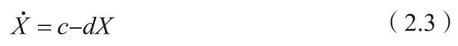

此处有两个过程影响X的动态。一个力以恒定的速率c推动X增长，但同时也存在一个反作用力，其强度与X成比例增长。在某些时候（特别是当X达到X*=c/d时），正推力和负拉力的强度达到平衡，X停止增长。X的变化率为零的点，即X*，被称为平衡点。平衡点可能是稳定的，也可能是不稳定的。对于这个模型来说，平衡点X*是稳定的，因为当X低于平衡点的时候，正推力超过了负拉力；反之亦然，如果X超过了X*，那么负拉力将会超过正推力，使X回到平衡点。方程2.3预测的X的典型轨迹在最初是线性的（当X处于低值时），然后随着X接近平衡点，逐渐出现渐进式减慢（图2.1c）。我将把这种动态称为线性渐进增长，或简称为渐进增长。

将负反馈添加到指数增长模型中也很简单。在这里，让我们设定相对增长率r是X的线性函数：r（X）=r<sub>0</sub>-gX。这样我们就得出了logistic方程

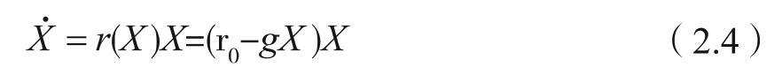

logistic增长如图2.1d所示。

渐进和logistic动态都属于一维或一阶微分模型。一阶模型的一般形式是=f（X），其中f（X）是X的任意函数。例如，在logistic模型中，f（X）=（r<sub>0</sub>-gX）X是X的二次函数。这些模型被称为一阶（或一维）模型，因为它们只有一个结构变量X［在数学应用中，结构变量被称为状态（state）变量，因为它们描述了系统的状态。然而，在动态系统中使用这个标准术语会产生不必要的混淆，因为本书的主要研究对象是政体意义上的国家（英文也为state）］。

在渐进和logistic模型显示的动态类型中，系统总会被引向一个独一无二的稳定平衡点，除了这两种动态之外，一维模型也可以呈现更复杂的行为，即所谓的亚稳定动态。比如说，如果f（X）是三次多项式，那么模型就是

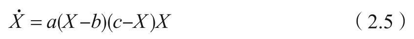

（a、b和c是正常量），那么就会出现三个平衡点：两个稳定的平衡点（一个低平衡，一个高平衡），一个位于中间的不稳定平衡点。如果X最初低于不稳定平衡点，则轨迹会被引至低平衡点。如果X一开始位于不稳定平衡点之上，则轨迹会被引至高平衡点。这种方程式在社会科学中的一个应用就是对“临界”（tipping）行为建模（见第6章）。

我们需要知道一个非常重要的事实以供后用，那就是一阶微分模型无法生成振荡动态。它们甚至无法呈现一次单一的（升降）振荡。由于快速负反馈没有明显滞后，因此无法造成动态系统的振荡。如果存在稳定的平衡点，它们只能使系统渐进地回到平衡点（如果不存在平衡点，那么系统将会逃逸到+∞）。要想产生振荡，负反馈必须延时生效。我们要么通过在微分方程模型中添加其他结构变量对直接建模这种慢速反馈直接建模，要么通过使用离散时间（差分）模型来对这种反馈间接建模。

### 2.1.3 繁荣/萧条动态和持续振荡

为了用微分方程模拟X的繁荣/萧条动态，我们需要明确另一个结构变量，我们将之称为Y，它受到X的影响，反过来，它本身也会影响X。因此，X会受到由Y传导的负反馈循环的影响。我们来看看下面这个消费者群体的简单生物模型（该群体以不可再生资源为生）

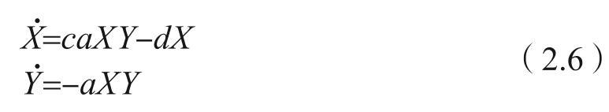

在这个模型中，X是时间为t时的消费者数量，Y是当前的资源总量。首先来看一下Y方程，我们会看到代表消费率的-aXY项（负号表示消费在减少现有资源量）。我假设的是消费与X和Y的乘积成正比，原因如下。首先，更多消费者会更快地耗尽资源。其次，个体消费者在资源充足的时候消耗资源的速度会超过资源稀缺的时候。再来看X方程，我假设消费者与已消耗资源量是成比例增加的，c是比例常量（caXY项）。此外，消费者的消亡速度与X成正比（比例常量d亦可称为相对或人均死亡率）。

这个模型的动态如图2.1e所示。假设初始资源充足，那么消费者一开始会出现增长，因为他们的“出生率”（caXY）会超过“死亡率”（dX）。与此同时，由于消费者的数量越来越多，资源被消耗殆尽的速度越来越快。最终，资源跌到了消费者出生率超过死亡率的水平以下，消费者人数开始减少。由于消费者仍在消耗资源，因此即使在人数减少阶段，系统崩溃也没有结束。X将一直减少至0。繁荣之后必将出现萧条。

对2.6式表示的模型做出修改并使其经历反复的繁荣/萧条周期是件轻而易举的事情。比如说，我们可以添加一项假设，即资源是可再生的，而且在没有消费者的情况下会以指数方式增长。将指数增长项bY加到第二个方程中，我们就得到了

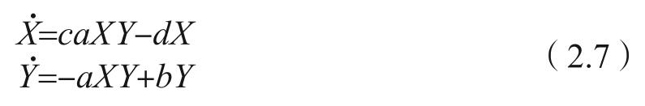

这就是著名的洛特卡-沃尔泰拉（Lotka-Volterra）捕食者-猎物周期模型（X的典型轨迹如图2.1f所示）。

二阶和更高阶的微分模型（含有两个或更多结构变量的模型）能够呈现多种多样的动态行为。它们可以具有稳定的平衡点，这个平衡点既可以单调接近（如一维模型），也可以以振荡方式接近。它们可以表现出稳定的循环，其特点是带有一定的周期和振幅。含有三个或更多结构变量的模型可以生成混沌振荡（预测不规则的动态）或准周期性振荡（两个或更多个循环周期彼此叠加）。令人着迷的数学现象不胜枚举，但我们在社会动态调查中无须在意这些现象，至少在很长一段时间内都无须这样做。就我们的研究目标而言，二阶振荡是一种重要的一般动态类型。至于它们是极限循环、准周期还是混沌，这从当前的技术水平来说并不重要。它们的重要特点是持续的增长期和随后出现的持续下降期，这一特点使它们不同于一阶动态。

非线性动态理论得出的另一个重要结果是，负反馈循环的运行时标（即它们有多快）和动态的时标（如平均振荡周期）之间存在密切关系。在2.7式等微分方程模型中，负反馈发挥作用的速度与模型的参数值是显式关联的，尤其是那些单位为（时间）或（时间）<sup>-1</sup>的参数值。在洛特卡-沃尔泰拉模型中，有两个单位为（时间）<sup>-1</sup>的参数：d和b。参数d衡量的是消费者数量在缺乏资源的情况下（指数）下降的速度；与此类似，参数b衡量的是资源在没有消费者的情况下（指数）增长的速度。这两个参数决定了消费者-资源系统的振荡周期。事实上，该周期与b和d的几何平均值成反比关系（给对数学感到好奇的人士解释一下：中性稳定平衡点附近的振荡周期是）。因此，消费者和资源群随时间变化的速度越快，振荡周期越短。在比洛特卡-沃尔泰拉模型更复杂的模型中，周期公式更为复杂，但得出的定性结论是一样的：更快的反馈导致更快的振荡（如果反馈太快，那么我们甚至无法获得振荡，因为动态会被非常快速的反馈机制稳定下来）。

### 2.1.4 对历史动态的启示

到目前为止，我们对动态的探讨都只聚焦于内生因素，即参与动态反馈的变量。在纯内生系统中，任何波动都只是内生变量相互作用的结果；就外部影响而言，这些系统是“封闭的”。然而，历史社会系统始终都受到外部力量的影响：气候波动导致作物歉收、新的流行病突然出现、敌人入侵、新宗教传播等。影响动态系统但自身并不受系统变量影响的因素被称为外生因素。内生因素和外生因素之间的区别并不明显，而且通常取决于我们选择的问题。举例来说，如果我们关注的是单一政体的内部动态，那么我们将把其他政体的入侵模拟成外生因素。但是，如果我们决定扩展模型来研究交互各国组成的整个系统或世界体系的动态（Wallerstein，1974；Chase-Dunn and Hall，1997），那么入侵就变成了内生因素。

历史社会系统的开放性没有给动态系统法造成任何问题。模拟这类影响最自然的办法是将外生结构变量添加到方程式之中。例如，如果我们已经有了内生变量X和Y，再添加一个外生变量Z，那么方程式看起来就是如下这样

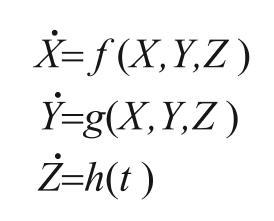

其中f、g和h为一些函数。也就是说，X和Y的变化率取决于系统中的全部三个变量，而Z的变化率则是由一些与时间相关的函数决定的。模拟Z的通用方法有两种：（1）将之视为随机变量或（2）将之视为确定性趋势。至于我们选择哪种方法，则取决于外生变量的性质以及我们想要提出的问题。

在第2.1.1至2.1.3节中，我介绍了三种基本类型的表征纯内生系统的动态。最简单的类型包含不受负反馈影响的系统。我把这种动态称为零阶动态。其次，有些系统仅受快速反馈的影响，我称之为一阶动态。最后，有些系统包含多个内生变量，导致负反馈循环在发挥作用的时候有滞后。这些是二阶系统。

加入外生变量之后，这一分阶类型就可以自然而然地归纳如下。零阶系统的特点是下面这个一般模型：

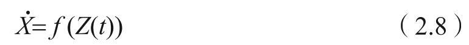

实际上，X本身就是外生变量。这类系统的例子包括各种随机游走模型（有偏或其他）、随机指数式增长或减少模型等。此类系统通常不具有模型平衡密度来上下波动（除非我们以非常特殊的方式设置函数f，以外生力量强制生成这样的“平衡”）。从动态角度看，零阶系统并不是很有吸引力，因为在这些系统中发现的任何系统性动态模式都要完全归因于外生变量的作用。如果将动态系统法应用于这样的体系，可谓大材小用。不过，零阶动态是一种天然的原模型，可用来验证其他更复杂的备择模型。

一阶系统的模型形式如下：

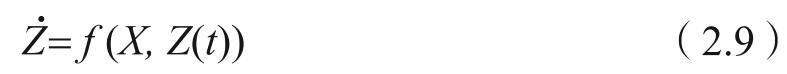

其中Z是外生变量，并不依赖于X。如果Z是随机变量，而且f包含负反馈，那么这类动态则以随机平衡为特征。X在稳定平衡点附近波动，如果X变得过高或过低，内生动态会将其推回至平衡波动水平（换言之，动态过程的特点就是回归趋势）。一阶系统中不会出现循环或任何其他类型的复杂动态行为，除非它们是由外生力量强加的（例如，Z周期性地振荡）。

二阶系统的模型如下

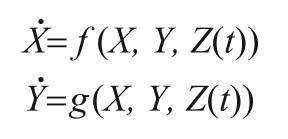

其中Z仍然是一个外生变量。涉及的内生变量可能有两个以上。二阶系统能够处理各种复杂动态：稳定平衡、极限循环、准周期性、混沌、多个共存吸引子等。添加随机性之后又进一步扩展了可能出现的行为范围。不过，就本书而言，我将把所有此类行为都称为二阶振荡。也许以后我们会有足够的方法和数据来区分历史系统中的极限周期和混沌，但现在还没到这个时候。区分这三种动态的根本重要性在于，在零阶系统中，所有动态都是外生力量驱动的，而在一阶和二阶系统中，波动方差有一部分是由内生变量的作用造成的。此外，不同的社会机制通常可被分类为快速或慢速反馈，并相应地生成一阶或二阶动态。我们这一历史动态研究的主要目标之一就是探查这种诱发振荡的反馈并描绘其特征。

## 2.2 柯林斯的地缘政治理论

兰德尔·柯林斯的著作（Randall Collins，1978，1986，1995）是最有影响力的地缘政治理论表述之一；具体请参见罗佐夫（Rozov，1997）。柯林斯明晰而简洁地陈述了他的地缘政治原理，因此这一描述性理论可以相对容易地转化为数学模型。此外，柯林斯及其同事也提出了计算机模拟的地缘政治形式模型（Hanneman et al.，1995）。我打算在本节回顾柯林斯提出的假设并将它们转化为简单的差分模型，我也会对汉尼曼等人（Hanneman et al.，1995）的模拟模型做同样的处理，从中总结出共同特性。还有一个模型也与我们要处理的问题相关，那就是阿兹佐尼和卡姆洛斯（Artzrouni and Komlos，1996）的空间模拟。

### 2.2.1 对疆域面积和距离效应建模

柯林斯的观点在过去20年里有所演变，因此下文的内容将立足于他在1995年发表的文章，尤其是文中的图1（在此我将它重新绘制为图2.2）。需要关注的主要变量是国家的疆域规模，或者说面积。战争胜利会给这个变量带来时间变化。从“战争胜利”到“疆域规模”的正箭头表明，当国家在战争中获胜时，它就会赢得领土，而战争失败则意味着领土损失。疆域规模也会对“地缘政治资源”（更多的税收和征兵）产生正面影响，这又反过来对战争胜利产生正面影响。疆域规模的扩大也意味着“后勤负荷”的增加。从大本营向外投送军事力量的距离越远，成本就越高（Collins，1995，第1558页）。此外，更多的国家资源被用于监控民众和攫取资源。疆域规模和后勤负荷之间的这种关联通常被称为“帝国过度扩张”原理（Kennedy，1987）。后勤负荷的增加反过来又会对战争胜利产生负面影响。最后，“边陲位置”（marchland position）有利于战争胜利，因为周边敌国较少的国家在扩张时牺牲的是那些被敌国包围的国家的利益（Collins，1995，第1555页）。不过，随着国家在扩张过程中逐渐远离最初受到更多保护的位置，国家扩张将会削弱边陲优势。

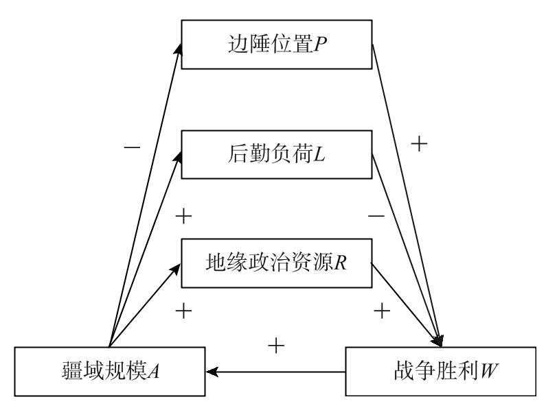

图2.2 柯林斯地缘政治模型的反馈结构

资料来源：Collins（1995），图1。

现在，我们将这个理论转换成形式模型，先从涉及地缘政治资源的环路开始，然后再加上后勤负荷的影响。边陲位置需要空间显式处理法（spatially explicit approach），我将在下一节中探讨这个问题。在构建以下模型时，我将做出两个一般假设。第一点也是最重要的一点，那就是我将假设：从疆域动态的角度来说，各种反馈的运作非常迅速。这样的话，我就可以将常微方程用作数学框架。其次，为了让模型更加具体，我将假设简单的函数形式，通常都是线性函数。这些假设对结果的影响将在下面予以讨论。

第一个模型中有三个变量：疆域规模或面积A、地缘政治资源R和战争胜利W。我将设定A的变化率与战争胜利为线性关系：=c<sub>1</sub>W，其中c<sub>1</sub>是比例常数，它将战争胜利转化为所获疆域的平方公里数。资源大致上应该与面积成正比（在最简单的情况下，如果人口密度大致不变，扩张的面积就意味着有更大的人口基数来缴纳税款、应征入伍）。因此，R=c<sub>2</sub>A。最后，资源与战争胜利之间的关系较为复杂。资源转化为国力，但是为了赢取胜利，国力必须大于对手的国力。假设我们所研究的国家（焦点国家）处于一个同质环境之中，其特征是竞争对手的军事力量恒定不变，那我们就会得出W=c<sub>3</sub>R-c<sub>4</sub>。常数c<sub>3</sub>将资源转化为国力，而c<sub>4</sub>则是必须被击败的对手的国力。焦点国家的国力越是强于对手国家的国力，它在战争中获胜的可能性就越大，其结果是，它的疆域扩张速度也就越快。综合这些设定并经过一些代数操作，我们得到了以下模型：

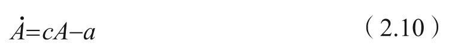

我在此设定c=c<sub>1</sub>c<sub>2</sub>c<sub>3</sub>，a=c<sub>1</sub>c<sub>4</sub>，以消除没有必要的参数组合。

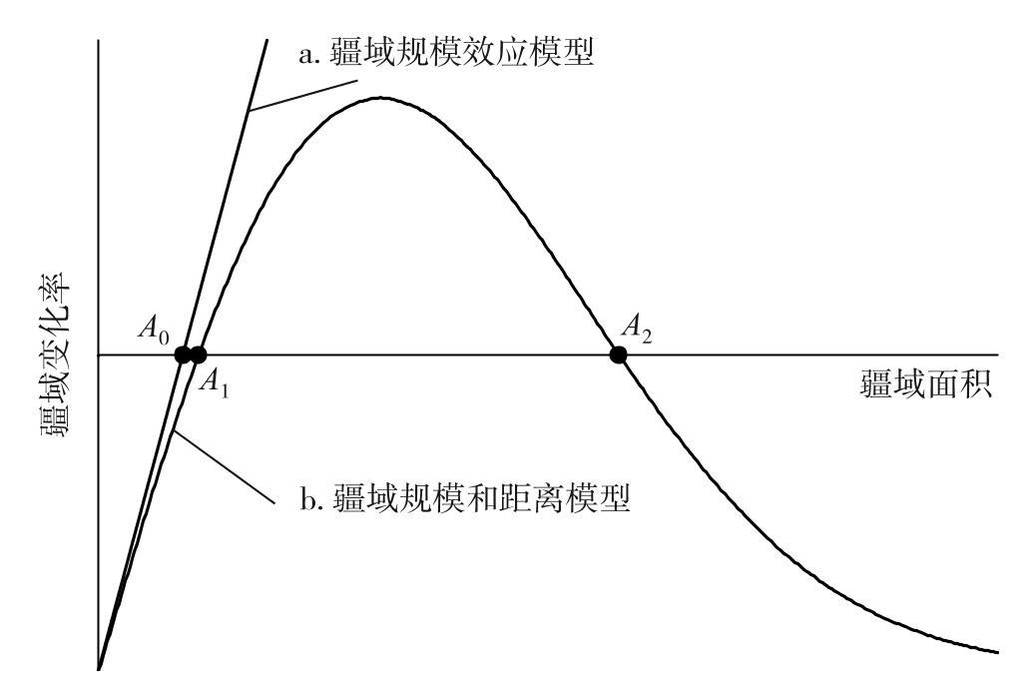

图2.3 两个简单地缘政治模型中疆域变化率和疆域A之间的关系

该线性模型的动态非常简单，取决于该国的初始疆域面积（见图2.3a）。如果初始A低于阈值A<sub>0</sub>=a/c，则变化率为负，A将逐渐减小至0。但是，如果A在一开始的时候高于阈值，那么它将以指数方式（加速）增长至无穷大。换句话说，我们在此面对的是一个零阶类型的动态。这并不令人意外，因为在我们目前已经建立的模拟循环中，所有箭头都有与它们相关的加号。换句话说，我们刚刚建立了一个正反馈循环，并取得了完全可预测的结果。

而涉及后勤负荷的循环有一个减号，因此它是一个负反馈循环。为了模拟后勤负荷的影响，让我们跟随柯林斯的思路，假设帝国的过度扩张起因于远距离投射帝国力量的难度。换言之，如果中心位置的国力是P<sub>0</sub>，那么在距离r处的国力就是P<sub>0</sub>L（r），其中L（r）是后勤距离乘数，当r=0时，其值为1，当r=∞时，其值为0。博尔丁（Boulding，1962，第245—247页）提出了这样一个论点：后勤距离乘数会随着r的增加以负指数函数形式下降：L(r)=exp[-r/c<sub>5</sub>]，其中c<sub>5</sub>控制着国力随距离而下降的速度。由于面积与半径之间的关系为A~r<sup>2</sup>，因此后勤距离乘数为L(r)=exp[-/c<sub>7</sub>]。将这一关系代入模型之后，我们就得出了

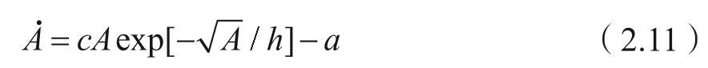

其中参数组合再次被单个参数取代。图2.3b显示，国力的强弱是通过它的扩张能力衡量的，它在低A时为负值（就像在纯规模模型中那样），而且最初的时候会随A增加。然而，后勤负荷增加带来的影响终将显现。当A=4h<sup>2</sup>时，国力达到最大化，当A＞4h<sup>2</sup>时它开始下降。共有两个平衡点，即A<sub>1</sub>和A<sub>2</sub>。A<sub>1</sub>与纯规模模型中的A<sub>0</sub>相类似，是不稳定的：如果初始条件低于A<sub>1</sub>，那么国家会被邻国吞并。A<sub>2</sub>是一个稳定的平衡点：在它之下，国家扩张的能力是正值，A会增加；在它之上，国家扩张率为负，A会下降（图2.3b）。

还有一种可选公式，那就是假设国力随着距离的增加而出现高斯曲线式下降，即c<sub>5</sub>exp[-r<sup>2</sup>/c<sub>6</sub>]。作为现象描述，高斯曲线看起来很实用，因为它在国家中心的附近——这里是交通最为便利之处——是平坦的，然后开始加快下降。采取这种设定会生成一个稍有不同的模型：。该模型中和A之间关系的定性图与图2.3b是一样的，因此它对疆域动态的推论与模型2.11完全相同。

请注意，在这个模型中，帝国过度扩张不会导致国家崩溃。将纯规模模型与模型2.11进行对比，我们可以看到，上平衡点A<sub>2</sub>的存在是一个新的特征，事实证明这个平衡点是稳定的。因此，我们现在有了一阶动态模型；繁荣/萧条动态是不可能出现的。这个结果有多大程度的一般性呢？请记住，我们做了两种设定：快速反馈和简单函数形式。首先说一下第二个设定，这也正是我们掌握的动态知识（第2.1节）开始体现出价值的地方。无论各种函数形式具有怎样的非线性，我们最终得到的仍会是一维常微方程模型，它无法生成繁荣/萧条动态和二阶振荡。我们要做的就是再创造几个平衡点，让动态更加接近亚稳定状态。如果我们添加足够的噪声，也许就可以推动国家轨迹在高低平衡点之间跳跃。这样的模型并不十分完美，因为这样的话我们就需要知道是哪些外生力量将轨迹从一个吸引域（basin of attraction）推到另一个吸引域。我们需要明确模拟这些外生力量，最终得出的理论也将与我们在此研究的理论截然不同。

快速反馈的设定对于模型2.11得出的一般理论结果来说更为关键。很显然，无论是通过使用差分方程来隐式添加延迟，还是通过使A之外的某些变量慢慢随时间变化来显式添加延迟，都将形成能够振荡的模型。让我们考虑一下添加这种延迟从实证角度看是否合理。根据历史记录，帝国的发展壮大发生在数十年乃至数百年的时间段内。因此，A是一个慢变量。地缘政治资源可能也会滞后一段时间才显现出来（因为需要时间来“消化”新征服的地区）。但是，R处于正反馈循环之中，R的延迟生效只会减缓国家扩张的速度，但不会导致帝国的崩溃。不过，涉及后勤负荷L的反馈循环应该是在没有明显时滞的情况下运行的。举例来说，距离的影响——即我们对后勤进行建模的方式——是瞬时的：一旦有领土被征占，边界就会进一步远离国家中心，国家立即就需要承担起更高的成本将国力投射到新的边界。其他因素，如管控新征服的人口，也会立竿见影地给国家带来额外负担。

因此，本节的总论点可归纳如下。帝国过度扩张，至少柯林斯和肯尼迪等地缘政治理论学家设想的过度扩张，不应该会导致国家崩溃。这是一个限制了进一步领土扩张的一阶因素。如果国家偶尔超出了这一界限，那么它保卫新增领土的能力立即就会受损。这部分领土可能会被邻国重新征占，还有一种可能是国家可能会放弃它，因为觉得不值得为之费心（正如罗马帝国舍弃了阿格里狄古马特和达西亚那样）。这种后撤恢复了国家的自卫能力。因此，我们需要寻找其他变量来研究实证经验中观察到的帝国崩溃实例。

### 2.2.2 位置效应

要想妥当地研究位置效应，我们确实需要一个空间显式模型，这在实际操作中通常就意味着计算机模拟。然而，在进入模拟之前，一个不错的做法是对模型进行大幅简化并允许其生成分析性见解。即使后续模拟模型显示这些见解完全错误，我们也能从中学到一些东西（至少，我们会知道显式空间是获得正确结果的关键因素）。因此，我们来看一下下面这种简单模型。它是假定领土动态发生在一维空间之中的面积-距离地缘政治模型（方程2.11）的改进版。我将再次设定后勤距离乘数是距离的负指数函数，不过现在我们有了一维空间A~r。由此得出的改进模型是

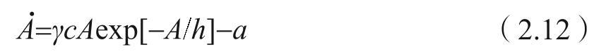

（注意，这个指数函数中没有与A相关的平方根）。附加参数γ取值1或2，具体取决于国家是腹背受敌还是仅在一面受敌。在第二种情况下，国家向这一边界输送的是双倍力量（γ=2）。位置对国家最终面积的影响（γ）是什么？为了做一个粗略计算，我们用1+x概略估算exp[x]并求解A<sub>2</sub>平衡点（上方稳定点）的方程，最后得出

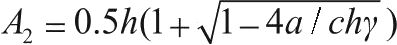

。从这个等式中，我们可以看到，如果γ翻倍的话，平衡点处的国家面积并不会随之翻倍。为了用数值进行说明，我们假定国家在腹背受敌情况下的平衡点面积只是国家崩溃临界面积的两倍，即A<sub>2</sub>=2A<sub>1</sub>。然后，仅在一侧受敌将使A<sub>2</sub>增加约30%。如果A<sub>2</sub>=3A<sub>1</sub>，那么边陲效应所带来的增量就不到20%。因此，这个简单的模型表明，边陲位置应该只会使平衡点处的国家面积出现相当有限的扩大。它的主要影响是为那些面积较小的国家提供一些保护（实际上，边陲效应将国家临界面积A1减少了50%）。

阿兹佐尼和卡姆洛斯模型

现在我要转向阿兹佐尼和卡姆洛斯（1996）构建的领土动态空间模拟，研究那些解释欧洲国家体系形成的假说。这些研究人员将欧洲视为一个由单位正方形组成的网格，其线性尺寸约为40公里。在时间=0的时候（假定它对应的是公元500年），模拟空间里填充了面积相等的国家，每个国家占据5×5个方格，因此我们的起始区域大约为40000平方公里（见图2.4）。

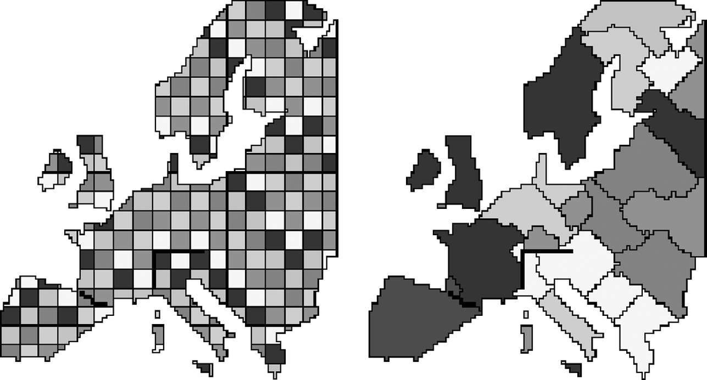

图2.4 阿兹佐尼和卡姆洛斯模型（1996）模拟的欧洲国家体系的疆域动态

注：左图为公元500年时的初始地图。右图为模型预测的公元1800年时的地图。加粗黑线为比利牛斯山脉和阿尔卑斯山脉所在位置。

资料来源：Artzrouni and Komlos（1996），图4。

在阿兹佐尼和卡姆洛斯的模拟中，影响国家实力的两个变量是面积A（以构成一个国家的单位方格的数量来衡量）和边界C（与他国接邻的方格的数量）。A越大就越能增强国力，但是C越大就越会削弱国力，因为更长的边界需要更多的资源来防御。请注意，此处对后勤负荷的概念构想不同于上一节中的构想。对边陲效应的建模是通过区别对待海洋、山脉等国家边界和不存在自然屏障的国家边界来实现的。阿兹佐尼和卡姆洛斯认为海洋边界更容易防守。因此，在计算边界长度时，一单位沿海边界仅被算作一单位陆地边界的一部分，即f。此外，他们认为比利牛斯山脉和阿尔卑斯山脉这两处欧洲山脉提供了坚不可摧的天然屏障，因此与这些区域相邻的单位正方形没有被算作C的一部分。不过，比利牛斯山脉和阿尔卑斯山脉并没有完全将各自的半岛与大陆阻断（见图2.4）。

阿兹佐尼和卡姆洛斯为国家i设定了以下这一特定形式的实力函数：

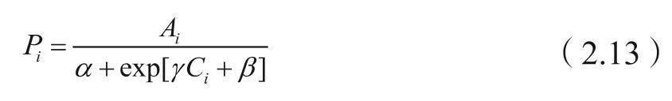

其中A<sub>i</sub>和C<sub>i</sub>分别是国家i的面积和边界，α、β和γ是正常量。虽然这个函数的概念构想与之前有所不同，但它生成的国家面积和国家实力之间关系的大体走向与模型2.11是一样的。当A从0向上增长时，P会先随着A增长，这要归因于与新增地缘政治资源相关的正反馈。然而，最终，与新增后勤负荷相关的负反馈超过了正反馈，当A达到极高值时，P会下降至0。

国家的相对实力决定了它们与邻国交战时获胜的可能性。模型的每次迭代都由一次双边互动（战争）组成。模拟模型随机选择一个国家（i）并将其实力与所有邻国的实力进行对比。然后，模拟会判定哪个邻国j的实力与i国的差异最大（绝对差值|P<sub>i</sub>-P<sub>j</sub>|达到最大值时的j），这两个国家之间随即爆发战争。强国获胜的概率为1-0.5exp[-K(P<sub>i</sub>/P<sub>j</sub>-1)]；不然的话就是弱国获胜。战争结束后，战败国与战胜国相邻的所有边界正方形都被战胜国收归己有。然后，模拟会执行下一次迭代，随机选择一个国家。每次迭代对应的是1/3年。

阿兹佐尼和卡姆洛斯模型有五个参数（f、α、β、γ和K）。研究人员使用了试错法寻找这些参数的具体值，这些数值将尽最大可能复制我们在历史中观察到的欧洲动态地图。图2.4显示了这一模拟获得的结果之一：在模拟结束时，公元500年时的234个初始国家减少到了25个。沿海国家（“法国”、“西班牙”和“意大利”）的轮廓迅速形成，而内陆国家则花了更长时间才固定下来。此外，在不同的结果中，非沿海地区最终布局的可变性要大得多。因此，边陲效应体现在两个方面。首先，与地域更加集中的国家相比，受益于边陲效应的国家实现了稍大的面积（通过图2.4中“西班牙”、“法国”和“瑞典/挪威”取得的较大面积可以看出这一点）。其次，它们的边界比内陆国家的边界更快地达到稳定状态。

总之，阿兹佐尼和卡姆洛斯模拟确认了边陲优势的假定效应。此外，模拟表明，现有国家，尤其是那些有着较长海岸边界的国家（西班牙、法国、意大利和希腊），其边界可能很大程度上是由地缘政治机制决定的。不过，阿兹佐尼和卡姆洛斯非常严谨地指出，必须校准模拟参数才能使模拟达到理想的平衡。虽然参数校准中涉及的循环削弱了结果，但我们应该记住，这一模拟非常简洁，只有五个自由参数。仿真模拟对参数f非常敏感，这一点对边陲效应问题来说格外重要。如果f设置得太低，那么仿真模拟通常只会生成一两个在欧洲西部拥有海岸边界的国家，这些国家一路向东横跨大陆。它们的边界短而实用，这保证了它们的强劲实力并让它们最终吞并了所有的邻国。

最后，与先前提出的分析模型类似，阿兹佐尼和卡姆洛斯的地缘政治模拟生成的基本是一阶行为。大国征服较小国家并最终达到帝国过度扩张的极限，这时国家的面积稳定下来。换句话说，该模型没有预测国家扩张到太大的面积后会崩溃。

### 2.2.3 冲突-正当性动态

柯林斯的地缘政治理论有三个主要原则（Collins，1986，第168页；1995，图1）：（1）领土资源优势，（2）边陲优势，以及（3）新增后勤负荷导致的扩张过度。我们在前面几节中的建模表明，这些假设会生成一阶动态，其特点是疆域面积先是加速增长，但最终会达到稳定的平衡。地缘政治模型没有预测大型帝国的灭亡（不过小国有可能会在成功超过临界面积之前就灭亡）。但是，历史上的帝国却展现出了不同的轨迹，因为它们最终都以灭亡告终。当动态系统对解释性变量集之中的相同变量值表现出相反的趋势时（增长或下降），就意味着还有另一个隐藏变量决定着改变的走向，而我们尚未将这个变量包含在变量集之中。因此，我们的建模工作已经取得了成效：它们表明，要想弄懂领土帝国的兴起和衰落，我们需要找到纯地缘政治原理之外的解释机制。看起来柯林斯也得出了同样的结论，因为他在1995年的文章中大量探讨了国家衰落机制。具体而言，柯林斯讨论了两种理论：（1）人口-结构模型（Goldstone，1991b）和（2）受地缘政治实力-威望影响的统治者正当性（Hanneman et al.，1995）。动态系统理论认为，假定的衰落机制有一个关键属性，那就是它们发挥作用的时标（柯林斯也讨论了时标的概念，如Collins，1995，图6）。因此，我们的任务——这一任务很大程度上超出本章的范围——是将各种假定的非地缘政治机制转化为模型，判断这些模型从原则上说是否能够生成二阶动态，如果能的话，则从中得出可以检验的预测。

虽然汉尼曼等人的冲突-正当性模型并不是立足于（严格意义上的）地缘政治机制，但我还是会在本章中予以介绍，因为这个模型已经发展得比较完善（而且可以快速总结），同时它与之前提到的模型是紧密相关的。实际上，汉尼曼等人构建的不是一个模型，而是一系列复杂程度越来越高的模型。从方法论的角度来说，这是一种合理的办法；事实上，我完全认同汉尼曼等人提出的建模理念。对于他们提出的出色建议（另请参见Hanneman，1988），我只想补充一点，那就是我们应该更关注分析模型的并行构建和思考。

汉尼曼等人所提理论的核心侧重于国力-威望、国家正当性和国际冲突之间的交互作用。汉尼曼等人假定，统治者发起外部冲突的动机与统治者当前正当性和最大正当性目标之间的差距是直接成正比的。不管是哪种程度的冲突，战争胜负都取决于焦点国相对于其对手国在国力上的优势。国家威望的变化与战争胜负成正比，而正当性则随威望变化，但有时滞（Hanneman et al.，1995，第17页）。汉尼曼等人没有解释为什么正当性会随着战争胜负而滞后变化。但是，在他们的模型中，他们设置了相当长的时滞：虽然每个时间步长（time step）都会发生战争（他们使用的是离散时间框架），但正当性的变化要延迟三个时间单位才会显现。这（粗略地）表明，需要在战争中连胜三场才能使国家的正当性大幅提升。与之相反，我认为正当性的显现速度要快得多。战争胜利之后，爱国主义会立即涌现，推高政客的声望；反之亦然，战争失败之后，人民立即就会对国家实力失去幻想。如果正当性是一个慢变量，那么政客就远远没有这么大的动力来使用“一场小胜战”巩固岌岌可危的政权。

汉尼曼等人构建了三种模型：（1）侧重于战争正当性动态的核心模型，（2）加入了帝国成本和收益的复杂版本，以及（3）进一步加入了帝国资本主义和军事工业等复杂因素的完整模型。对我们来说，格外值得关注的是第二个模型，因为就某些参数值而言，它似乎预测了帝国先兴起后衰落的这种循环反复。然而，这些国家衰落的例子看起来依赖于一个很关键的假定，那就是正当性在战争胜利之后的变化是滞后显现的。为了查证这一点是否属实，我将汉尼曼模型的核心转化为微分方程模型。我在附录（请参见A.1节）中指出，正当性-冲突模型是由一维常微分方程描述的。换言之，我们最终又一次得出一阶模型。该模型可以有多个平衡点，轨迹将被吸引到一个或另一个稳定点，具体取决于疆域面积的初始值和先前的战胜记录。但是该模型无法生成繁荣/萧条动态或持续振荡。因此，我们必然会得出这样的结论：正当性、战争胜利和领土扩张之间的相互作用不可能造成持续的帝国衰落。因此，汉尼曼模型中的帝国崩溃似乎完全归因于正当性滞后于战争胜利这一假设。

## 2.3 结论：作为一阶进程的地缘政治

我在本章先是回顾了非线性动态的一些基本事实，之所以这么做是出于以下原因。大多数社会科学家并不熟悉动态系统理论，因此我想对其中与本书所涉问题最相关的一些见解做一个非技术性总结。其中的一点见解是这样的：负反馈发挥作用的时标与动态的性质之间存在着密切关联。如果反馈机制的运行速度远远快于焦点变量的动态，系统就无法振荡，甚至无法表现出单一的繁荣/萧条行为。如果我们真的有一个振荡系统，那么，从定量角度来说，反馈发挥作用的速度决定了动态的时间模式（如振荡或繁荣/萧条周期的平均长度）。这表明，如果反馈循环在以年来计——或者更糟糕，以周来计——的时标上运行，那么它基本不可能引起振荡（后者的平均周期是以世纪衡量的）。长达数百年的循环周期通常是由在数代人（数十年或更长时间）的时标上运作的反馈生成的。

这一看法与帝国繁荣/萧条周期的基础机制问题密切相关。帝国的兴起和衰落是以世纪为时标的（Taagepera，1978a，1978b，1997；另见第4章，图4.4）。我们简单分析一下塔格佩拉（Taagepera，1997）在附录中列出的帝国兴衰数据。塔格佩拉（1997，第480页）将兴起阶段定义为政体从最大面积的20%扩张到80%时所需的时间。我们也可以用类似的方法将衰落阶段定义为国家面积从最大值的80%下降到20%时所需的时间，将峰值阶段定义为兴起阶段的终点到衰落阶段的起点这一时期。表2.1列出了塔格佩拉（1997）中31个政体在各个阶段的持续时长——对于这些政体我们有四次或更多次连续的面积观测结果（我们需要这些数据点来明确定义各个阶段）。这些政体的衰落期持续时长存在很大差异。在大约半数的案例中（14个政体），衰落期持续了约一代人的时间（不到0.3个世纪）。剩下的帝国则表现出更长的衰落期，其中有12个案例的衰落期持续了一个世纪或更长时间。因此，表2.1表明,缓慢的帝国衰落在历史记录中很常见。

表2.1 塔格佩拉所列大型帝国各个阶段（兴起、峰值和衰落）的持续时长（以世纪计）（1997年，附录）

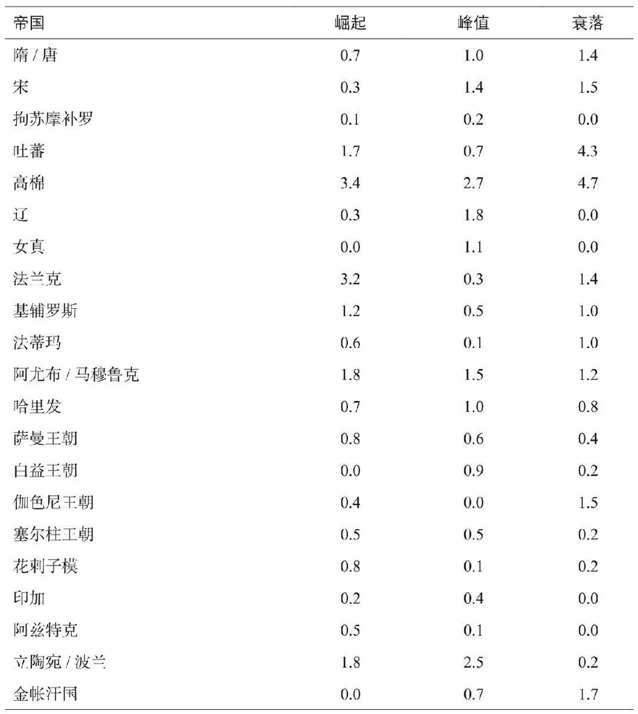

续表

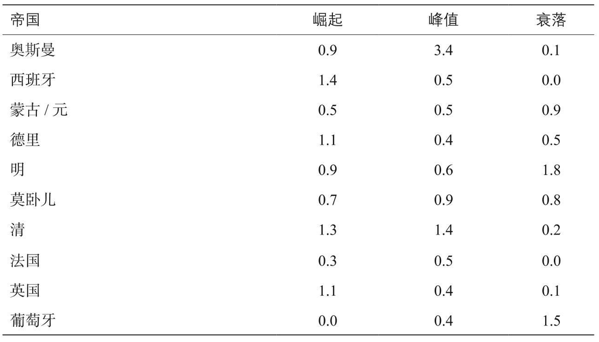

本章的主要观点是，（狭义的）地缘政治变量无法解释漫长的（一个世纪或更长时间的）帝国衰落阶段。诸如后勤负荷和边陲优势丧失等地缘政治变量在发挥作用的时候基本上没有滞后性。一旦征占了更多的领土，国家就必须肩负起抵御外部和内部（叛敌）威胁的责任。同样，一旦战胜国侵入一个中心位置，先前的所有边陲优势都会削弱。确实，面积扩大带来的益处可能要滞后很长时间才会显现，因为要想在新征服的领土上组织生产并说服那里的民众接受国家统治是需要时间的。不过，这一机制是正反馈循环的一部分；它并不是导致帝国衰落的原因。柯林斯和合作者对常见的地缘政治变量进行了扩展，提出国家正当性与战争成败之间的关系可能导致领土过度扩张，随之而来的将是国家崩溃。不过，我们在研究这一观点后发现，这种机制导向的仍是一阶动态（亚稳态），除非我们给战争胜利后的正当性变化加上（在我看来）不切实际的长时间滞后。此外，即便我们设定这种长时间的滞后，汉尼曼等人研究的模型中只有一个模型生成了繁荣-萧条循环，而且，这个模型中的国家崩溃基本上是在一个时间步长内完成的。与之形成对比的是，历史数据表明，帝国衰落往往发生在数十年乃至数百年的时标上（表2.1）。纯粹的地缘政治理论并没能解释这种实证模式。

当然，先前的理论学家并非没有意识到时标的重要性。柯林斯用数页篇幅讨论这个问题（Collins，1995，第1584—1586页），肯尼迪（1987）也反复强调，从长远角度来说，国家的军事实力和生产能力是相互关联的，另外，我们当然也不应该忘记布罗代尔（Braudel，1972）提出的“长时段”（la longue durée）概念。但是，对这个问题的讨论通常都没有超出描述性理论的范畴。正是在这类定量问题中，非线性动态能够发挥很好的作用，因为构建显式模型使我们可以加入假定机制（postulated mechanism）的实证特征（包括它们的变化率）并预测随后的模型动态（例如，兴起和衰落阶段的持续时长）。这样的推演可以帮助我们摒弃一些对立假说。本章中地缘政治模型的构建就是这种一般概念的一个示例。

即使本章提出的时标论点被大家接受，也不意味着（狭义上的）地缘政治机制在解释帝国兴衰的原因时就变得无足轻重。只不过它们并非充分条件，我们必须寻找其他变量以建立所需的理论。一个似乎值得探索的潜在办法就是不再将政体视为“黑匣子”，而是深入其中去研究它们的内在运作。这将是我们在下一章中的目标。

## 2.4 总结

●动态行为可以分为三大类。无限增长或下降的零阶动态出现在不受负面反馈影响的系统之中。具体实例有线性和指数增长/下降过程。而在反馈快速发挥作用的系统中，一阶动态是其典型特征。一阶动态是平衡的；具体实例包括渐进增长和logistic增长过程。一阶动态也可能是亚稳态的（存在着一个以上的稳定平衡点）。最后，二阶动态出现在动态反馈滞后发挥作用的系统中。二阶行为的实例包括单次繁荣/萧条动态和持续的周期性或混沌振荡。

●兰德尔·柯林斯的地缘政治理论假设了三个主要机制来解释国家疆域动态：地缘政治资源、后勤负荷和边陲位置。

●仅包含疆域面积和地缘政治资源之间正反馈的数学模型表现为零阶动态。如果国家初始疆域面积高于某个阈值，那么它将加速增长。不过，如果初始面积低于阈值，那么这个国家就会逐渐萎缩并最终消失。

●将后勤负荷的负反馈加入模型之后，我们得到了亚稳定一阶动态行为。和之前一样，如果初始疆域面积低于阈值，国家就会逐渐失去国土并最终消亡。不过，在起始点位于阈值上方的时候，国家面积不会像简单模型中那样无限制地增长，而是逐渐接近上平衡点。这个平衡点相对于小规模扰动来说是稳定的。

●为了验证位置效应，我转向了阿兹佐尼和卡姆洛斯构建的空间模拟模型。该模型表明，比起内陆国家，从一开始就享有边陲优势的国家（海岸线边界所占比例较高）最终将扩张至较大的面积。然而，该模型没有表现出任何二阶振荡：战败国消失不见，而战胜国则扩张至后勤因素形成的极限，然后它的面积进入稳定状态。

●最后，我回顾了汉尼曼及其同事构建的冲突-正当性动态模拟模型。我发现，如果将这个模型转为微分方程，我们将再次得到一个无法生成二阶振荡的一阶系统。

●在对塔格佩拉的增长/衰落数据表进行分析后可以发现，历史记录中经常出现漫长的帝国衰落过程（超过一个世纪）（31个案例中有12个是这种情况）。这一发现有力地表明，至少在某些历史案例中，帝国动态是受二阶机制支配的。然而，基于纯地缘政治机制的模型并不能预测这种漫长的衰落期。因此，我们必须研究导致帝国崩溃的其他机制。

# 第3章 集体团结

## 3.1 社会学中的群体

### 3.1.1 以群体为分析单位

我在前一章中提出，如果不研究政体内部运作，就无法了解它们的疆域动态。这就向我们提出了一个重要的问题：我们的理论应该构建在什么样的基本单位之上？方法论个体主义的哲学原则认为，社会学理论最终的立足点应该是个体属性。我原则上同意这种方法，尤其是在我们着重强调“最终”这个关键词的情况下。然而，在我看来，我们必须通过两个重要的附加说明来中和方法论个体主义。首先，认为个体在某种程度上要比群体更“真实”的想法似乎并不成立。人类个体无法在脱离群体的情况下仍然保留人类特性［现实生活中的森林之子“毛克利”（Mowglis）证明了这一点］。此外，人类群体不仅仅是个体的简单集合。与动物群体不同，人类群体的独特性在于他们能够制订计划并有目的地实施行动（Alexander and Borgia，1978；Melotti，1987）。

其次，想要一步到位地遵循方法论个体主义这个处方的做法似乎不是一个很好的建模策略（第1.2.3节）。政体，尤其是像帝国这样复杂的政体，包含着众多个体，这些个体可谓千差万别。此外，一个个体主要是与一小部分人进行互动，而不是直接与政体中的每个人进行互动。换言之，大型人类社会是由许多群体组成的，而这些群体通常都层层嵌套。因此，更好的建模策略是将问题分解成两个（或多个）步骤。首先，我们需要了解个体行为如何生成群体动态，然后我们可以使用群体属性模拟政体动态。“我们可以用一种独特的社会学方式研究这个世界。这种方法认为，理解社会生活的关键在于对群体的分析，而不是对个体的分析。”（Hechter，1987，第2页）这种分层研究法将群体视为个体与社会动态之间的参与者，杰克·戈德斯通（Goldstone，1994）对革命行动的分析正是这种方法的一个绝佳实例。我们还应该记住，最终我们还是得进入更深一层并着手思考不同的政体如何在世界体系内互动。

有两个特征格外有力地表明，人类群体不仅仅是个体的集合，而且是独立的行为人，这两个特征是：划分社会界限的倾向；集体行动的能力——即使这种能力会让个体付出极高代价。

社会界限

人类使用很多标记来界定群体成员（Shaw and Wong，1989；Masters，1998）。其中最重要的识别标记之一就是语言，尤其是方言、口音和语言模式。比如说，来自数个社会的大量实证证据表明，即使在方言差异非常细微的时候，人们也更愿意与说相同方言的人合作（Nettle，1999，第57页）。表型相似性提供了很多潜在的识别标记：面部和身体形态（甚至气味）的可见相似性；移动模式、面部表情和行为固定模式；服装饰品；风格和举止习惯（后者在表明社会阶层方面格外重要）。方言和表型能够明显而即时地透露群体身份信息。其他类别的识别标记包括亲属关系（假定的共同血统；可以是虚假的）、宗教（共同的信仰、规范和仪式）以及居住地或居住地周边环境（Masters，1998，第456—457页）。最后一类还可以包括同一政体中的共用身份（民族主义或“王朝主义”；参见Reynolds，1997）。

集体行为的能力

从个体行为中推断集体行为模式的一种非常有效的方法是理性选择理论（Coleman，1990）。这一理论的基本前提是：个体都是效用最大化者。然而，理性选择理论无法解决社会学中一个非常重要的问题：社会如何做到正常运转而不陷入分崩离析。一个重要的理论［比如托马斯·霍布斯（Thomas Hobbes）提出的理论］认为，社会的立足点是社会契约这一理念。然而，事实证明，如果人们是完全理性的，那么他们永远都无法聚在一起形成社会（Collins，1992，第9页）。事实上，在我看来，这种“非显而易见的社会学观点”（Collins，1992）类似于定理的逻辑状态。举例来说，克劳斯（Kraus，1993）指出了霍布斯契约论的种种完善理论是如何在集体行为这个问题上栽跟头的，即搭便车困境（free-rider predicament）（Olson，1965；相关非技术性评论请参见Collins，1992，第13—19页）。

似乎只有一种解决方案可以解决社会如何维系的难题（Collins，1992）。虽然人们大多数时候都在追求自我利益，但他们至少会与其他某些人有着休戚与共之感。用涂尔干的话来说，这种“前契约的团结”（precontractual solidarity）是社会得以维系的基础（Collins，1992）。当人们不再将自己视为群体成员而只考虑自身的个体利益时，国家和军队就会分崩离析（Collins，1992，第23页）。

因此，社会的运作只能被视为以自我为中心的（理性）行为和以群体为中心的（“超理性”）行为的混合体。在柯林斯（1992，第8页）看来，“要想理解社会整体结构，最好的办法是将之视为各冲突群体造成的结果，其中一些群体统治着其他群体。但是，只有当群体在微观层面完整统一的情况下冲突和统治才有可能”。这句话很好地反映出了我在此提出的这种方法的本质。

### 3.1.2 集体行为的进化

前面的论证表明，要想弄清楚社会和国家的运作，就必须给理性选择理论辅以一些规范，这些规范能够推动维系群体运作的行为。这样的观察结果，外加规范方面的经验铁证，向我们提出了一个问题：规范来自何处？更确切地说，我们需要一个理论来解释那些能够帮助维系群体的规范是如何出现在社会进化过程之中的。目前人们已经提出了几种机制，如互助、惩罚、亲缘选择和群体选择（Richerson and Boyd，1998）。

特里弗斯（Trivers，1971）提出将互助视为一种在长期持续互动中建立信任与合作的机制。随后，阿克塞尔罗德和汉密尔顿（Axelrod and Hamilton，1981）指出，“一报还一报”这个简单的策略（在第一回合中进行合作，然后你的伙伴上一回合是怎么做的你就怎么做）在重复的囚徒困境博弈中提供了一个合作解决方案。因此，两个理性的个体是有可能合作的，前提是他们有过长时间的互动。问题是，“一报还一报”策略并不能普及应用于大规模群体，因为在无条件不履行义务（unconditional defection）占主导地位的大规模群体中，如果互助行为并不多见的话，就很难让其增多（Boyd and Richerson，1988）。

惩罚也被视为支持规范的机制。阿克塞尔罗德（1997，第44—71页）使用了一系列计算机模拟来研究规范演化和保持稳定的条件。他调查的一种可能性是元规范（metanorms）的应用，或是对未遵守规范者予以惩罚的意愿。阿克塞尔罗德发现，规范可以通过元规范而变得稳定。然而，这一结果所依赖的是群体中从一开始就有足够多的规范执行者。如果一开始的时候“复仇者”人数太少，那么规范和元规范都会崩溃瓦解。博伊德和理查森（1992）构建了一个类似的模型并演示证明，只要有几个，甚至是一个惩罚者来防止大量不情不愿的合作人员出现拒不履行义务的情况，劳动分工就有可能出现。不过，这其中有一些问题（Richerson and Boyd，1998）。首先，领导者能够强制的团体成员数量有限。其次，惩罚制度缺少的是一种以群体利益来规范个人行为的机制（如果一个领导者能够强制整个群体，那么他/她就有可能利用这个群体来满足自身的利益）。最后，比较证据并不支持“强制能够产生超社会性”这个观点（Richerson and Boyd，1998，第79页）。

互助和强制都是理性行为。但是，如上所述，利己型个人之间的契约并不会生成那些能够推动群体行为的规范。同样，如果进化仅在个体层面发挥作用，那就很难想象利他行为会如何产生（迄今为止构建的所有形式模型都表明这是不可能的）。据我所知，唯一涉及利他主义进化的理论机制是多层选择（multilevel selection，Sober and Wilson，1991）。多层进化机制有一个毫无争议的实例，那就是基于汉密尔顿“广义适合度”（inclusive fitness）这一概念的亲缘选择。而群体选择则是一个较有争议的机制。进化生物学家经历了以下这样的阶段：先是不加批判地接受群体选择，然后又否定了这一概念（Sober and Wilson，1991）。目前，在（人类群体满足的）特定条件下，我们可以谨慎但明确地将群体选择视为一种合法的进化机制（Sober and Wilson，1991）。不幸的是，很多社会学家仍然认为群体选择是一个毫不足信的概念（如Sanders，1999）。

利他主义可以通过亲缘或群体选择机制在小型群体中得以演化，这一点看起来是没有疑问的（Richerson and Boyd，1998）。亲缘和群体选择并非逻辑上截然不同的类别（Sober and Wilson，1991），它们可以协同发挥作用（Jones，2000）。此外，虽然利他主义规范无法纯粹通过互助和惩罚机制演化，但这些机制可以减少（不过并不能完全消除）搭便车现象，从而大大提高规范在群体选择环境中演化的可能性。另一个可以促进利他主义演化的潜在特征是平等制度，如一夫一妻制和非亲缘个体之间的食物共享（Boehm，1997）。鲍尔斯（Bowles，1999）列出了其他一些促进利他主义的群体特征：分支结构（segmentation）、从众机制和狭隘主义。

虽然小型群体中的利他主义演化广为社会生物学家接受，而且能够很好地解释非人类灵长动物的小规模合作，但人类的某些超社会性仍然令人感到费解（Richerson and Boyd，1998）。关于亲缘和遗传群体选择（即便有互助、惩罚和平等制度的支持）能否解释大规模群体中的利他行为（此时利他行为的接受方既不是赠予方的亲属，也不为赠予方所熟知）是存在争议的。索伯和威尔逊（Sober and Wilson，1991）认为，考虑到人类集体的特征，群体选择是一种完全合理的机制。博伊德和理查森认为群体选择不够充分并提出了自己的理论，该理论援引了“文化群体选择”的概念（初始理论请参见Boyd and Richerson，1985；近期评估请参见Richerson and Boyd，1998，2001）。

文化群体选择的一个重要先决条件是博伊德和理查森所说的文化特征的从众传播，比如说，“入国问禁，入乡随俗”（关于理性模仿的相关概念，请参见Hedström，1998）。使用这种策略有其优势所在，因为群体一般要比个体“更明智”，它拥有更长的集体记忆和更广泛的经验，这是任何一个个体都无法凭借自身获得的。从众机制的副作用是它减少了群体内部的文化差异，加大了群体之间的差异，这一过程加强了群体层面的选择，而非个体层面的选择。博伊德和理查森还就群体成员象征和意识形态标志的文化演变（使用“间接偏见”模型；参见Boyd and Richerson，1985，第8章）和道德惩罚的演变（Boyd and Richerson，1992）提出了一个理论。

一旦旧石器时代狩猎采集部落等小群体开始适应群内合作——道德惩罚进一步巩固了这样的合作——人类进化过程中的一个重要门槛就被跨越了。象征性划界使得大型集体成为合作群体。“在群际竞争中获胜的可能性开始取决于群内合作；一场进化军备竞赛随之兴起。合作-竞争的规模有可能一直升级，直到生态限制而非进化限制使之停下脚步。一旦文化群体选择突破亲缘关系和互助等屏障，我们将不再清楚合作规模的下一个自然进化限制会是什么。”（Richerson and Boyd，1998，第91—92页）因此，象征性边界的进化可以说是“阶梯效应”的一个示例（Turchin，1977，第102页），该效应指出，小规模量变在积累到了某个点之后将带来一次重大质变，然后很快又是下一次质变，依此循环往复。关键的理论问题在于弄明白是什么机制将合作集体的定义从较小规模的群体扩大到较大规模的群体。机制的重复迭代引向了组内更大规模的合作，直到其他的力量终止这一过程。

总之，进化生物学家开始认同人类社会性进化必然涉及某种群体选择的论点。这一论点有两种版本，一个版本强调生物（“遗传”）的一面（Sober and Wilson，1991），另一个版本强调群体选择的文化方面（Boyd and Richerson，1985）。事实上，这两个版本并非截然不同，只是侧重点有所不同而已。两个论点都得到了一系列数学模型和实证证据的支持。比如说，群体选择已经在实验中被证实是非常有效的机制（Goodnight and Stevens，1997）。还有一个例子是近来对人类利他惩罚（altruistic punishment）的实验论证（Fehr and Gächter，2002）。理查森和博伊德（2001）在他们最新的述评中指出，文化群体选择理论通过了诸多检验，如逻辑连贯性检验（通过形式模型进行检验）、对理论中假设的近端（心理）机制的验证、对必要微进化过程的存在所做的检验，以及对适应模式和不良适应模式等大规模比较证据的调查。

### 3.1.3 族群和民族

在人类集体中，族群是一个非常重要的类别。我们上文讨论过的人类群体的所有特征都可以在族群上表现得淋漓尽致。因此，第3.1.1节中列出的标记——语言、宗教、表型和地域性——都以不同的组合方式被用来划定民族界限。事实上，正如巴斯（Barth，1969）强调指出的那样，真正重要的并非划分标记的特定形式。族群的关键一面是“定义该群体而非其文化特点的民族界限”（Barth，1969，第15页）。在巴斯看来，民族是社会组织的一种形式，其主要特征是自我认定的归属以及他人认定的归属。不同族群可能使用不同的标记，但其功能是相同的，那就是用来划分“我们”和“他们”的界限。这种观点经受住了时间的考验（Vermeulen and Govers，1994）。

族群不仅趋向于拥有最清晰的界限，而且也趋向于唤起最强烈的团结感。集体团结的最终形式——为了共同利益而做出牺牲——在民族冲突中相对比较普遍。与之形成对比的是，我们很难想象个人为了职业机构或公司而牺牲自己生命的情况。

族群是典型的人类群体。之所以如此，主要是因为民族是人类社会组织在大部分进化历史中的基础所在。群居的狩猎采集者的特点是相当扁平的社会等级和极为有限的劳动分工，而民族（广义上的种族，请见下文）为群体的形成提供了主要依据。

布拉斯（Brass，1991，第18页）将民族定义为一种民族认同感，它包含了一群人对文化任一方面的主观性、象征性和标志性使用，其目的是为了创造群体感并将自己与其他群体区分开来。请注意，（我在本书中采用的）这种对民族的定义没有具体说明用于民族边境划分的文化标记的性质。因此，如果两个宗教派别的其他所有文化特征（方言、表型、物质文化等）都是一样的，但他们以宗教团体的成员资格区分“我们”与“他们”，那他们将被视为两个独立的族群。因此，前南斯拉夫的塞尔维亚人、克罗地亚人和波斯尼亚人显然是不同的族群。虽然他们讲着同一种语言，但宗教标记（分别是东正教、天主教和伊斯兰教）在定义民族界限方面起着主导作用。因此，常被用来充当群体划分可选基础的“民族”和“宗教”在本书中的用法不同于这两个术语的表面意思。为了避免读者对后文内容产生误解，我需要强调一点：在我看来，宗教认同只是群体用来划定民族界限的众多文化标记之一，对于农业社会来说它是一个尤为重要的标记（特别是在元民族层面划分界限的时候；见下文）。

### 3.1.4 社会层级

即便是人类学家所知的最简单的人类社会，也会具有层层嵌套的层级结构这个特点（Johnson and Earle，2000）。因此，家庭层面的群体，如肖肖尼人（Shoshone）或者昆族人（！Kung），有两个层级：家庭或炉火群体（hearth group）；家族营地或小村庄。曾经生活（并且仍然生活）在农业社会中的人类族群可以有更多层级。反映出这一原则的最简单的社会组织是分支式社会（segmentary society），如摩洛哥中部大阿特拉斯的柏柏尔人（Gellner，1969）。复杂的农业社会保留了分支结构（尽管他们可以拥有其他身份认同来源）。比如说，萨林斯（Sahlins，1989）发现了以下代表早期现代塞尔达尼亚居民特征的身份认同圈：村庄—地区—塞尔达尼亚—“两个县”（鲁西永和塞尔达尼亚）—加泰罗尼亚—西班牙。因此，社会层级（social scales）是一个可以让族群随之变化的重要维度。大部分人对自己的定位都包含数个彼此嵌套的民族身份。从最小的范围来说，个人是家庭和当地社区的成员。在这个层级之上，身份可能包含区域、国家和最终的“文明”成分［此处指的是Huntington（1996）意义上的文明］。

我们需要比“地区”、“国家”和“文明”更好的术语，因为这些术语都带有太多无关紧要的包袱。不幸的是，至少在英语中尚未有一个明确的术语。目前人们使用的是民族的两个外来术语：ethnos和ethnie（后者将在后续章节中讨论）。Ethnos在俄罗斯民族学中广为使用（Gumilev，1971；Bromley，1987；Bromley and Kozlov，1989）。最常见的定义是这样的：ethnos（以下统译为民族）是指在某一区域内发展起来的稳定的人群集合；民族的成员拥有相对稳定的共同语言、文化和心理特征；此外，他们知道自己的统一性不同于其他类似的人类群体（自我意识），这一点体现在他们的族名（ethnonym）之中（Bromley，1987，第14页）。

对我们的研究目的来说；格外重要的是民族概念的类系统性。系统是由子系统构成的，同时它们本身也是元系统的一部分，同样，不同层级或等级的族群可以被称为子民族、民族和元民族。如果我们需要更多的级别，那就可以添加子子民族等类目。原则上，我们可以将任意级别指定为“民族”，然后用子级和元级来定义其他级别。然而，在实际操作中，“民族”通常指的是与现代民族国家大致对应的那一级族群。属于不同民族的人一般说的都是彼此难以理解的语言。因此，美国人、法国人、德国人、俄罗斯人和埃及人都属于不同的民族。子民族的实例则有美国的摩门教徒和南方人（美国南北战争时南军士兵“Rebs”），还有德国的巴伐利亚人、撒克逊人（Saxon）和施瓦本人（Schwabs）。同一民族中的不同子民族通常讲不同的方言。

元民族身份一般源于人们过去或现在在同一大国（或者更确切地说，同一帝国）的关联。因此，中世纪欧洲的拉丁基督徒主要是加洛林王朝继承国的居民（Bartlett，1993）。如今，拉丁基督教的继承者认同的是欧洲人这一身份，其主要依据是欧洲共同体的成员资格（因此，德国人或法国人并不认为白俄罗斯人是“欧洲同胞”，虽然从地理位置上来说白俄罗斯是一个欧洲国家）。元民族身份认同的另一个重要来源是宗教。因此，埃及人同时也是阿拉伯人、逊尼派穆斯林乃至穆斯林（所以我们需要数个元等级来认定这些身份）。我希望读者可以从前文的讨论中看出将民族视为系统属性的优势所在：这样做防止我们再去争论阿拉伯人到底是一个民族、一个元民族还是其他别的什么。

基于民族的术语也避免了有关民族主义之前是否存在民族国家的争论。因此，古典时期的雅典人同时也是爱奥尼亚人和海伦人。我们知道，古希腊人对民族有一种等级感，因为他们有两个单独的词来指称异族：他族人（xenoi）用于指称其他海伦人，“野蛮人”（barbaroi）用于指称非海伦人，甚至包括其他高度发达文明的成员，如波斯人。希腊人也敏锐地感受到了中级层面的民族界限，如多利安人（斯巴达人所属）和爱奥尼亚人（包括雅典人）之间的界限（Smith，1986）。

总而言之，我在这里使用的是广义上的民族，往小了说，它指的可以是对一小群亲属、朋友和邻居的归属感，往大了说，它指的可以是对同属一个国家乃至一个超国家实体的数百万人的归属感。但必须强调指出的是，集体团结的强度通常会随着族群的层级而变化。因此，很有可能出现这样的情况：子民族层面的群体感非常强大，但是上一个层级的群体感却相当微弱。一个比较极端但并不罕见的实例就是16世纪晚期的法国，当时胡格诺派教徒和天主教徒发生了极为残酷的冲突。在法国历史的这个时间点上，胡格诺派的据点主要在法国南部和西南部，而天主教联盟则在北部和东部有着强大的势力（Briggs，1998），因此在本例中，地区和宗教的身份认同紧密交织在了一起。这个例子也说明了团结的动态性。就在此前一两代人的时候，法国贵族在反对哈布斯堡霸权的斗争中还相当团结，在宗教战争中处于敌对双方的很多贵族（或他们的父亲）昔日都曾是西班牙战争期间的同袍。

### 3.1.5 安东尼·史密斯的民族概念

第二个关于民族的术语“ethnie”是由安东尼·史密斯（Anthony Smith，1986）从法国引入的。他将民族定义为这样一个有着自己名字的人群：他们拥有共同的祖先神话、共同的历史记忆、共有文化中一个或多个要素、与同一片家园的联系以及一种（至少在精英群体中）维护团结的手段（Smith，2000，第65页）。在我看来，这个定义与布罗姆利对民族的定义非常相似，不过可以肯定的是，两者的重点有所不同（布罗姆利似乎更强调客观文化特征）。不管怎样，对本书而言，重要的并不是解决这些定义方面的问题。我在书中将使用史密斯的民族概念，因为它目前在英语文学中更为普遍，不过我也会使用“子”（sub）和“元”（meta）这两个前缀来描述较低或较高层级的族群。

我认为史密斯的理论中有一个方面特别具有实用性，那就是他对民族和阶级之间的相互关系所做的分析（Smith，1986，第4章）。史密斯区分了两类民族。第一类是横向的或者说贵族的民族，其中共同民族感主要限于精英群体（贵族、神职人员和富有的商人）。第二种类型是垂直的或者说大众的民族，其特征是共同民族感的“社会渗透”程度更高。重要的一点是，一个民族的较低阶层可以与精英层有着一种变化不定的休戚与共之感。处于一个极端的是垂直紧密整合的民族，如某些部落联盟（比如成吉思汗治下的蒙古人）和古代苏美尔或古希腊时期的一些城邦。处于另一个极端的是精英群体与被征服的平民之间有着民族区分的政体（如古赫梯王国）。因此，集体团结的强度不仅会随着族群的层级而变化（第3.1.4节），也会随社会经济阶层而变化。

## 3.2 集体团结和历史动态

我在本章开篇说过，在弄明白政体动态之前，我们首先需要分析各种群体在政体内是如何互动的。人类行为有两个方面使得群体本身特别有效：边界划分和群体导向（利他或团结）行为。作为代理人，群体可以与其他群体互动，而且这种互动往往是带有冲突性的：“组织得力的群体通常会获胜，这指的是内部最团结的群体”（Collins，1992，第26页；另见Richerson and Boyd，1998）。我们能否利用这一观点来帮助我们理解为什么某些国家比其他国家更成功呢？

历史社会学中的知名理论倾向于避免集体团结这个主题，而是侧重于强制和经济关系，这显然是理性选择理论的精髓所在。蒂利（Tilly，1990）的书中就出现了这种偏见（这本书在其他方面都很出色），事实上“强制”和“资本”就是书名中的前两个词。我们从专业文献中得出的印象是，战争和经济某种程度上属于“硬”学科，而团结则是不科学的，属于“软”学科。个中缘由可能是因为早期的大历史学家（维科、丹尼列夫斯基、斯宾格勒、汤因比、索罗金）没能构建出科学的理论，也就是说，没能做出并非显而易见的预测然后对预测进行实证检验的理论。奎格利（Quigley，1961，第129页）将这种历史解释称为“纤维软化”（softening of the fiber）理论。泰恩特（Tainter，1988，第89—90页）也同样将它们斥为“神神秘秘的解释”，“对生物增长类比的依赖、价值判断和难以捉摸性”使得这些解释“缺乏说服力”。

但是，如果“纤维软化”指的不是个人在帝国衰落时的道德堕落，而是社会集体团结的丧失呢？要想建立一个科学的集体团结理论，我们需要以某种方式将这个变量内生化，也就是说，对导致它随着社会和政体的其他动态特性而消长的机制提出假说。在我看来，到目前为止，虽然理论文献中四处散落着很多线索，但还没有哪一个知名的社会学理论做到了这一点。比如说，赫克托（Hechter，1987）最初所用的概念与本文在此处构建的集体团结的概念是相同的。他将这种“群体性”本身设为一个动态变量（Hechter，1987，第8页）。然后，他大胆地尝试构建一个有关群体团结的理性选择理论（Hechter，1987，第3章），然而，由于上一节给出的理由，这种尝试注定会失败。如前文引用的柯林斯（1992，第1章）有力地论证了应将集体团结设为一个重要的历史变量。在其著作的第2章中，他讨论了一种可以促成团结的机制，即涂尔干的宗教理论。然而，柯林斯从未在动态理论中将团结与其他具有历史重要性的变量关联起来。史密斯（1986，第38页）探讨了国家之间的战争如何点燃并维持民族情绪：“人们只需阅读一下埃斯库罗斯对波斯战争——在这场战争中，他的兄弟被杀，他自己也参与了战斗——的描述就能明白个体民族认同的重要意义，它通过在危机时刻激发战友情谊、团队精神和集体荣誉感推动战场上的集体战斗。”然而，战争几乎贯穿了整个历史，可是即便受到外部入侵的压力也还是有一些政体强大了，而另外一些政体衰落了。我们需要更多的变量来构建理论。历史文献之中也散落着令人神往的线索。比如说，麦克尼尔（McNeill，1963，第809页）在讨论普鲁士工业的崛起时使用的措辞基本与史密斯一样：“具有严格内部纪律和集体荣誉感的精英管理阶层，完全不同于英国商人中很常见的那种个人主义和赤裸裸的金钱主义。”我还可以继续列举。不过，有两个理论现在已经完善到能够做出具有可检验的预测：伊本·赫勒敦的群体感理论和古米廖夫的激情理论。

### 3.2.1 伊本·赫勒敦的理论

14世纪的阿拉伯思想家伊本·赫勒敦可能是第一位现代意义上的社会学家（Gellner，1981）。在他的不朽著作《历史绪论》（The Muqaddimah: An Introduction to History）一书中，他提出了一个非同凡响的政治周期理论。伊本·赫勒敦在构建他的理论时主要是为了解释马格里布（北非）的历史，但他偶尔也会提及他知道的其他地区（例如阿拉伯西班牙和中东）。伊本·赫勒敦并非象牙塔里的学者。他是一位参与政事的政治家，差点丧命于一次失败的政变。他还四处旅行（有一次甚至遇到了帖木儿并与之促膝长谈）。简而言之，伊本·赫勒敦很清楚自己从内部进行研究的社会是如何运作的。

群体和群体团结

伊本·赫勒敦的主要论点极具现代性［以下内容部分参考了《历史绪论》的翻译弗兰茨·罗森塔尔（Franz Rosenthal）所做的介绍，以小写罗马数字表示页码，大写罗马数字表示卷数］。他先是假定人类个体无法生活在群体之外：人类绝对需要同胞的合作（Ibn Khaldun，1958，第I卷，第90页）。只有一个紧密结合的群体才能成功防御和自卫（Ibn Khaldun，1958，第I卷，第263页）。不过，要想获得不同的工艺和技术技能以及知识交流，共同的生活方式也是必要的。他的下一个假说是，不同的群体拥有不同的协调行动能力。伊本·赫勒敦在此引出了其理论的关键概念：群体感，罗森塔尔将之翻译为“group feeling”。这个词最初是指“与同族共存亡”之类的意思（Ibn Khaldun，1958，第I卷，第lxxviii页）。但是在伊本·赫勒敦的笔下，群体感是一个更宽泛的概念，因为彼此之间毫无关联的人也可以共同持有它。群体感能够生成“自我防御、表达异议、自我保护并提出个人诉求的能力”（Ibn Khaldun，1958，第I卷，第289页）。一个群体在群体感方面的优势会使它优于其他群体（Ibn Khaldun，1958，第I卷，第lxxix页）。

伊本·赫勒敦清楚地意识到了族群的嵌套性质，也意识到每个层级都有自己的群体感。比如说，他指出，为了保证更高层级的群体不陷入分崩离析，其群体感必须强于低层级群体的群体感（Ibn Khaldun，1958，第I卷，第284页）。此外，他一再强调，在一个群体中，领导或统治集团归属的家族或宗族必然对现有群体感拥有最顺理成章也最有力的控制权（Ibn Khaldun，1958，第I卷，第lxxx页）。一个领导者只有控制着足够强大的群体感才有可能成功建立一个王朝。

群体感的动态

伊本·赫勒敦也构建了一个详细的理论来说明群体感是如何生成又是如何丧失的。一般来说，群体感来自“社会交往、友情往来、长年亲近和伙伴关系”（Ibn Khaldun，1958，第I卷，第374页）。这与如何获得社会资本的解释非常相似（Putnam，2000；关于群体感和社会资本的比较，参见第3.2.3节）。然而，并非所有的社会条件都对群体感的发展起到同等程度的推动作用。我在上文说过，伊本·赫勒敦的理论是针对中世纪马格里布的具体情况构建的。伊本·赫勒敦将马格里布的居民划分为两个主要族群：柏柏尔人和阿拉伯人。这两个群体不仅在民族上有所不同，而且在社会组织方式上也有所不同：分别是“沙漠”和“文明”。然而，伊本·赫勒敦并不是在游牧生活与定居生活之间划分了界限；相反，他将游牧民族和边远蛮荒地区的定居人群分为一组，并将他们与大型人口中心的定居城市居民进行对比（Ibn Khaldun，1958，第I卷，第lxxvii页）。两者的社会学区别不是定性的，而是定量的，它指的是人类居住区的规模和密度以及政体的规模。“沙漠”的特色是小规模政体（用现代术语来说就是酋邦）。“文明”则建立在国家和帝国之中（国家衰落时期除外）。

在伊本·赫勒敦看来，社会类型是理解群体感为何增强或衰减的关键所在。“沙漠”生活、持续的挣扎求生以及由此产生的合作必要性为群体感的发展创造了条件。“文明”社会控制着大量人口，因此有大量的人类劳工可用，其中一定比例的人工可被投入生产“便利品”和奢侈品（即非必需品）。这种走向奢华的发展趋势是要付出代价的，具体来说就是它会造成堕落。执政王朝以及国家（伊本·赫勒敦并没有对这两者加以区分）是这种奢华趋向的主要受害者（Ibn Khaldun，1958，第I卷，第lxxxi—lxxxii页）。伊本·赫勒敦（1958，第Ⅱ卷，第119—122页）基本上认为，奢侈品的可及性会导致精英内部的竞争加剧，并最终导致精英内部出现冲突。其结果就是，群体感迅速衰减。伊本·赫勒敦甚至对衰减速度进行了定量评估：从王朝建立到王朝消失需要四代人的时间，不过它有可能以衰落状态继续进入第五代和第六代（第I卷，第281页）。

除了群体感的衰减之外，还有另一个导致国家解体的重要因素，即经济。在伊本·赫勒敦看来，全面繁荣将导致人口增长，而这又会导致物资稀缺、精英压迫加剧并最终导致国家崩溃。本书第7章将在人口-结构理论的框架下，进一步探讨伊本·赫勒敦理论的这个层面。

总之，这些就是伊本·赫勒敦关于群体感和政体强弱之间动态关系的主要观点。群体感生成于小型社会并保持较高水平，在这样的社会中，集体行动能力是生存的关键。此外，这些社会只生产必需品，因此没有出现奢侈品对群体感的腐蚀影响。伊本·赫勒敦就这种“沙漠”社会给出的主要实例是马格里布的柏柏尔人，不过他也列举了其他例子，比如在11世纪入侵非洲西北部的几个阿拉伯部落（第I卷，第283页）。拥有高水平群体感的沙漠部落征服群体感水平较低的文明人，并建立一个王朝（一个国家）来统治他们。然而，在文明生活条件下，群体感必然会衰减。经过大约四代人的时间，群体感就会变得极其低落，以至于国家会因派系冲突而分崩离析。正是在这个时候，文明区域变得容易被沙漠部落征服。

评价

伊本·赫勒敦的理论对我们的研究目标来说极有助益。首先，这个理论非常明确。因此，它可以做出明确且可检验的实证预测。此外，如果需要定量预测，那么这一理论很容易就可以转变为数学模型。其次，伊本·赫勒敦描述了其国家崩溃理论依据的显式社会学机制。这提供了另一种检验该理论的方法。

不过，这个理论也有一些缺陷。总的来说，虽然伊本·赫勒敦明确描述了一类社会——干旱地带的伊斯兰社会，但他的记述即便在伊斯兰世界都不能普遍适用（Gellner，1981，第88—89页）。我们可以看看他的理论是否可以扩展适用于整个农业社会。更具体地说，人们可能会质疑伊本·赫勒敦强调“奢侈品”在群体感衰减中的重要性这一做法。伊本·赫勒敦的理论并不是唯一引用这种机制的理论；很多“纤维软化”理论也提出了类似的解释。这个问题应该通过实证来解决，但是要想做到这一点，我们需要一些明确的可选方案进行检验。我将在第4章中尝试构建另一种可选解释。

### 3.2.2 古米廖夫的理论

古米廖夫（Gumilev，1971）的民族形成（ethnogenetic）理论在西方基本不为人知，但它在俄罗斯引起了轩然大波，至少在那些关注宏观历史问题的普通民众中引发了争议。专业历史学家和民族学家对它的反应则比较冷淡，个中原因下文很快就会说明。不过，虽然古米廖夫的理论有严重的科学缺陷，但它包含了几个有趣的概念，这些概念对历史动态研究来说颇有用处，因此我将在这里简单介绍一下这一理论。

古米廖夫理论的主要核心是他在民族与政体动态之间建立起明确的关联。在古米廖夫看来，每个政体都有自己的核心民族，而核心民族的特性决定了它所在政体的成败。古米廖夫理论的第一个关键概念是激情。充满激情的人会付出极大的努力追求一些非凡目标。也就是说，充满激情的人通常不是为个人利益驱动，而是由更高的目标驱动（这个目标可能是有意识的选择，也可能是无意识的）。虽然在古米廖夫的定义中，他没有直接谈及激情的集体团结一面，但他在例证中使用的措辞令人不由自主地想起群体感。尤其需要指出的是，古米廖夫反复提到充满激情的人能够为了集体利益牺牲自己（这暴露了古米廖夫理论的一个问题：该理论没有得到精准的表述。相反，古米廖夫运用大量的示例和动人的散文来表达他的观点）。

不同的民族拥有不同比例充满激情的人。此外，一个民族的激情程度会随时间变化。在帝国建立的过程中，一个拥有大量激情者的民族将会打败其他民族而实现扩张。因此，高度的激情直接转化为政体的领土扩张能力，反之亦然。

古米廖夫的第二个关键概念是民族形成（ethnogenesis）。他将民族形成定义为族属的一些或多个成员变得充满激情的过程。不幸的是，他提出的这个机制的具体细节依赖于不为当前科学所知或与科学相矛盾的现象。据古米廖夫所言，地球会受到宇宙能量束的周期性冲击，这导致了激情的波动。古米廖夫列出了在欧亚大陆已知历史中发生的一系列此类事件（大约10起）。每起事件都会在数百公里长的带状区域里促成多个民族形成。

在经历了最初的推动之后，受影响群体的激情程度在数个世纪里不断攀升并达到顶峰，然后就开始下降。与此同时，该群体也在向外扩张，先是成为一个子民族，然后成为一个族属（在此过程中可能会吸收其他与之有民族关联的群体），并最终创建一个元民族帝国（除非它过早地输给一个更强大的邻国）。最终，随着激情的不断消退，围绕核心族属建立起来的政体失去了凝聚力，成为内部战争和外部侵略夹击之下的牺牲品。古米廖夫运用贯穿欧亚大陆全部历史的多个事例，详细地记录了民族和帝国的兴衰现象。

评价

由于我把重点放在了古米廖夫理论的主要弱点上，因此我的表述并没有给予它真正公允的待遇。古米廖夫积累了大量的历史和民族学资料。我们即便不认同他提出的机制，也难免会感觉他确实发现了历史进程中的一些规律。我相信，古米廖夫理论中的一些见解与我们的研究是密切相关的。首先，认为政体命运与其核心民族之间有着密切关联的假说是卓有成效的。这一点特别重要，因为古米廖夫用很多事实材料证明，民族主义（nationalism）与国家之间的现代关系在历史上有着极为相似的版本。也就是说，民族和政体这两个变量之间可能是动态关联的。

其次，古米廖夫的民族形成概念有很多优点。即使不是全部，但至少绝大多数的现有民族最初的规模都很小，然后通过人口增长和民族同化等各种机制逐步扩大。成功的领土扩张在这一民族扩张中是一个重要因素。这些起步规模很小的族群因为一些原因而获得了极强的集体行动能力。因此，另一个有可能取得成果的假说是，民族形成过程与集体团结的加强之间存在着密切的关联。

比较起来，古米廖夫的激情概念对我来说似乎并不是一个很有用的概念；至少它没有给伊本·赫勒敦的群体感概念添加任何有用的内容。此外，古米廖夫假设的激情先是增加随后减少的时间轨迹过于机械化。古米廖夫将激情视为一个外生变量：可以说，它是根据自身的内在性质而变化的，与系统中的其他变量没有任何明显的关联。要想让这个概念发挥作用，必须以某种方式将其内生化。有意思的是，我知道的几个试图将古米廖夫理论构建成模型的数学尝试都将激情视为外生驱动变量。

### 3.2.3 现代语境

涂尔干的机械团结和有机团结

我在本章中讨论的群体感（集体团结）概念并非“悬而未决”的概念。相反，它似乎与社会学、社会心理学和政治学中一些更加现代的理论有着关联。在社会学中，最著名的社会凝聚力理论是由涂尔干（1915，1933）提出的。盖尔纳（Gellner，1981，第86—98页）对伊本·赫勒敦和涂尔干的理论进行了让人受益匪浅的对比，我在这里做简要总结。众所周知，涂尔干比较了两种类型的团结：基于个体同质性的机械团结和基于异质性或相互依赖的有机团结。简单的分支式社会，比如伊本·赫勒敦研究的游牧民族贝都因人，只会拥有机械团结，而更加复杂、劳动分工更精细的城市社会则有可能展现出有机团结。在涂尔干看来，与有机团结相比，机械团结是一种较低形式的社会凝聚力。

伊本·赫勒敦的理论认为唯一的社会凝聚力就是因涂尔干所说的机械团结产生的凝聚力。对伊本·赫勒敦来说，“有机团结”根本不是团结，而是社会瓦解的一种形式。文明生活及其复杂的劳动分工本质上并不利于社会凝聚力，假以时日，它必然会侵蚀迁往城镇的部落成员原本很强的群体感（Gellner，1981，第87页）。

总的说来，目前尚不清楚劳动分工程度等经济变量是否与群体感的上升或下降有关。相比之下，文化一致性似乎是社会凝聚力的一个重要前提。在法国等成功的民族国家，统治精英肯定抱有这样的想法，因此采取了相当严厉的手段强行推动公民的语言统一性（Weber，1976）。不管怎么说，涂尔干的有机团结概念似乎主要适用于工业社会。如果是这样的话，那么就我们对前工业时代农业政体的分析而言，有机团结和机械团结之间的差别基本上是无关紧要的。另一方面，涂尔干认为宗教是维持群体团结的最强大力量之一，这看起来与我们研究的问题高度相关（另见Collins，1992）。

个人主义和集体主义

乍看起来，社会心理学中与社会凝聚力最相关的方向似乎是对个人主义/集体主义二分法的研究（Triandis，1995）。然而，仔细观察之后我们会发现，这两种方法针对的显然是不同的社会层级。事实上，研究个人主义和集体主义的社会心理学家并没有明确地讨论集体主义行为针对的群体层级。然而，从其研究背景看，他们关注的通常都是小规模群体，如家庭和地方社区。不过，虽然分析中没有明确考虑到规模问题，但针对小规模群体取得的研究结果有时可以类推至规模较大的社会。此外，心理学家关注的主要变量不是由个人主义个体与集体主义个体组成的群体的属性，而是反向关系，即群体对个体的影响。这当然是可以理解的，因为心理学家主要关注的是个人行为，而不是群体采取集体行动的能力。然而，他们对目标问题的研究结果与我们所做研究的相关性也就降低了。尽管如此，心理学的这一领域还是颇具价值的，尤其是对不同文化中个人主义/集体主义的差异所做的实证研究。

社会资本

与我们的研究更相关的是社会资本理论，该理论近来引起了很多关注，这部分要归功于罗伯特·普特南及其同事的书作和论文（比如说，请参见Putnam，2000；关于与之密切相关的社会信任概念，请参见Fukuyama，1995）。社会资本中互助、合作、社会信任、制度效力等种种方面，尤其是社会资本对集体行动的影响，都让我感觉社会资本和集体团结是密切相关的概念。“社会资本在这里指的是社会组织的特征，如信任、规范和网络，它们可以促进协调行动，以此提高社会效率”（Putnam et al.，1993，第167页）。这非常接近我对群体感的定义，即一个群体采取集体行动的能力。因此，群体感似乎可以说是农业社会中的社会资本（至少从普特南及其同事对后者的定义来看可以这样说）。社会资本还有其他一些特征值得我们探究。

●社会资本有两种形式：桥接型（或包容型）与结合型（或排他型）（Putnam，2000，第22页）。结合型社会资本包括民族兄弟会组织和专属乡村俱乐部，而民权运动和普世宗教组织则属于桥接型社会资本。这一区分似乎解决了社会规模的问题：结合型社会资本是较小规模群体的特点，而桥接型资本则是较大规模社会的特点。

●普特南警告说，社会资本可能有其“黑暗面”。虽然总体上来说它有利于网络内部的成员，但社会资本的外部影响绝不能说都是正面的（Putnam，2000，第21页）。其中一个例子就是权力精英利用社会资本达成一些从更广泛角度来说的反社会目标。这与我们之前讨论过的内部较为团结的群体强制其他不那么有凝聚力的群体的想法非常相似。

●不同国家甚至是同一国家不同地区的社会资本总量是不尽相同的。比如说普特南等人（1993）就发现，意大利北部和南部在人际关系和制度效力方面有着极大的差异。同样，福山（Fukuyama，1995）提出的一个论点是：不同的工业化国家在社会信任程度方面存在差异，而这种差异很大程度上可以解释它们的企业经济效益。

社会资本和集体主义的比较

对我们的研究目的来说，我认为社会资本是一个比集体主义更为有用的概念，为了说明原因，让我来比较一下我们在对比两个特定国家时如何应用这两个概念，这两个国家分别是美国和意大利（重点为意大利南部）。特里安迪斯（Triandis，1995，第92—93、97—98页）将意大利南部社会归类为集体主义社会，将美国归类为个人主义社会。然而，从社会资本的角度看，情况完全颠倒了：意大利南部的社会资本很少，而美国的社会资本则很多（Putnam et al.，1993；Putnam，2000）。对意大利南部的社会学研究至少可以追溯到班费尔德（Banfield，1967）。他记述了意大利南部社会的极端原子化，在那里，所有的合作都仅限于最小的社会单位，即家庭。表亲之间的关系充满了不信任，同时也缺少合作，有时甚至连成年兄弟姐妹之间的关系也是如此。社区一级的合作几乎是不可能的。班费尔德将这种社会称为“非道德性家庭主义”（amoral familism），它与美国中西部小城镇充满活力的公民文化形成了鲜明对比。

在后来一项对意大利南北部进行对比的研究中，普特南和他的同事（1993）描述了意大利南部如何因缺乏人际沟通、信任和合作而导致地方政府的低效和腐败。相比之下，北部地区的公民参与程度更高，相应地，地方政府也更高效。近来的一项研究（A’Hearn，2000）又一次证实了班费尔德最初的观点。我还应该提一下甘贝塔（Gambetta，1988，1993，第77页）的研究工作，他提出了一个中肯的观点，认为西西里黑手党可以被视为信任缺失的产物，这种信任缺失对意大利南部的影响尤为深远。他还认为，这种地方信任的缺失是一个关键差别，能够解释黑手党为什么没有出现在地中海的其他地方。

德·托克维尔（de Tocqueville，1984）对美国公民生活的丰富性进行了大量研究。普特南（2000）用详尽的事实材料记录了美国社会资本的起落。他还指出，美国“强烈的个人主义”是一个神话。

有趣的是，特里安迪斯在研究意大利人和美国人的个人主义和集体主义时，引用了班费尔德和德·托克维尔的观点，却得出了相反的结论。一旦我们把关注点放到社会层级上，这个难题就迎刃而解了。特里安迪斯专注于规模很小的群体，基本上也就是家庭。确实，意大利南部人的特点是“紧密”的家庭，而美国家庭则很“松散”。普特南的（和我们的）关注点是规模较大的社会，即地区和国家层面的社会。我并不是说特里安迪斯和其他社会心理学家的工作有什么错误之处，只是他们关注的是规模很小的群体，这使他们的研究结果与我们的关注焦点不太相关。

术语说明

集体团结、社会凝聚力、社会资本和群体感显然是密切相关的概念。这就提出了一个问题：我们在这次研究中应该使用哪个术语。“社会资本”的问题在于，在将它应用于工业化前的社会或国家出现之前的社会时，它显得格格不入。此外，“资本”会带来一些错误的联想。资本应该是可以分割的，但社会资本却是公共品。总的来说，“资本”一词的经济色彩太过浓重，而集体团结则是一个社会学概念。最后，“社会资本”在社会学文献中至少有两种不同的含义（Lin，2001，表1）：一个侧重于个体（Lin，1982；Burt，1992），另一个侧重于群体（Bourdieu，1980；Putnam et al.，1993）。这是两个截然不同的概念。我们可以对比一下上文给出的普特南“以群体为关注点”的定义和林（Lin，2001）“以个人为关注点”的定义：社会资本是“个人对社会关系的投资，他们以这种方式获得进入嵌套资源（embedded resources）的渠道，从而提高工具性行动或表达性行动的预期回报”。根据第3.1.2节，这两类社会资本实际上可能是对立的：群体层面的行动能力可能会损害某些个人的利益，而操纵社会网络为己用的个体则有可能损害群体层面的利益。

集体团结和社会凝聚力这两个术语也有一些弊端。它们过分强调人际关系，而不是群体层面的突现特质。因此，在我要构建的理论中我决定将群体感，即群体的集体行动能力作为核心概念的术语。请注意，此处明确提及了“群体”：泛泛谈论群体感或谈论个体的群体感是没有意义的（与之形成对比的是，我们可以讨论个体对群体怀有的团结感）。我们主要关注的集体行动种类是“强制权力”（coercive power）：群体保护自身及其资源（如领土）以及将其影响力扩大到其他群体及其资源的能力。

使用群体感这个术语会有若干优势。最重要的原因是它几乎没有理论包袱，因为很少有人熟知伊本·赫勒敦的著作。其次，我想通过使用伊本·赫勒敦的术语来明确承认他的思想对历史动态理论的贡献（如果有一天我们能够真正量化群体感的话，我建议以赫勒敦为单位）。当然，伊本·赫勒敦只了解一小部分农业社会的情况，而我们想把群体感的概念推广至所有的农业政体，因此我们必须大幅拓展他的概念。正如盖尔纳（1981）、拉皮德斯（Lapidus，1990）和巴菲尔德（Barfield，1990）指出的那样，伊本·赫勒敦建立了群体感如何在中小型社会中增强或减弱的理论。他讨论的具体历史案例是区域性国家的起源而非大型领土帝国的起源。在历史动态研究中，我们希望将群体感的概念类推至各种农业政体。

顺便提一下，中世纪和现代中东历史有一个非常有趣的经验模式：北非和阿拉伯的沙漠地带以及整个中东地区的山区——贝都因游牧民族以及柏柏尔人、库尔德人和普什图人的定栖部落居住在这些地方——是由小型区域性国家分而治之的。与之形成对比的是，伊朗和安纳托利亚的高原地区一般都处于大帝国的控制之下，居住在这些帝国的是结成大规模土耳其-蒙古血统联盟的部落（Barfield，1990，第157页）。这一观察结果向我们提出了两个问题：土耳其-蒙古政体是如何形成并维持如此大规模的群体感？阿拉伯和土耳其-蒙古的群体感为什么在长达数个世纪的时期里一直表现出系统性差异？本书第4章将尝试回答这些问题。

对本项研究的启示

由于我主要关注工业化前社会，因此我把群体感这一术语限制在农业和采集社会。倘若如我认为的那样，社会资本是一个与群体感密切相关的概念（只不过其中一个概念是针对工业社会提出来的），那么我们将从这方面的理论研究和实证研究中受益匪浅。“社会资本”的重要之处在于政治科学家已经研究出方法。这种衡量既可以在个体层面进行，也可以在群体层面进行。在个体层面，普特南和同事量化了人们嵌入网络的密度、互动的质量（合作、互助）和相互信任。在社会层面，他们研究了制度效力问题，如上文提到的意大利案例。其他理论学家已经在社会信任水平与经济表现之间建立起联系（Fukuyama，1995）。如果社会资本是可以衡量的，那就意味着，它在前工业化社会的对等品——群体感，也有可能是可以衡量的。

我在本章中一直指出，群体感最重要的决定因素之一是个体团结起来行动的能力，即为了共同利益牺牲个人利益的能力（然而，这并非群体感的唯一维度；比如说，在选择并服从领导者时的自组织能力也会影响集体行动的能力）。历史记录提供了几类定量数据，可用于衡量某一群体中个体的团结程度，如应征入伍和缴纳税款的意愿。最后一个变量，即民众默许的税率，可以按照多个不同的社会和历史时期进行量化。这其中有几点需要注意，主要是谁在付出并让哪个群体获益。因此，农民的税率可能更多地反映了精英能够对农民施加强制的程度，而不是什么民族团结感（不过我要指出的是，我们不应该先入为主地认为较低阶层就不会对精英阶层怀有任何民族团结感）。同样，异族精英可能不愿意服务于近来征服他们的帝国。可能只有在面向核心民族的精英群体时，以税率衡量群体感才没有什么问题。

此外，即使是群体感水平很高的群体也不会完全是由无条件的利他主义者组成的。事实上，更常见的利他策略是：只在其他人也这样做的时候才会做出让群体受益但个人需要付出高昂代价的举动。公民在纳税问题上的准自愿性遵守就是此类行为的一个实例（Levi，1988，第52页）。说它是自愿行为是因为纳税人选择交税而不是搭便车（因此，这不是一种理性或自利的行为）。说它是准自愿行为是因为纳税人交税的前提是他们有合理的理由相信搭便车者将受到惩罚。没有人愿意上当受骗。

道格拉斯·诺思提出了一种衡量集体团结的方法。社会学家根据规范和符号（意识形态）、行政结构（政治）、物质激励（经济）和强制（军事）的使用和操作情况区分四大类权力来源（Mann，1986；Turner，1995）。集体团结显然属于第一类。事实上，诺思对意识形态的定义就明确出自团结的角度：“意识形态由一系列改变个人行为的个人信仰和价值观组成。”然后他补充道：“可以通过人们为了不被搭便车而愿意承担的额外费用对其进行衡量”（North，1985，第394页）。

## 3.3 总结

●人类群体构成了个体与政体之间的中间组织层。我没有尝试直接将政体动态与个人行为相关联，而是通过两个步骤构建理论：先是从个体之间的互动推断群体动态，然后再从群体之间的互动推断政体动态。

●并非所有个体集合都构成真实的群体。群体之所以出现，是因为他们的成员划定了假想边界区分群内与群外的个体（“我们”与“他们”）。人类使用各种识别标记来区分群体成员和外来者，如语言、宗教和表型。

●群体成员能够团结行动，这种行为会给行为执行者本人造成损失，但会在群体层面产生益处（在此我区分了团结主义与利他主义行为：后者有利于其他个体，前者有利于整个群体）。团结和利他行为不是理性行为（它们是“超理性”行为），它们的立足点不是精打细算的自身利益，而是各种规范。因此，人类的动机只在部分程度上是利己的（只不过这个程度可能会很高，对于某些个体而言甚至是百分之百）。

●理论表明，团结行为可以通过各种多层选择机制来演化：基于遗传和/或文化特征的亲缘选择和群体选择。群体选择，尤其是博伊德和理查森提出并支持的群体选择之文化变体，拥有强大的理论和实证支持，是大型人类群体的团结主义演化发展的主要机制。

●人类行为和社会性的几个特征促进了团结行为的演变。平等制度（一夫一妻制，食物共享）减少了群体内部的表型差异，从而大大降低了个体选择的影响力。某些心理机制可以防止搭便车行为（通过查证欺骗者和惩罚搭便车者的规范）。“从众”机制确保了群体成员共同遵守规范并对相同的行为刺激做出同样的反应（还可以降低群体表型差异）。

●由于边界划分、团结和一致行为，由个体组成的群体本身可以充当独立的行为人。

●不同群体的集体行动能力各不相同。这种能力是个体行为复杂组合的结果：群体中团体主义者所占比例以及这些人的团结能力、个体嵌入的社会网络的密度和性质、查证和惩罚搭便车者的能力（包括对那些没有惩罚欺骗者的人进行查证的高级规范）以及自组织能力（例如，选择并服从一名领导者）。群体的集体行动能力被称为集体团结或群体感，后者是伊本·赫勒敦提出的术语。

●群体感较高的群体往往会生存、扩张并复制自己，在此过程中被牺牲的是群体感较低群体的利益。

●族群是最重要的人类群体之一。以民族为基础的群体之所以重要，首先是因为他们往往会激起最高水平的群体忠诚度。其次，在人类进化的大部分过程中，群体都是以共同的民族为基础的。

●个体身处一个层层嵌套的族群系统之中——家庭、社区、子民族、民族和元民族。每个群体层级都有不同程度的群体感。因此，有可能出现这样的情况：子民族层级拥有高度的集体团结，而民族层面上的团结程度却比较低。不同族群层面集体团结的程度差异可以用“群体感状况”进行量化。在此我要强调指出的是，虽然伊本·赫勒敦关注的是中小规模群体的群体感，但我重新表述并拓宽了他的概念，使之适用于所有规模的群体，包括拉丁基督教世界或“伊斯兰区域”（Dar al-Islam）等大型元民族。

●农业社会中的群体有两个主要特征基础：族群和社会经济阶层（最重要的是农民和精英阶层）。我提出了一个假设，认为政体的命运主要受其精英阶层集体行动能力的影响。然而，精英与农民之间的族群团结（或不团结）在政体的成败方面可能也起着非常重要的作用。

# 第4章 元民族边境理论

## 4.1 边境是群体团结的孵化器

我在第3章中提出，集体行动能力——用伊本·赫勒敦的术语来说就是群体感——是影响政体自我防御和开疆拓土能力的一个重要变量。大型领土政体——帝国——通常有复杂的内部结构，因此政体层面的团结是由它包含的各种群体的群体感以复杂的方式组成的。如上文所述，我关注政体结构的两个主要维度。第一个维度是社会经济阶层划分，在此我们可以区分掌握权力的精英阶层与生产商品的平民阶层。第二个维度是民族，在此我们可以把核心民族与其他民族（异族）区分开来。比如说，18世纪欧洲大国的核心民族是西班牙的卡斯蒂利亚人（Castilian）、大英帝国的英格兰人、法兰西王国的法国北部人（他们说的是奥依语）、哈布斯堡帝国的奥地利日耳曼人、普鲁士王国的普鲁士人和俄罗斯帝国的俄罗斯人（velikorossy）。当然，这一方案过度简化了历史上的农业社会，但我们总得找一个起点来着手展开研究。

我还会做出另一个简化的假定，那就是每个帝国的核心都有一个特定群体，这个群体的群体感对帝国的成败来说至关重要。第一种类型的帝国核心群体是核心民族的精英阶层，他们用自身高水平的群体感强制要求平民和异族精英阶层顺从自己（后者再强迫异族平民）。第二种类型则是一种更垂直整合的核心民族（用安东尼·史密斯分类方法来说就是更民众化的核心民族），在这种情况下核心民族的平民与其精英阶层的种族团结程度是相当高的。第三种类型的特点是精英阶层在整个帝国的横向整合（史密斯所说的贵族民族），他们统治着民族混杂的平民。在此我并不是说核心群体必然会有硬边界。相反，核心群体有着模糊的边界和内部结构，如分支式组织。此外，虽然说作为理论构建的第一步，我将政体在疆域扩张方面的成败与核心群体的群体感关联在一起，但是其他群体的群体感以及他们的立场（合作、默许或敌对）最终也必须被纳入分析和考量。

顺便说一下，一个政体可能有两个不同的核心，就像16世纪查理五世的哈布斯堡帝国那样（卡斯蒂利亚人和奥地利日耳曼人），但这种情况似乎相当不稳定。因此，查理五世的帝国在他退位后就瓦解成了哈布斯堡王朝的奥地利分支和卡斯蒂利亚分支。

关于民族与国家（state）之间的关系存在一些争议，有些人认为是国家创造了民族，而另一些人则恰恰相反，他们认为是民族以自身为基础建立起了国家。我在本书中采用的方法是，民族和政体处于动态互动的状态。核心民族提供了种子，政体围绕着这个种子而逐渐成形，但政体也会影响民族动态。比如说，如果同在一个政体的话，就为面向异族精英和平民的民族同化创造了条件（这一点将在第6章中谈及）。因此，民族与政体之间的关系就像鸡与蛋之间的关系；两者都不占据主要地位，两者都是民族政治制度的组成部分。话虽如此，但政体和民族都有起点（和终点），因此我们必须直面民族政治制度的起源问题。本文提出的理论给出了一个答案：一个以高水平群体感为特征的族群（1）扩张了治下的领土，（2）通过人口增长、殖民和民族同化，增加了其成员数量，并且（3）将社会规模从子民族提升至民族并最终提升至元民族。然而，这一观点又向我们提出了另一个问题：族群如何取得高水平群体感？为什么它们最终又会失去群体感？建立起能够扩大规模（从子民族到民族等）的高水平群体感是族群形成的必要条件，否则的话小规模族群永远无法进化成一个成熟的民族。也许我们应该将这个过程称为“民族政治的形成”（ethnopolitogenesis），因为通常情况下，政体形成似乎与民族形成密不可分。

### 4.1.1 促进团结的因素

到目前为止，我一直将群体感视为一个外生变量：根据假设，它会影响领土动态，但目前尚不清楚哪些因素会导致集体团结的增强或减弱。因此，本章的主要目标是将群体感内生化。

要想解决这个问题，一个可行之道是研究各群体用哪些特定的社会机制来维持高水平的集体团结。其中一个最重要的机制显然是宗教。因此，柯林斯（1992）用了整整一章讨论涂尔干的社会仪式理论。所有社会都有仪式和某种形式的宗教，但是有些社会要比其他社会更具凝聚力。也就是说，即使判定了是哪种文化机制创建并维持群体感，也没有帮助我们解决主要问题。我们是否有可能从群体感的文化形式中抽离出来，转而关注它的本质呢？

如果我们采取这个办法，那就只有一个理论可以参考，即多层选择理论。让我们看看这种方法可以带我们走出多远。前一章说过，该理论的主要预测是，群体层面的选择取决于群际差异，而个体层面的选择则取决于个体间的群内差异。能够扩大群际差异并减少群内差异的条件会推动（有利于群体但是会给个体造成损失的）团结行为的演化。那么这些条件是什么呢？我能想到的有三个条件。

群际冲突

有望影响集体团结演化的第一个因素是群际冲突的频率和强度。我们可以想象两个极端情况：一个极端是在疆域广阔的帝国强大到足以维持内部和平的时候靠近帝国中心的位置。另一个极端则是无国家环境——“部落战争区”（Ferguson and Whitehead，1992），在这种环境中，每个部落都同时既是潜在的侵略者又是潜在的受害者。目前的人类学证据表明，无国家社会通常以持续不断的战争为特征（Keely，1997）。

人口资源比

第二个因素是人口相对于地区承载能力的密度。逼近生存极限的高人口密度将导致持续的资源短缺，从而推动群内竞争，近而对群体团结产生侵蚀作用。在此，我们需要对轻度和严重资源短缺的情况加以区分。轻度的资源短缺——甚或是预期中将会出现的短缺——可能会促成一些集体行动来解决问题。群体可能会采取一些技术手段来使粮食生产集约化，或者他们可能会组织起来抢夺邻近群体的资源。不过，结合了马尔萨斯和博塞鲁普机制的前工业化人口动态模型表明，经济变革只能暂时摆脱边际贫困（Wood，1998）。如果严重的资源短缺持续发展下去，群体的集体行动能力就会大打折扣。组织一次成功的军事行动尤为困难，因为忍饿挨饥的人成不了好战士。其结果就是群际竞争将会减少，与此同时群内竞争将会加剧，因为这个时候人们很容易将另一个群体成员视为潜在牺牲品。只有高度团结的群体才能抵御住资源长期严重短缺的侵蚀作用而不陷入分崩离析。

与之形成对比的是，人口密度大幅低于承载能力则意味着典型年份的食物过剩。偶尔出现的生存危机持续时间都很短，可以通过盈余储备和食物共享等集体行动得到缓冲。因此，资源竞争或者减少，或者完全不存在。其结果就是，群内适应度差异很小，这会促进群体导向行为的演化。请注意，当我谈到“承载能力”时，我指的是资源（主要是食物）生产能力施加的人口密度上限。实际的人口密度均衡可能会因食物生产以外的因素——其中最常见的因素就是冲突造成的死亡率上升——而被设定为承载能力的几分之几。在小规模政体中，所有成员都可能面临外部战争（群际冲突）的危险，因此它们格外有可能出现平衡密度远低于承载能力的情况。这一想法得到了形式模型的支持（Turchin and Korotayev，2003）。因此，冲突强度和人口密度这两个因素是相关的。

民族边境

群际冲突和人口密度的另一个共同特征就是，它们创造了有利于小规模群体中群体感增强的条件。一个特别团结的部落进行了成功的征战之后，可能会在短期内形成大规模群体。但是，在一代人被另一代人取代之后，又有哪些机制能够保持较大群体的凝聚力呢？显然没有。在众多小群体组成的环境中，一个大群体应该无法保持多代人的凝聚力，因为这一群体不会受到外部力量的威胁（它是周边最大的群体）。但内部分裂问题最终将摧毁大群体的群体感，除非它因外部威胁而受到“约束”。此外，部落战争区有一种常见的现象，那就是大群体内部子群体彼此之间的民族相似度与它们和大群体之外的其他小群体的民族相似度是差不多的。大群体可能有一个模糊的象征性边界将它与其他群体区分开来，这对高水平群体感的维持产生了各种负面影响。

因此，我们很难想象大群体如何在一个由诸多小群体组成的同质环境中崛起并维持，而且在这个环境中还得有一定的民族距离来隔开每一对规模相当的群体。但是，如果有重要的民族边境呢？为了强调将边界两侧同等规模群体划分开来的民族距离，我称之为元民族断层线。这一边界附近的小群体将面对着与自己截然不同的异类，其“异类”程度远远胜过元民族线同侧的邻近群体。跨越元民族线的战争会更加血腥，暴力和伤亡程度也会更高（如Dower，1986）。这应该会导致边界同一侧的群体形成更紧密的联盟。如果元民族边境同侧的小群体被武力统一，那么它们更有可能一直团结下去。此外，针对边界另一侧的异类制定的所有划界符号都有可能被边界同侧的民族上相近的群体所接受。简而言之，元民族断层线附近的地理位置为“阶梯效应”创造了条件，也就是说，为了标记一个小群体的边界而设立的符号被陆续应用于更大的群体。因此，我提出的第三个推动（大规模群体）群体感演变的因素是民族边境线附近的地理位置。

### 4.1.2 帝国边界和元民族断层线

我提出的这三个因素彼此之间并不是独立运作的。事实上，在大型帝国——尤其是具有强烈意识形态的帝国——的边境地区，它们三个会协同发挥作用。在人类进化过程中的农业时期，内部最统一、外部最分裂的意识形态当属那些排他性的主要宗教（Stark，1996）。排他性宗教是指那些不允许人们同时加入其他宗教或异教的宗教。排他性宗教往往为元民族断层线提供了象征性标记，因此帝国边界常常与元民族断层线相重合（但并非总是如此，因为宗教可以传播至帝国边界之外）。

我要强调指出的是，帝国/元民族边境的重合通常会形成一个边境区域，这是一个二维区域，它不仅具备沿着边界延伸的长度，还具有宽度（在任何情况下，前工业化政体的边界都远不像今天的边界那样是一维的线条）。边境有两种：帝国和无国家（但并非“无酋邦”）部落区之间的边境以及两个帝国之间的边境。根据我在前文提出的论点，边境的部落一侧应该会为（1）提高群体感的强度以及（2）扩大群体感的规模（即被群体感凝聚在一起的群体的社会规模）提供理想的条件。由于部落区是无国家状态，居住其中的族群之间经常发生战争，因此人口密度应该会保持在低于生存承载能力的水平。

帝国一侧的边境也会承受同样的压力。一个潜在的区别是，蓬勃发展的帝国能够阻止自相残杀。然而，边界的另一侧通常都能够形成足够的压力和/或机会，因此帝国的边境应该能为群体感的增强提供良好的条件。如果边界另一侧存在着一种截然不同的帝国意识形态（宗教）（两个帝国之间的边界将是这种情况），那么这种情况将格外有力地推动群体感的增强。最后，在成熟的帝国中，中心地带已经（由于缺乏冲突和高人口密度）失去了大部分的集体团结，这时边境地区有可能自成一体，既独立于原先的母国，也独立于边境另一侧的敌人。这个过程可能会导致一个高度团结的新群体出现，而这个群体最终将建立起自己的帝国。

可能影响群体感的其他因素

虽然我强调指出群际冲突、低人口密度和元民族边境是推动群体感增强的主要因素，但我们还可以想到其他一些变量，这些变量有可能很重要，也有可能不重要。首先，群体选择理论认为，与大群体相比，小群体的集体团结度更容易加强。然而，我们在第3章中讨论过的各种表征人类社会性的机制都应该会减少群体规模对群体感动态的影响。此外，与个体互动的群体的大小与帝国中心至边疆一线上的地理位置是相关联的，因为大规模群体所在的人口稠密城市通常都远离帝国边疆。因此，从一方面来说，现在尚不清楚我们是否可以将群体规模从一系列区分帝国中心与边疆的因素中分离出来。从另一方面来说，要想明确界定一个城市的合作群体可能有一些难度：是整个城市？还是一个社区？或是一个公会？由于这个问题带来的疑问要多于它给出的答案，因此我还是将它留待以后处理吧。

第二个因素也是由群体选择理论提出的，那就是平等制度的存在，它被视为一个能够促进集体团结演化的因素。成熟帝国的中心区域通常会出现高度的社会不平等，这也意味着高度的群内差异，因而会造成群体感的衰减。边境可能会、也可能不会形成高度的平等，人们也许可以利用这种差异来做预测。和刚才一样，我再次将这个想法留待以后进一步研究。

第三个因素是边界两侧的财富与“文明”差异。帝国既对边境部落构成了威胁，也为其提供了机会。蓬勃发展的扩张型帝国给部落社会带来了巨大的压力，从而为小型群体融入较大群体提供了强大的动力。较弱的稳定型帝国同样也发挥着整合作用，因为它们成为令人难以抗拒的袭击目标，而大型群体通常会有更多的虏获大量战利品的机会。此外，帝国是技术、意识形态和贸易品的源头所在，尤其是其他地方没有的贵重物品（prestige goods）。所有这些结合在一起表明，如果元民族断层线与帝国边界相重合，那么它将更有力地推动群体感的形成。

一个与此相关的机制是，元民族边境是截然不同的文化发生碰撞的地方。人员、产品、思想、宗教以及其他概念与做法、人类基因材料、微生物等都在边境之处交汇（Hall，2001）。这些文化（和生物）元素有可能在接触区发生变异和重组，极大地提高群体选择所依赖的文化差异总量，从而加快文化演化的速度。

一些特有的文化机制能够提高群体感并将其维持在较高水平，这些机制在历史动态中显然发挥着重要作用。其中一例就是新宗教的传播，如基督教或伊斯兰教。另一个例子是19世纪民族主义意识形态在欧洲的传播（这在德国和意大利的统一中发挥了重要作用）。不过，目前我还不清楚如何以富有成效的方式将这些因素内生化。因此，虽然不情不愿，但我只能在建模时将它们设为当前理论的外生变量（另见第4.1.3节）。

自然地理的影响

自然环境，尤其是山脉与河流，显然会对集体团结的动态产生强烈的（并且可以量化的）影响。山地地形加大了出行的难度，将小规模群体彼此隔开，同时还限制了密集交互网络的建立，而这是维持大规模群体感必需的。此外，如果一个小型政体占据了一个易于防守的山谷，那它就大有可能避免被他人征服的命运。因此，即便位于极具张力的元民族边境，多山地区也不利于群体感的提升和扩展。小规模族群没有什么动力团结起来互相保护，因为每个族群都认为自己的山寨能够做到和别人一样好，甚至更好。初具雏形的帝国很难通过征服行动来统一这样的地区。最后，即使征服了这样的地区，也很难将众多小规模族群融合成一个单一民族。

与山脉形成对比的是，河流推动了人员、物品和文化元素的流动。因此，河流环境是族群扩大规模的绝佳场所。此外，河流经常充当贸易路线。通往贵重物品的通道——统治者会以此奖励自己的追随者——可以为国家建设带来额外的动力。

海洋对群体感动态的影响则不那么一目了然。一方面，海洋可以连接不同的地方。很多海岸的作用很大程度上类似于（只有单侧河岸的）河流。某些海峡，如达达尼尔海峡-马尔马拉海-博斯普鲁斯海峡（Dardanelles–Sea of Marmara–Bosporus）系统，完全可被视为咸水河。另一方面，海洋也可以起到分隔作用。让我们觉得格外棘手的是，同一片海洋可能会在不同的历史时期分别发挥这两种作用。比如，地中海在罗马帝国时期起到了整合作用，但在哈布斯堡-奥斯曼帝国冲突时期又成为基督教世界与伊斯兰世界之间的护城河。

结论：元民族边境理论

受多层选择理论的启发，我认为帝国和元民族边境相重合的区域起到了促成群体感的作用。边境环境造成了强大的选择压力，在这种压力下，群体感偏低的较弱群体被并入较强的群体之中。群体感偏高的群体向外扩张并最终成为成熟的民族，除非他们遭遇并屈服于一个更强大的群体。需要强调的是，文化群体选择机制（Boyd and Richerson，1985）并没有假定失败群体中的个体会遭受物理灭绝。此外，该机制甚至不需要群体被消灭，因为成功的策略可以经由模仿而迅速传播（Boyd and Richerson，2002）。

我还要强调的是，我在此并不是声称元民族边境机制是解释新民族和帝国因何崛起的唯一方法。然而，这里提出的理论主要涉及农业政体的“帝国”时期（大约从公元前3000年至公元1800年）。因此，该理论将帝国的存在视为理所当然之事——国家起源问题远不在本次历史动态研究的涵盖范围之内。（不过，由于外来部落的入侵等原因，无国家环境中也有可能出现元民族断层线。因此，根据该理论可以对原始国家的起源做一些有趣的推断，在此我就不再深入研究了。）

如果元民族边境理论是站得住脚的，那么它就对帝国的交替循环做出了解释。最开始的时候，至少有一个帝国（“旧帝国”）已经存在。它的边境地区，尤其是它与元民族断层线相重合的区域，构成了强烈的文化演化区，从而形成群体感上涨的群体。在政体之间的竞争过程中，某个集高水平群体感、适当结构（这种结构使其能够扩展群体感）以及运气于一身的群体成为最终的赢家。这个群体可以是旧帝国民族的分支，也可以是边境部落一侧崛起的新族群。不管是哪种情况，该群体都有其独立的身份、强有力的民族界限和高度的内部凝聚力，换言之，这是一个新的子民族（或者说，小规模的民族），之前的历史可被视为它的族群形成过程（因此，族群形成过程并不是一个瞬间完成的，而是可能历时几代人甚至几个世纪的历史过程）。

随着新的子民族（在数量和疆域方面）的发展，它或者通过自愿机制，或者通过（起初）具有强制性机制，同化了附近其他在民族上有相似性的群体。民族边境向外扩张将这些群体涵盖在内并将它们融合成一个单一的民族（虽然子民族划分可能继续存在，但重要的是整个民族层面有很强的群体感）。正反馈动态开始运作，因此面积的扩大增强了该民族将周边区域合并成领土政体的能力。新的政体先是合并具有民族相似性的群体，然后再吞并旧帝国的其余群体和部落区域，通过征服一步步扩张。最终，一个新的帝国得以创建，并扩张至地缘政治约束的极限。在这个过程中，该族群转变成了帝国的核心群体。

新帝国最初由高度团结的精英阶层统治，并且能够成功地维持内部和平（所有战争都转移至边境地区）。结果，中心地区的人口密度增长至生存技术的上限。帝国中心的群体感开始衰减，因为居民不用面对外部威胁，同时内部竞争也日益加剧。这个过程可能耗时良久（数代人的时间，甚至有可能是数个世纪）。同时，一个同样缓慢的过程开始推动边境地区的又一轮族群形成。最终，一个新的民族（或者说，更有可能是几个民族）诞生了，旧帝国退出历史舞台，一切再次开始循环往复。

### 4.1.3 有利于规模扩展的结构

这个理论的一个重要元素是族群在不分裂成子群体的情况下向外扩展的能力。根据我的假说，位于元民族断层线附近的地理位置是常见的通用机制，但推动群体感向外扩展的文化结构却各不相同。在此，我将介绍三个这样的结构。

宗教

推动群体感向外扩展的一个最有力的机制就是（1）进行传教并且（2）具有排他性的宗教。第一个属性使得一个信奉该宗教并处于扩张中的族群可以通过皈依者数量的增加而扩大规模。第二个属性，即排他性（Stark，1996），则在内群体与外群体之间划出了明显的界限：“不跟我们站在一起的人就是我们的敌人。”

传教式排外宗教的典型实例就是基督教和伊斯兰教。这两种宗教，尤其在它们的早期阶段，都极度强调信徒与非信徒的对立。比如，在伊斯兰社区或者说乌玛（umma）内部，穆斯林应该无私地对待彼此（因此，慈善是一个重点）。穆斯林（Dar al-Islam）与非穆斯林（Dar al-Harb，字面意思是“战争之家”）是对立的，而且穆斯林不应当无私地对待非信徒：奴役穆斯林的行为是受到禁止的，但没有禁止奴役异教徒的禁令。

如果我们从群体选择理论的角度解读伊斯兰教和基督教等宗教的特点，我们会发现，它们与促进群体层面选择的那些特征非常吻合：

●内群体和外群体的明确界限

●平等制度（慈善；基督教中的一夫一妻制）

●强有力的规范和元规范（规范的执行）

●利他性群内行为

斯塔克（Stark，1996）对早期基督教做过一次社会学分析，其研究重点是哪些特征能够解释它的兴起和壮大。

长子继承制

说到能够提高团队凝聚力的政治结构，统治权制度可谓是其中一例，也就是说，一个群体成员成为整个群体的象征性中心人物。战团及其军事领导人就是这种小规模集团的一个例子。很多大型帝国都是以这种方式登场的，比如东哥德族（Ostrogoths，Burns，1984）。然而，这类群体的成功程度在时间和空间上都很受限，而且它们必须演化出某些结构来克服自身在规模扩展方面的限制。王朝的文化机制能够拉长延续时间。有些王朝在很长一段时间内都发挥了极大的影响力，如成吉思汗及其后裔和沙里夫派（Sharifs）（穆罕默德的后裔）。但是，如果帝国是通过部落征服而建立起来的，那么它面临的最大危险通常都是多个继承人对被占领土的分而占之。长子继承制就是一种防止领土分裂的文化机制。

有趣的是，历史上有过一些旨在防止帝国分裂的文化创新，只不过它们并不像长子继承制那样有效。例如，在基辅时期，俄罗斯的王子们精心设定了一种机制，根据这一机制，全权统治者（王公）的继承人是他的弟弟，后者将搬到基辅主首都，从而空出一个副首都，由下一顺位继承人补上并依此类推。然而，这一制度并没有很好地发挥作用，反而很快导致国家陷入多个公国并立的封建局面，每个公国都有自己的王朝。但是，这个过程并没有止步于此。对每个继承人分封的做法导致了俄罗斯各个公国的逐步分裂。直到其中一个公国——莫斯科大公国——采取了长子继承制之后，解体趋势才得以扭转。

全社会范围的男性社会化机制

在一项关于战争的跨文化研究中，奥特宾（Otterbein，1985）指出，陷于内部战争的社会（小型群体之间的冲突）是由小规模“兄弟会”群体主导的，组成这些群体的是同属一个家族的男性。与之形成对比的是，强调将男性社会化为军事机构的社会——这些机构切断了男性的相互关系——则能够压制内部战争。这类社会在外部战争（大型群体之间的冲突）中要成功得多。这样的文化创新包括国家出现之前的长老会和治安会（Otterbein，1985）、希腊城邦和17世纪欧洲的民兵训练（McNeill，1982，第131页）以及现代民族国家的强制性全国兵役。

### 4.1.4 元民族边境理论的来龙去脉

上一节的论证与社会学和历史学之前提出的理论有一些交叉之处。在此我不打算长篇大论地做文献介绍，而是准备谈一谈元民族边境理论的来龙去脉，也谈一谈它与先前作者的观点有哪些相似之处和不同之处。

伊本·赫勒敦的理论

我在构建民族形成的边境模型时，所用的基本前提与伊本·赫勒敦的基本前提截然不同，因此我提出的机制与他的机制大相径庭也就不足为奇了。但是，两者也有一些相似之处。事实上，我认为伊本·赫勒敦的理论大体上可以说是边境模型的一个子集（在此我重点关注的是伊本·赫勒敦关于王朝起源的理论；他关于国家崩溃的理论将在第7章中讨论）。

伊本·赫勒敦关于马格里布政治周期的理论中有两个族群：文明的阿拉伯人居住在地中海沿岸，沙漠柏柏尔人居住在内陆。因此，有一条民族分界线隔开这两个族群。然而，阿拉伯人和柏柏尔人之间的民族距离并不是很大。虽然阿拉伯人生活在富裕的文明国家，但这些国家普遍不够强大，无法对柏柏尔部落社区形成太大的压力。此外，两个族群都信奉伊斯兰教，这一因素可以说是将它们统一在一起，而不是将它们分裂开来。一些柏柏尔王朝的建立者是宗教动机群体，它们所属的教派不同于定居地区的教派，但这种教派差异并不像伊斯兰教/基督教的差异那么大。简而言之，阿拉伯人和柏柏尔人之间的民族距离属于中等，因此我们可以预测它不会形成很大的压力来推动群体感的扩展。确实，从历史记录看，北非那些发源于沙漠的朝代只建立了地区规模的政体。

根据刚才提出的理论，地区性马格里布政体与我在第3.2.1节中提到的土耳其-蒙古民族建立的大型领土帝国之间的对比似乎非常有趣。当然，土耳其-蒙古部落起源于欧亚大陆最突出、最长久的元民族断层线之一，即中国与内陆亚洲的边界。中亚游牧民族与中国农民之间的民族鸿沟极为深远，因为他们既没有共同的宗教，也没有共同的语言（或者经济生活方式）。亚洲游牧民族（大部分时候都）面对着中国这个强大的领土帝国。因此，为了成功抵御中国的压力并抓住一切机会通过袭击或勒索从中国那里获取贵重物品，土耳其-蒙古游牧民别无选择，只能进化出能够扩大群体感规模的结构。就像巴菲尔德（1989）论证的那样，草原政体可以说是边境另一侧农业政体的折射。但我们可能会问，为什么北非边境的农业政体只达到了区域规模，而内陆亚洲边境的农业政体通常都能扩张到帝国规模？本章提出的理论认为，规模扩展的演化压力影响的不只是游牧民族，而是边境的两侧。在内陆亚洲边境，规模扩展动态的运作会一直持续，直到因地缘政治限制而受阻。其结果是边境两侧都形成了大型帝国。与之形成对比的是，在马格里布，政体一旦达到中等规模，它与边界另一侧的民族差异就不再大于它与边界同侧其他民族的差异。因此，较小的民族差异理应产生而且也确实产生了较小规模的群体感和政体。

外部冲突-内部凝聚理论

社会理论学家早就知道，群体之间的冲突有望提高内部凝聚力（Simmel，1955；Coser，1956）。冲突设定了群体之间的界限，增强了群体意识（Coser，1956，第34页）。西梅尔和科塞尔也得出重要的观察结论，认为严重的冲突既可以破坏一个群体，也可以提高其内部凝聚力。影响结果的最重要因素似乎是群体共识的初始程度。如果一个群体缺乏基本共识，那就有可能对外部威胁漠不关心，这个群体也就随之解体（Coser，1956，第93页）。而一个具备一定初始凝聚力的群体则有可能在冲突之后实力大增。这一观察结果与我对边境地区族群形成的设想是一致的。当然，并不是每个族群在发现自己身处边境地带之后都会立即出现群体感的增强。大多数群体都将消亡在元民族边境的高压之下（注意，一个群体的消失并不一定意味着它的所有或大部分成员都会被物理毁灭）。其他群体将继续存在，但无法做到既扩大规模又不陷入解体。只有极少的群体——或者事出偶然，或者有意为之——才能将规范和结构组合得恰到好处，使它们能够生存并扩张。

历史上的边境地带

关于边境的文献有很多。某些研究方向，如特纳（Turner，1921）的“边疆学说”（frontier thesis）和相关文献，对我们的研究目的来说没有太大帮助。麦克尼尔（McNeil，1963，第60页）对“成功利用文明与野蛮交界处的战略位置创建帝国的一大批边境领主（lords marcher）”所做的观察则与我们的研究密切相关。麦克尼尔引用的一个例子是阿卡德帝国（Akkadian Empire）。麦克尼尔（1963，第249页）指出，几乎所有全面统一中国的王朝都起源于中国的边缘地带（明朝是一个例外）。拉蒂摩尔（Lattimore，1967）强调指出，农业化中国与草原游牧民族之间的边界非常重要，巴菲尔德（1989）在近来的一项研究中也强调了这一点。瑟维斯（Service，1975）对埃及统一者的边境起源也得出过类似的观察结果。历史上得到过充分研究的其他边境实例有：罗马（Dyson，1985；Whittaker，1994；Williams，1997）、中世纪欧洲（TeBrake，1985；Bartlett and Mackay，1989；Bartlett，1993；Abulafia and Berend，2002）、欧洲的草原边境（McNeill，1964）以及欧洲草原边境俄罗斯那一侧（Wieszynnski，1976）。塞维吉和汤普生（Savage and Thompson，1979）、道南和威尔逊（Donnan and Wilson，1999）以及鲍威尔和斯坦顿（Power and Standen，1999）也做过一些边境综合研究。我在上文也提到过亨廷顿（1996）的文明断层线。

这份极不完整的清单清楚地表明人们一致认为边境在历史上起着极其重要的作用。然而，边境之所以重要的原因尚不完全明确。在历史和社会学文献中似乎有两种一般性解释。第一个即第2章中讨论过的边陲位置优势。请注意，从某种意义上说，这个理论与我构建的理论是截然相反的。虽然柯林斯认为边陲位置可以保护国家免受邻国掠夺，但我认为地处边疆反而会给族群带来很大的压力，因此只有能力最强的族群才能生存。因此，在我的理论中，边疆位置在短期内具有破坏性，但从长远看则具有建设性。这两种理论给出的是不同的预测，所以我们在此就有了实证检验的可能性（实证检验将在第5章中展开）。

第二种常见解释的立足点是技术扩散。比如，“阿卡德人有着得天独厚的优势，可以将野蛮人的英勇与文明技术相结合，从而形成强大的军事力量”（McNeill，1963，第60页）。此前我已经讨论过一个与此相关的观点，即元民族边境的特点是极大的文化差异；根据多层选择理论，这一点应该会加速文化的演变。我认为纯技术角度无法解释成功的疆域扩张，至少从长远来看是这样的。不过，关于这个问题，最终应该由数据来说话，我们应该可以设计实证检验来区分这两种假说。

世界体系理论中的准边缘

世界体系理论是由沃勒斯坦（Wallerstein，1974，1980，1989）构建的，后来又有其他作者在不同方向对之进行了拓展［相关情况可参见Denemark et al.（2000）近期编撰的文卷］，因此，在这个时间点上，它更像是一个研究项目，而不是一个单一理论。在世界体系范式内工作的研究人员都设定了同样的基本前提，那就是，任何单一政体或社会的动态都不是内生的，而是地方、区域和全球过程之间复杂互动的结果（Chase-Dunn and Hall，1997）。世界体系内的核心区域和边缘区域之间有着极其重要的空间互动作用（事实上，世界体系可以被设想成核心-边缘结构；Hall，2001）。当两个社会进行系统性互动，而且其中一个社会的人口密度和/或复杂性高于另一个社会时，核心/边缘差异就会存在（Chase-Dunn and Hall，2000，第91页）。蔡斯·邓恩和霍尔进一步将“准边缘”设定为在地理上位于核心区域和边缘区域之间或者位于两个相互竞争的核心区域之间的区域。半边缘可以兼具核心和边缘的组织形态，也可能呈现介于相邻核心和边缘区域各种形态之间的中间形态。

蔡斯·邓恩和霍尔（2000，第96页）认为，“准边缘区域是社会、组织和技术创新的沃土，是建立新的权力中心的有利地点。尤其需要指出的是，帝国边陲次要国家的形成常被视为与帝国兴衰相关的准边缘现象”。

蔡斯·邓恩和霍尔的理论与本章提出的理论有一些惊人的相似之处。不过，我认为准边缘边陲国家理论尚未完善到可以进行严格实证检验的程度。第一个问题是，一个区域既可以由于其空间位置也可以由于它具备介于核心和边缘区域中间的制度形式而被视为准边缘区域。换言之，这一定义过于宽泛，有太多的政体可以被划为准边缘。第二个相关的问题是，蔡斯·邓恩和霍尔的理论并没有解决为什么有些准边缘挑战者取得了成功而其他人却以失败告终的问题（ChaseDunn and Hall，1997，第98页）。相比之下，元民族边境理论所做的预测要明晰得多，因此具有更高的可证伪性。从本质上说，它认为只有帝国边界与元民族断层线相重合的准边缘地区才会构成侵略性挑战国家的起源。此外，种族差异越大，边境涵盖某一地区的时间越长，挑战者出现并成功建立大型领土帝国的可能性就越大。因此，实证检验的核心问题就变成了：这种元民族边境理论是否能够涵盖所有始于准边缘边陲国的帝国案例，或者说，是否有边缘国家通过其他某种机制获得领土扩张能力。

民族形成

虽然理论民族学在第二次世界大战后的西方出现萎缩，但在苏联，这却是一个受人尊敬且颇有建树的研究方向。我在前文已经谈到过古米廖夫（1971）提出了民族形成的原创理论（不过，在我看来，这一理论存在严重的缺陷）。俄罗斯还有其他很多民族学研究，其中既有理论研究，也有实证研究。关于民族社会进程的研究有一个极具影响力的流派，请参见布罗姆利等人的研究（Bromley，1987；Bromley and Kozlov，1989）。一些研究项目审视了民族形成所涉及的过程（Alekseeva，1973；Alekseev，1986）。俄罗斯民族学一直高度关注社会和历史民族学问题（Arutyunov，1989；Lurie，1998）。

近年来，西欧和北美的研究人员也对民族形成问题产生了兴趣。在对罗马帝国时期各种日耳曼民族的形成进行研究时，一份格外富有成效的研究计划得以成形（Wolfram and Pohl，1990；Heather，1996；Hummer，1998）。不过，其他民族的起源也得到了越来越多的研究（Roosens，1989；Emberling，1995；Hudson，1999；Moore，2001）。但是，因为“民族形成”包含的“起源”含义，并非所有社会科学家都对这个词持乐观态度［请参见Ausenda在Hummer（1998，第21页）中的论述］。

多位著者也注意到了边境与民族形成之间的关联。阿姆斯特朗（Armstrong，1982）对边境和民族认同之间的关系进行过很有意思的研究。《世界历史杂志》（Journal of World History）通过系列文章介绍了人们对几个边境民族形成案例的研究情况（Chapell，1993a，b；Miller，1993；Mulroy，1994）。

霍尔（2000，2001）以一种很有意思的视角融合了边境民族形成和核心-边缘互动这两个观点。霍尔将边境定义为一个地区或区域，在这里会出现两种或多种文化、社会、族群或生产方式的碰撞。碰撞时常会导致冲突，也会导致一些群体试图融合边境另一侧的其他群体。这种想要融合的尝试以及相应的反抗会对被融合的群体和融合体系产生巨大的压力。“这些交互也重塑了民族景观。边境是族群形成、民族灭绝、文化灭绝和种族屠杀频发的区域”（Hall，2000，第241页）。霍尔以纳瓦霍民族形成为例，详细说明了这些过程。在欧洲人到来之前，纳瓦霍群体有着共同的语言和习俗，并有一种模糊的同类认同感。然而，由于地处边境，纳瓦霍部落委员会等全纳瓦霍范围的机构得以发展。在纳瓦霍人和西班牙人数个世纪的互动过程中，一个统一的纳瓦霍族开始出现并在美国的占领下最终成形（Hall，2001，第260页）。

## 4.2 数学理论

我在上一节中提出的理论属于描述性理论。看起来，群体感的消长变化似乎可以决定帝国的周期循环，但我们研究的是动态系统，而以文字论证为基础的直觉可能会让人误入歧途。比如，当我们将描述性假设转化为数学模型时，有可能得到的不是预期中的繁荣/萧条周期，而是其他一些动态。因此，我们需要确保我们的文字论证不会误导我们。

边境本质上属于空间参数（spatial quantities），我们所建立的数学理论最终必须明确包含空间。然而，显式空间模型更难分析，而且它们通常都需要数值解或计算机模拟。一种通常来说比较有效的做法是尝试通过简化的拟空间模型——这种模型分析起来更加一目了然——来获取理论所假设的主要互动。这也正是我采取的策略。首先，我建立了一个非常简单的拟空间模型，并确定了这个模型会就帝国与边境之间的动态关系告诉我们哪些内容（第4.2.1节）。其次，我构建了一个空间显式模拟，以确保简单模型得出的结论在更复杂的设定中也能站得住脚（第4.2.2节）。

### 4.2.1 简单分析模型

在2.2.2节中，我分析了一个一维空间中的疆域动态地缘政治模型（2.12）。设置γ=1（因为我们对位置影响不感兴趣）并采用2.2.2节中提出的exp[x]=1+x的近似值，我们可以得出下面这个关于疆域动态的等式：

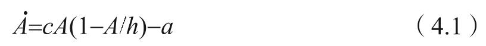

参数c将国家资源转化为它的地缘政治能力，参数h是权力投射的空间尺度，参数a是来自帝国之外边远地区的地缘政治压力（被假定为一个常数）。

模型2.12假设，政体的国力与其资源总量（cA）是成正比的。“资源”主要是指国家的人力资源，因为人口能够缴纳税收，而且可以提供领土防御和扩张必需的兵源。然而，正如我在前一章论述的那样，一个国家的成功是集体行动的结果。无论一个帝国拥有多少臣民，如果他们不能或不愿齐心协力，那么这个帝国的国力就是零。因此，系数c其实是代表集体团结的函数。

我们用S来代表整个政体范围内集体团结的平均水平。我将S的变化范围设定在0到1之间，其中0对应的是无法采取集体行动的完全原子化的社会，1对应的是人类能够达到的最大程度的团结。接下来，我设立了将国力乘数与群体感相关联的最简单的函数：c(S)=c<sub>0</sub>S。换言之，我认为地缘政治力量与群体感和国家资源的乘积成正比。在等式中代入这种关系之后，我们就得出了

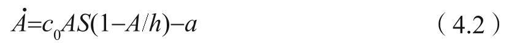

现在，我需要推导出S随时间变化的方程。第一步是为它选择一个增长规律。我们仍然缺乏一个完善的理论将微观层面的个体行为与宏观层面的群体感动态相互关联起来，因此，次佳方案是在简单的增长模型中进行选择，例如第2.1.1节和第2.1.2节中讨论的四种模型。两种无限制的增长模型（线性和指数）不适用于我们的研究目的，因为群体感不太可能无限增长，而且我已经将它的上限定为1。因此，真正可选的方案要么是渐进增长，要么是logistic增长。渐进增长意味着当S处于低位时（接近零），它将出现线性增长。这也不是一个很好的假设。正如第3.2.3节所说，大多数人都是有条件的利他主义者（如果他们是利他主义者的话）。当有条件的利他主义者占少数时，他们可能会采取利我策略，因为他们不希望被搭便车者利用。只有在其他（有条件的或无条件的）利他主义者的数量足够多的时候，他们才有可能表现出无私的一面。这个（粗略的）观点认为，群体感的最初增长应该是自动催化的。换言之，如果我们想从四种简单增长模型中选取一种，那与群体感增长的假定动态最匹配的就是logistic模型：

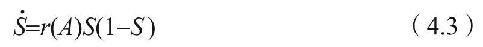

请注意，我已经将相对增长率r设为A的函数。确定此函数的具体形式将是我们的下一个任务。

在本章早些时候提出的描述性理论中，我指出，群体感理应在帝国边境周边出现增长，在帝国中心地带出现衰减。为简单起见，让我们假设，群体感的相对增长率与其距边界距离为线性函数关系（图4.1）。我们可以看到，这个空间分为三个区域：处于帝国疆域之外的“边远地区”，群体感趋于增长的“边境地区”，以及群体感趋于衰减的“中心地区”。参数r<sub>0</sub>是最大相对增长率，它出现在边界地带（x=A），b是边境地区的宽度［r（x）>0］。

整个政体范围内的平均群体感是

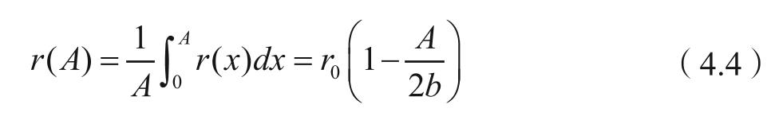

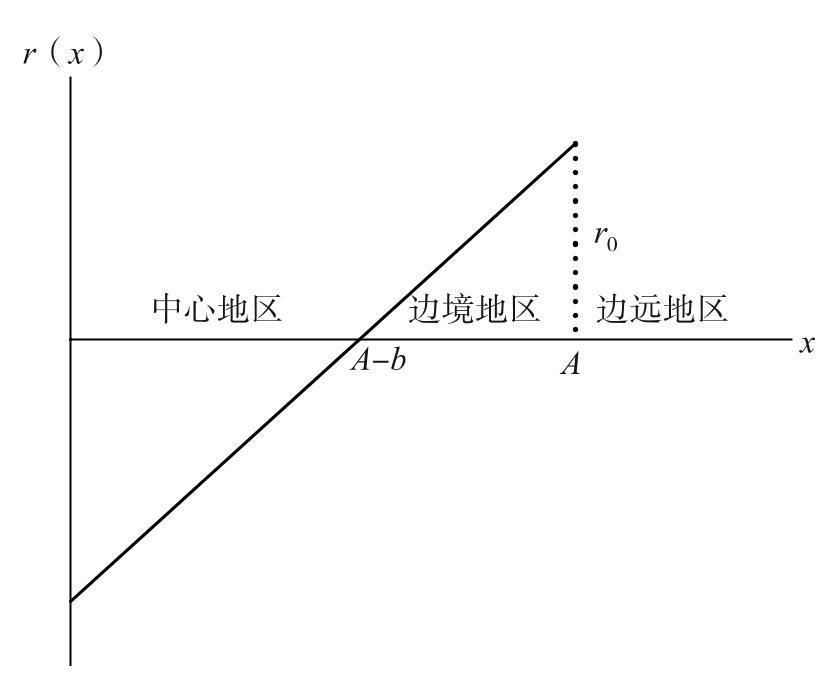

图4.1 群体感的相对增长率r（x）与帝国边界的关系

注：A为政体规模，b为边境地区的宽度（因此，“中心”从x=0延伸至x=A-b，而边境位于A-b和A之间），r<sub>0</sub>是群体感的最大相对增长率，出现在x=A的边界地带。

将这个算式代入的方程式，我们就得出了

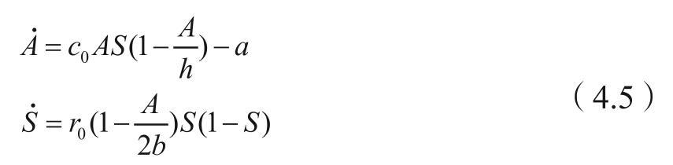

状态变量受到如下约束：0＜S＜1，A>0。

对这个简单模型的分析清晰明了，而且可以通过查看相空间中的等倾线，以图表方式完成分析。方程4.5中第一个等式的等倾线是显示A和S值所有组合的曲线，其中A的变化为零。等倾线的重要性在于它将相空间（它以图表方式呈现了A和S值的所有可能组合）划分为A增长或减少的区域（以及等倾线本身，此处=0，A不出现变化）。设=0，我们可以用类似方法定义第二个等式的等倾线。绘制出这两条等倾线（图4.2）之后，我们可以看到，它们只有一个相交点。换句话说，该模型有一个唯一的非均衡点。决定均衡是否稳定的是=0等倾线相对于=0等倾线最小值的位置。因此，均衡的稳定性仅由两个参数决定：h和b。如果2b>h/2（交点位于最小值的右侧），那么均衡的稳定性不会受到微小扰动的影响。该机制的运作原理如下。增加A的同时也会增加中心地区的面积，并导致平均群体感下降，这会推动帝国边界的收缩。另一方面，减少A会导致S增加，从而推动边界外扩。我要补充的一点是，除了均衡的动态变化之外，如果S和A的初始组合过低，那么政体也有可能走向失败。大致而言，如果A(0)S(0)＜a/c，那么这个新兴政体永远不会出现扩张，而且会被来自边远地区的压力摧毁。这并非群体感-疆域模型的新特征，而是原始地缘政治模型的一个特点（参见第2.2.1节）。实际上，2b>h/2的情况与没有群体感的地缘政治模型不存在本质上的区别。

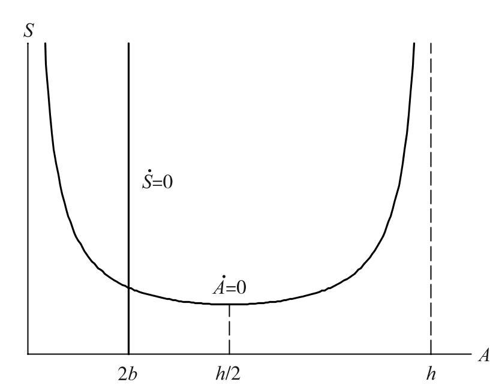

图4.2 群体感-疆域模型的等倾线（均衡不稳定时的情形）

如果2b＜h/2，那么均衡就是不稳定的。人口动态的特点是单个繁荣/萧条周期［假设初始国力A(0)S(0)位于阈值之上］。最初，A和S都会增加，但是当A超过2b时，S开始下降。领土扩张因帝国的后勤负荷限制而陷入停滞，同时S继续减少，因为帝国的中心区域左右了外围地区。走低的S最终意味着帝国无法应对来自边远地区的地缘政治压力。其结果就是A开始收缩，开始的时候速度比较缓慢，然后就越来越快。崩溃速度的加快是因为帝国在逐渐耗尽资源。到了某个时候，S开始再次增长（当A低于2b时），但为时已晚：正反馈动态（A减少—资源减少—A以更快的速度减少）压倒了S的任何增长，帝国也就崩溃瓦解（A变成0）。图4.3给出了此类动态的一个示例。

这一分析展现出了将描述性理论转化为数学模型的价值所在。虽然我们做了一些极度简化的假设，导致我们的模型充其量只能算是现实的缩影，但事实表明，模型能够呈现的行为要比我们事先预想的更复杂。最重要的是，虽然该模型证实了我们假定的机制可以导向帝国的繁荣/萧条周期，但它同时也表明，不同的参数值也可能会产生其他类型的动态。最重要的是，如果帝国的“势力范围”（量化为参数h）并不比边境宽度（b）大出太多，那么预期的繁荣/萧条周期将不会出现。相反，帝国将达到平衡状态（就像没有群体感动态的原始地缘政治模式那样）。此外，b必须远远小于h。虽然模型的结构设定（比如说，为各种函数所设定的线性关系）可能会影响精确的定量结果b＜h/4，但定性观察有可能是可靠的。相对于帝国规模来说，边境地区的面积必须很小，这是由后勤负荷约束决定的；若非如此，繁荣/萧条动态就不会出现。

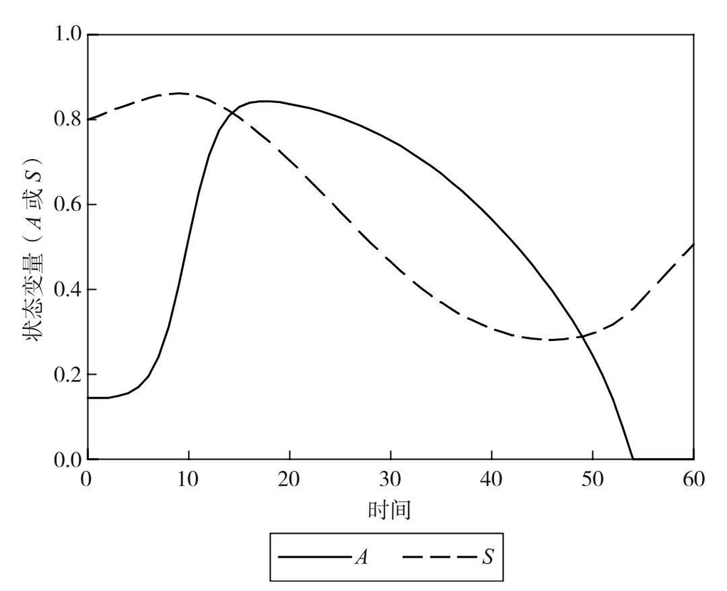

图4.3 不稳定均衡的动态模型（4.5）

注：参数值r<sub>0</sub>=0.1，c<sub>0</sub>=1，h=1，b=0.2，a=0.1。

另一个有趣的观察结论是，该模型似乎不生成反复的繁荣/萧条周期或持续的振荡。阻止帝国从崩溃中重生的关键因素是外部压力永远不会减少（常数a）。实际上，外部压力很可能来自那些自身存在后勤负荷约束的其他政体。因此，如果我们对对手国家明确建模，也许就会看到其他有可能出现的动态行为，但我们在此建立的简单模型无法生成这样的动态行动。我将在空间显式模拟的背景下继续探讨这一猜想（下一节）。

最后，将描述性理论转化为简单数学模型的另一个好处是，我们可以快速查看各种设定造成的影响。例如，在推导模型时，我设定的是群体感以logistic方式增长。如果使用其他增长模型，如渐进增长模型，又会有什么影响呢？事实证明，这一假定基本上不会影响定性结果。最重要的是，等倾线结构和带有后勤指数S的模型中的结构完全相同。<sup>[1]</sup>同样，将r（x）设为图4.1中的空间非线性函数也不影响等倾线结构。最后，谢尔盖·涅费多夫（Sergey Nefedov）（个人交流）研究了在推导A的等式时不使用exp[x]=1+x近似值的影响，他发现定性结果没有变化，但是繁荣/萧条循环的定量条件变成了2b＜h，而不是模型4.5中的2b＜h/2。因此，就我们所做的这些改动而言，模型得出的结论看起来相当可靠。

### 4.2.2 空间显式模拟

我们的下一步是让边境模型具有空间性，并确定这种变化如何影响预测到的动态。模拟模型的细节请见附录（第A.2节）。在此，我仅对模型做简要的整体描述并重点介绍它与非空间模型4.5的不同之处。最重要的添加值是明确的空间维度。模型中的基本空间单位（一个“单元”）对应于一个小的区域政体（酋邦）或大型领土帝国的一个省。这些单元被放置在一个矩形网格上。

我们在两个空间层面对群体感进行跟踪：每个单元都有一个群体感值，每个帝国也有自己的群体感值，这个值是帝国下属所有单元群体感的平均值。如果一个单元属于“边境”单元，也就是说，该单元位于两个帝国之间的边界附近，或者位于帝国与“帝国之外的边远地区”之间，那么这个单元的群体感将会出现logistic增长（上限S=1）。如果一个单元并不位于边境地区，那么它的群体感就会以指数方式下降至0。边境对群体感动态的影响在此与图4.1略有不同。首先，群体感的相对增长率并不是（像分析模型那样）随着它与边界的距离线性下降，而是呈Z字形：它在边境地区是扁平的正值，然后在内陆地区突然下降为扁平的负值。其次，边境地区的宽度b被固定成一个单元的大小。

模型所预测的动态

模型的动态是通过典型的实现法展示的（图4.4a）。模拟从位于模拟空间上部中心区域的1号帝国开始，其余的单元则被分配至帝国之外的边远地区。1号帝国快速增长了约10个时间步长，直至它占据可用空间的一半，随后因后勤供应限制而趋于稳定。在这个相对停滞的第一阶段，一个稳定的帝国边境被建立了起来，导致帝国外围边境地区的群体感开始增强。在20个时间步长之后不久突然出现了多条轨迹，这是因为边境地区的群体感增强到了小规模政权开始相互征战的地步。最初的这群政体中只有四个政体（2号、9号、11号和16号帝国）幸存下来，它们在成长过程中先是吞并了周边区域，然后又推动了1号帝国走向灭亡。在这个过程中，整个区域都被这四个帝国瓜分（没有留下任何帝国之外的边远地区）。第二段相对停滞的时期随之而来，然后9号和16号帝国突然强大并给另外两个帝国造成重创。不过2号和11号帝国并没有消亡。在第三个相对停滞的阶段，两大帝国的群体感出现衰减，而小型帝国的群体感开始增强。在这个阶段之后，又一个快速变化的时期导致了9号和16号帝国的崩溃，而2号和11号帝国又壮大起来并接管了它们的大多数领土。有意思的是，由于9号帝国崩溃，一部分区域变成了无主领土，这一地区没有被剩下的帝国所占领。一个新的帝国（17号）在这片无主领域上崛起，从而给第四个停滞时期画上了句号。这个帝国的崛起最终导致了一个较老帝国的覆灭，并在剩余两个政体之间造成了一段时间的动态反复。

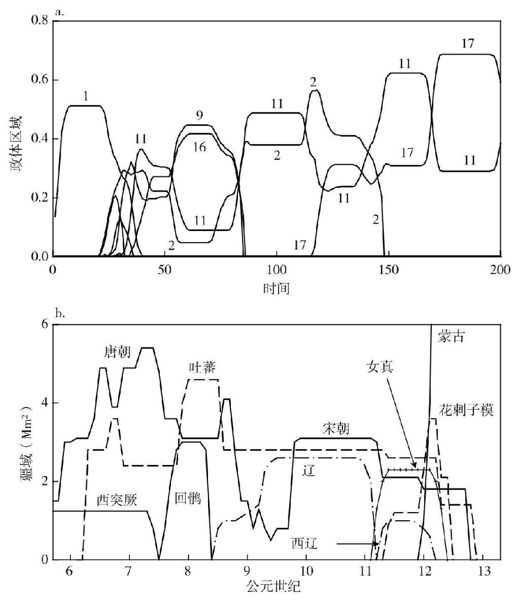

注：a图上每条曲线代表的是模拟帝国的疆域动态（政体区域被表示成总场地的一部分）。模型参数为r<sub>0</sub>=0.2，δ=0.1，h=2，S<sub>crit</sub>=0.003，∆<sub>P</sub>=0.1。每条轨迹所带的数字是政体的帝国编号。

资料来源：Taagepera（1997），附录。

模型生成的轨迹看起来与历史上的政体轨迹非常相似（与图4.4b相比）。一个惊人的相似之处是快速变化期之后出现相对停滞期的模式。另一个相似之处是政体动态对形势的依赖。特别需要指出的是，虽然所有帝国都同样受到后勤负荷的限制，但每个停滞期的最大准静止区域有很大的差异。这种差异的首要原因是历史导致不同比例的高群体感单元在帝国层面生成了不同的平均群体感。其次，由于边境地区的地理位置反映了相邻政体对立力量的平衡，因此帝国的最终规模很大程度上取决于邻国的相对实力。

模型动态的轨迹不稳定性

该模型的特点之一是它的结果看起来很不稳定。事实上，如果我们以完全相同的初始条件（即1号帝国的初始位置和群体感）重复模拟，那每一次运行都会产生截然不同的结果。由于变化规则基本都是不变的（模型中唯一存在随机性的地方是单元成为潜在攻击者的顺序以及相邻单元受到攻击的顺序），因此这一观察结果表明该模型运行的时候并没有规律性。为了核实这一点，我（通过设定攻击者的顺序和攻击方向）从模拟中删除了所有随机性。这种具有完全确定性的模型仍会产生极不稳定的轨迹（当然，现在每次运行都与前一次完全相同）。然而，初始条件的一个微小变化（比如说，在1号帝国的初始状态添加或去掉某一个单元）将会再次生成快速发散的轨迹。因此，看起来该模拟的特点确实就是混沌动态（也就是说，对初始条件具有敏感依赖性；Ruelle，1989）。

现在回想起来，在元种族边境空间模型中看到混沌动态并不是一件令人惊讶的事情。动态系统中的非线性和高维性促成了复杂动态。边境模型的一些特性引入了严格的非线性。一个是面积阈值效应（参见第4.2.1节）：小型政体很容易灭亡，但是一旦它们的面积超出一定的规模，那么它们对外部压力的抵御能力就会增强很多。第二个阈值是S<sub>crit</sub>，即平均群体感的临界值，如果低于该值，帝国就无法维持其凝聚力。还有一个重要因素，那就是群体感方程背后的logistic增长假设。状态变量处于低值时的logistic增长基本上是指数型增长，因此其特点是敏感依赖性。这意味着位于同一边境地区内的两个（因历史影响而）初始群体感略有不同的单元实际上会在群体感值上出现越来越大的差异，即使它们受制于完全相同的动态规则。

动态的高维性是由空间造成的。每个单元的特征是两个状态变量：帝国指数和群体感。因此，动态过程的维度是场内单元数的两倍（比如说，对于20×20的场地来说，维度就是800）。这意味着，在任一特定时间都有数个帝国在争夺领土，而且每个帝国的内部构成都有高度的背景性和历史性。上文已经阐述过这种情境依赖性。

总之，由于模拟的空间性质，非线性函数形式和高维性共同导致了动态的高度混沌性。如果边境模型确实刻画到了现实情况的一些重要角度，那么长期预测农业政体轨迹的前景并不乐观。确实，空间边境模型非常简单，甚至过于简单，但是更复杂的模型通常会产生更加混沌的动态。

后勤负荷参数对稳定性的影响

对非空间边境模型的分析表明，确定该模型稳定性的关键因素是h/b比（根据边界宽度b来加大力量投放的空间尺度，由此导致的结果是政体均衡规模的不稳定）。在空间模拟中，边境宽度固定为1，但我们可以调整h值并观察我们预测的动态受到的影响。非空间模型显示，降低h最终应该会让动态稳定下来，而提高h则会进一步破坏动态稳定性。空间模拟的数值探测表明情况确实如此。当h减小时，比如说减小到1（与参考值2相比），模拟结果就不再生成振荡。相反，在经过一些瞬时动态之后，出现了很多中等规模的政体，每个政体占总面积的7%到16%不等（30~70个单元）。

根据非空间模型的预测，提高h值会破坏动态的稳定性。比如说，如果我们设置h=3，那么，在经过一些初始振荡之后，有一个政体最终将会接管整个模拟区域。由于缺少边境，所有单元的群体感最终都会下降至0。当帝国平均群体感降至S<sub>crit</sub>阈值以下时，帝国就会分崩离析，但是由于它在各地是同步瓦解的，因此没有出现新的边界，所以这个系统将永远处于无国家状态。

反流（reflux）和突破效应

空间模拟预测的另一种模式值得我们在此展开讨论。在研究模拟结果的空间动态时，我注意到，在边境区崛起的挑战者帝国最初倾向于从旧帝国向外扩展至边远地区，甚至会消灭周边较小的其他挑战者（图4.5）。

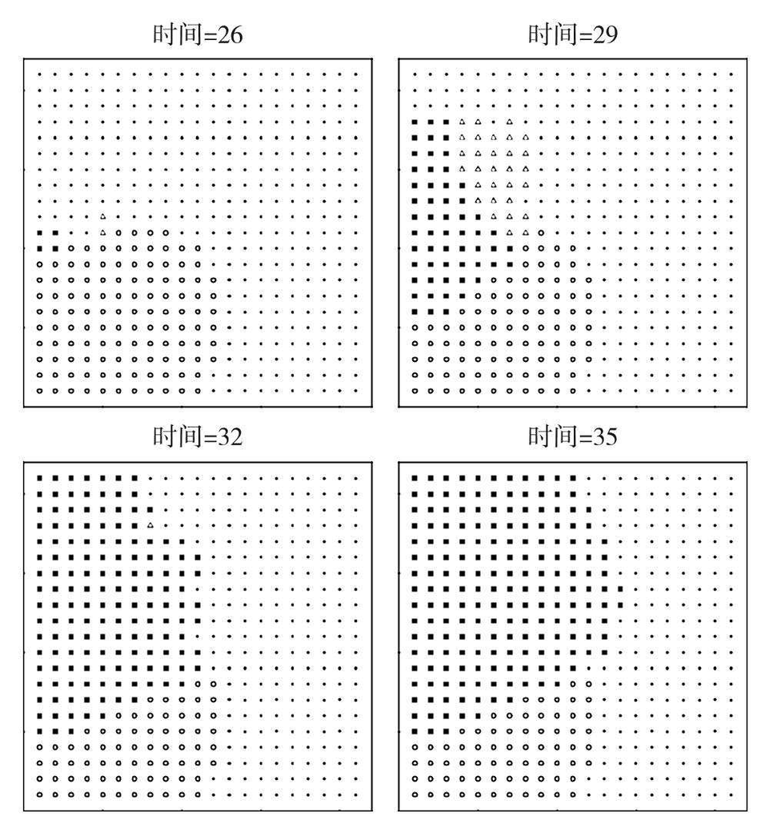

图4.5 空间边境模型中的反流效应

注：在这四张图片中，黑点代表边远地区，圆圈代表1号帝国治下区域，正方形代表2号帝国治下区域，三角形代表3号帝国治下区域。在第一张图中（时间=26），2号帝国和3号帝国刚刚出现在1号帝国的边境地区。在时间=29的时候，两个新帝国都扩张到了边远地区。随后，2号帝国征服了3号帝国，并扩张至后勤限制造成的极限（时间=35）。

现在回想起来，一切都一目了然。挑战者政体通常都无法成功进攻旧帝国，因为帝国疆域辽阔，而且平均群体感还没有下降到不堪一击的水平，因此仍然非常强大。与此同时，非边境边远地区的群体感很低，很容易向此扩张。此外，随着挑战者帝国扩张到边远地区，它的重心也远离了旧帝国，因此它对旧帝国施加的压力会随着时间的推移减弱。在边远地区的进一步扩张只会因为后勤限制（或是因为抵达模拟区域的边缘）而停止。我将这种从边境区域向外推进的扩张模式称为反流效应。

在某些条件下，反流现象不会出现。具体而言，出现这种情况的原因是挑战者出现在博弈后期，这时旧帝国的平均群体感已经低到无法抵御来自挑战者的压力。在这种情况下，我们经常会观察到“突破”效应：一个漫长的准静止期，在此期间，旧帝国的群体感正在缓慢衰减，而挑战者政体的群体感则在增强。然后，突然之间，两个对手的力量悬殊超过了阈值∆<sub>P</sub>，挑战者占领了旧帝国的边界单元。这对旧帝国的平均群体感造成了灾难性打击（因为仅有边境单元的群体感仍然处于高位），也让挑战者迅速扩张到旧帝国的内部区域（通常也会促成旧帝国的灭亡，如果它的平均群体感在边境地区被占领之后降至S<sub>crit</sub>阈值以下的话）。

对空间模拟所预测的动态来说，反流效应是一个极为典型的特征。它也是一个现象特征，因为它不是在微观层面上构建的。模型的这一惊人预测为我们提供了一种对之检验的方法，那就是查看历史记录，看看是否存在反流现象。

特别说明

最后，我需要谈一谈边境模型的局限性以及我们可以如何调整模型来解决这些问题。首先，模拟使用了最简单的方法来模拟距离效应，即假设帝国对其边境上某一特定单元的影响力会随着该单元与帝国中心距离的加大呈指数级下降。还有一些更机械式的假设值得探索。比如说，可以显式模拟军队的移动、位置和供应。这种方法将对帝国的扩张能力形成更切合实际的约束（在当前的模拟中，帝国原则上可以同时向所有方向扩张）。另一个重要的地缘政治因素是山脉和水域等限制活动的障碍。对这些因素的研究将会非常重要，但远远超出本书的内容，因此只能留待日后再论。

该模拟对现实过度简化的第二个方面体现在它没有关注各政体居住人口的民族动态。相反，该模拟将民族等同于政体的成员身份。这样的话就等于假定所有的帝国边界都代表着元民族分界线。该模拟又假定，一旦某个单元被占领，其居民立即会转为忠于征服它们的帝国（或者说，立即被替换成殖民者）。这是一个非常严重的缺陷，因为民族同化等民族运动（ethnokinetic）过程显然需要时间。第6章将会着手处理这一问题。

该理论还需进一步完善的第三大领域是不同社会阶层的动态（对我们的研究目的来说，最重要的是平民和精英），包括他们的人口动态以及向上和向下的流动性。这也是一个严重的缺漏，因为将政体的不同阶层联系在一起的集体团结程度本身就是一个重要的变量。此外，人口动态是国家经济实力的重要决定因素。第7章会提出一些初步的步骤以构建旨在解决此类问题的理论。

[1] 对于擅长数学的读者来说，请记住我加上了0＜S＜1的条件，所以我们不关心S=0的等倾线。

## 4.3 总结

●本章的主要目的是将群体感概念内生化。这意味着我们需要构建一个理论并设立导致群体感增强或消减的变量。

●我们通过多层选择理论来获取相关理论知识，了解哪些条件有利于集体团结的演化。多层选择理论指出，当群内差异达到最小化而群际差异达到最大化的时候，就会促进群体成员选择有利于群体但有损个人利益的行为。这个论点表明至少有三个变量会影响到群体感的演化。

●第一个变量是群体环境的安定程度。由于群际差异的主要起源是群体之间的冲突，因此无国家环境下的地理位置会促进群体感的增强，而靠近大型政体中心的地理位置（这里远离边界，即战争的主要发生地）则会造成群体感的衰减。

●第二个变量是人口相对于承载能力的密度。逼近生存极限的人口密度将会推动群内竞争并造成群体感的下降。低人口密度则意味着较少的群内竞争以及有利于群体感增强的条件。请注意，这个变量与第一个变量是相关的，因为无国家环境下的死亡率往往高于大型政体的中心区域，从而导致人口密度大大低于承载能力。

●前两个变量影响的主要是有利于小型族群群体感增强的条件。第三个变量，即靠近主要元民族断层线的地理位置，则为群体感的规模扩展创造了条件。其一般机制是具有象征性的民族边境向外扩展并涵盖一个更大规模的群体，与位于元民族断层线另一侧的（一个或多个）另类群体相对立。

●元民族断层线有可能与帝国边界重合，形成我所说的元民族边境区。在元民族边境区，上述三个因素（群际冲突、人口密度和深度种族差异）会协同发挥作用。因此，本章提出的理论给出了这样的预测：元民族边境区域是群体感的“熔炉”。

●最有利于群体感增强的条件应该是大型帝国的边境区域，如果这个帝国同时也是一个普世宗教的载体并邻接无国家边远地区的话，情况就更是如此。帝国边境区域可以对部落区域形成“推力”或“拉力”（或两者兼有）。当帝国充满活力时，它们会对居住在边远地区的族群形成扩张压力。当帝国式微时，丰盛的战利品会对边境部落形成诱惑。在任何一种情况下，生活在帝国边境的“野蛮人”都有额外的动力来形成更强大的集体行动能力。

●还有一种情况应当也有助于群体感的增强，那就是信奉不同排他性宗教（如基督教和伊斯兰教）的两大帝国之间的边境地区。在这种情况下，面临压力而必须提高并扩展群体感的是居住在帝国边境地区的群体。

●在元民族边境区域，群体面临着巨大压力，这里是民族灭绝、文化灭绝和种族屠杀频发的地带，也是族群形成的高发地带。在激烈的群际竞争中，一个群体感处于高位、结构利于扩张而且运气上佳的群体最终胜出。在这个过程中，这个群体形成了自己的独立身份、强有力的民族界限和高度的内部凝聚力，换言之，它成为一个新的族群（初期的民族）。因此，导致这个新的民族政治体系形成的过程可以被视为族群形成过程。请注意，该理论将政体形成和族群形成视为同一动态过程的两个方面。

●在将这种描述性理论转化成一个简单的分析模型后，我们发现，政体规模和群体感的动态应该会经历一个单一的繁荣-萧条周期。然而，只有在边境区域的面积远远小于后勤限制所设定的政体规模上限的时候，这种动态才会出现。如果违反这一条件，那么政体动态与2.2.1节中的简单地缘政治模型就不再有本质上的区别。

●为了验证分析结果，我构建了一个世界政体体系的空间显式模拟，推动该体系疆域动态的是地缘政治力量和群体感。群体感在边境地区会增强，而在中心地带则会减退。模拟表明，使用不同的参数之后，政体会经历反复的繁荣-萧条振荡。然而，这些振荡不是循环的，而是高度混沌的。

●政体存在过程的关键时期之一就是它的起源期。其核心民族的群体感必须以某种方式增长到超出周边族群的水平，从而让核心群体向外扩张。增强一个群体的群体感并让它投身于政体建设和扩张进程的过程就是族群形成过程。

# 第5章 对元民族边境理论的实证检验

## 5.1 设置检验

第4章中所提理论的预测认为，大型领土帝国应当崛起于元民族边境区域。本章的目标是对这一预测进行实证检验。这一理论具有普遍性，因为它的预测适用于全球所有地方的所有农业政体。然而，由于我掌握的资源有限，无法一次涵盖所有已知历史的检验，因此有必要选择一个离散区域和周期以迈出第一步。我选择重点研究公元后两千年里的欧洲，因为这一时空领域内的历史是为人熟知的（而且在西方语言写成的文献中很容易查询）。

将欧洲设为一般理论的试验平台有一个缺点，那就是，欧洲可能有很多不同于世界其他地区的特征，即那些导致它在近代崛起的独有特征（如Jones，1981；Landes，1998）。然而，基于这种“欧洲例外论”的对欧洲崛起的解释已经受到严厉的批评（Blaut，1993，2000）。此外，当前的学术研究（对之进行概括的有Frank，1998；Pomeranz，2000）表明，欧洲仅在1800年之后才开始与世界其他地区分道扬镳。不管怎样，我都没有必要在这场论战中选边站。我此时的工作假设（working assumption）是，元民族边境理论同样适用于欧洲和世界其他地区。在此我将阐述根据欧洲素材得出的理论检验结果，而对中/东亚、南亚和西南亚地区的理论检验将放在日后的出版物中（相关研究正在进行之中）。换言之，我将之视为一个实证问题。用查尔斯·蒂利的话来说，“虽然欧洲的历史经验有其自身特点，但这段历史足够漫长，有足够丰富的文献记载并对世界其他地区产生了极大的影响，因此任何系统性结论只要在这段历史下能够站得住脚，那它基本上就是一个可以在其他地方经受检验的合理假说”（Tilly，1975，第13页）。

从地理位置看，欧洲是欧亚大陆西部的一个半岛，因此它与旧世界其他地区的界限比较随意。我采用的是欧洲和亚洲之间的标准地理边界（乌拉尔山脉、乌拉尔河、里海、大高加索山脉、黑海），但有两处例外。我将略去北高加索地区，因为人们对它在这一时期中大部分时间的历史所知甚少。不过，我将安纳托利亚半岛（小亚细亚）包括在内，因为如果将它排除在外的话，我就不得不把几个重要的欧洲大国（拜占庭帝国和奥斯曼帝国）视为外生干扰。还有一个区域也很难划出明确的边界，那就是伊比利亚-摩洛哥的交界处。我选择了将摩洛哥政体［最著名的是阿尔摩拉维德（Almoravids）和阿尔莫哈德（Almohads）］视为外生干扰。

我的研究重点是农业政体，因此我选取的时间截点是公元1900年。虽然此时欧洲西北部的一些国家已经实现了农业向工业转型，但这种发展只影响到了这一时空领域的一小部分。我选择将公元500年设为政体动态研究的起点，这个时间点与西罗马帝国的衰落大致吻合。由于边境对民族政治动态的影响存在长期滞后，所以我的边境数据库开始于公元0年。我承认，我选择的空间和时间界限有一定的随意性，也就是说，我也可以做出其他选择。但我认为，此时的重要原则是位于这一特定时空范围的所有地区和所有政体都应该被用于实证检验。这样的话，就不能批评说检验结果出自有意识或无意识的选择偏差。至于选择什么样的时空界限，它们只需要包含足够数量的地区和政体以便我们进行统计就可以了。

### 5.1.1 对边境进行量化

无论是就时间而言还是就空间而言，边境都是难以明确敲定的对象（Hall，2000）。它们游移不定，而且空间边界模糊不清。然而，为了设计出一个统计检验，我们必须将它们离散化。第一步是将空间划分为离散的地理单位。我将总面积划分为约50个10至20万平方千米的“文化区域”（图5.1）。在绘制地理单位之间的边界时，我尝试将重要的固定地形特征（山脉、海岸线）和民族界限（语言、宗教）纳入考量。除了空间划分之外，我还需要进行时间划分。因为我们处理的是非常缓慢的过程，所以我以世纪为单位对时间进行划分。

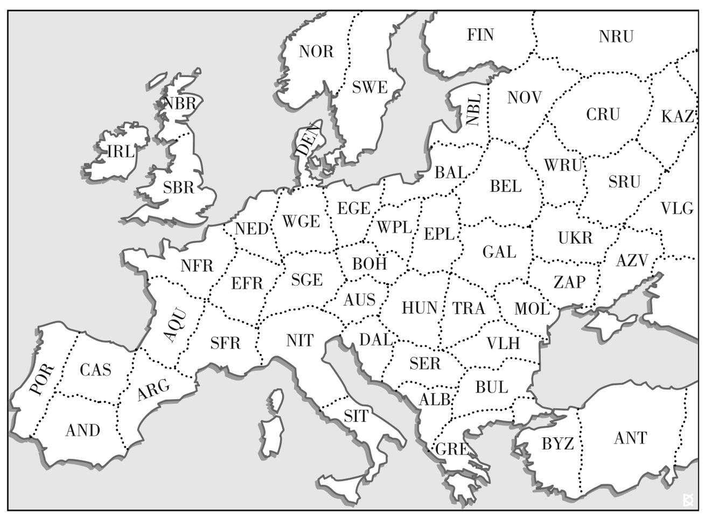

图5.1 在对元种族边境和政体规模之间的关系进行统计分析时被用作地理单位的文化区域

注：图中英文缩写释义参见本书附录B。

我要再次重申的是，任何想要将时间上动态变化和空间上模糊的事物（如边界）转化为离散的时空单位的方案多少都必须强求一致。我相信肯定还会有比这更好的方案。然而，我们总得找个地方着手展开研究。我在这样做的同时，也希望这个方法在以后能够得到改进，或是有更好的可选方案被提出来。

50多个文化区域和19个世纪构成了将近一千个地区-世纪单位，这也是我对公元0—1900年欧洲边界变化进行分析时使用的主要数据单位。下一步是为每个单位分配一个定量分值来反映该单位内部跨民族互动的强度。在此我假定互动强度有四个组成部分，分别是宗教差异、语言差异、生活方式差异和战争压力差异。我将宗教差异的分值分为四个等级：

●最高分3分给予伊斯兰教与基督教相互碰撞或它们与异教相碰撞的地区。

●下一等级的得分是2分，给予基督教或伊斯兰教内部的主要宗教分裂（例如，公元1000年之后的天主教与东正教；什叶派与逊尼派）。

●同一宗教中的宗派被评为1分。具体实例有天主教徒与新教徒或者公元1000年之前的拉丁与希腊基督徒。我也将各种异教之间的差异定在这个等级，因为这些宗教与基督教和伊斯兰教不同，它们往往不具有排他性并要求皈依。

●最后，如果没有任何宗教差异的话，则被评为0分。

语言差异的评分是0分（无差异）、1分（同一语言族群下的不同语言：罗曼语、日耳曼语和斯拉夫语）和2分（不同的语言族群）。我没有给不同的语系［印-欧语系、乌戈尔-芬兰语系等］再加1分，因为在我看来，一旦不同语言的差别大到完全无法相互理解的程度（当两种语言属于不同的语言族群时肯定会出现这种情况），说话者将无从得知他们属于同一个语系。如果说话者所持语言属于确切相关的语言（如加泰罗尼亚语和卡斯蒂利亚语或奥克西坦语和法语），我将之定为中间分值1分，具体理由如下。首先，一个讲北部法语（langue d’oïl）的人会将奥克西坦语视为一种与自己相关的语言，并有可能觉得，比起说日耳曼语的人，自己和说奥克西坦语的人更亲近。其次，从历史上来看，属于同一语言族群的语言之间通常逐渐变化而不是突然发生变化。因此，很难在中世纪划出明确的界限区分说罗曼语的人和其他人。对日耳曼语言和方言同时存在的地区来说，或是对包含了东斯拉夫语言和西斯拉夫语言的地区来说，情况也是如此。

经济生活方式的最大差异（分值为2）存在于定居的农民和游牧的牧民之间。这种划分代表了一整套文化差异，包括迥异的行为规范以及对待彼此的态度。分值1将（至少在某些社会阶层中）拥有城市文化背景和读写能力的农业从业者与“偏远地带”的耕种者区分开来。

最后，战争强度指数代表了跨越元民族分界线的战争对人口的影响。最高值2分代表的是激烈的战争，这样的战争会导致相关地区的人口出现明显的减少。1分代表以战利品和俘虏为目标的持续侵扰，这种侵扰不会导致人口数量显著下降。最后，0分对应的或是相对和平的互动，或是精英发动的“轻度”战争，这些不会影响到生产阶层的人口。

边境强度的总分是对宗教、语言、生活方式和战争强度指数的得分进行加总之后得出的。它的分值范围为0到9分。请注意，由于宗教比其他指数多出了一个强度等级，因此这种方法使宗教在最终得分中有更大的权重。鉴于宗教在建立和维持元民族界限方面的重要作用，我认为这种做法是合适的。

附录B给出了如何将历史信息转换为边境得分的具体细节。简而言之，我查阅了每个文化区域的历史，并确定了在给定时间点这个区域是否有国家边界贯穿其中或者位于其周边。如果该区域位于一个大型帝国的内部，则其边境指数为0。同样，如果一个区域处于无国家环境（即酋邦和较小规模的政体），则该区域的指数也为0。如果一个区域位于国家边界之上，那么我会如上所述对民族互动强度的四个构成因素进行评分，并将它们相加得出边境总分值。如果有两个或更多边界穿过同一区域，我就给它打上最高分值（根据设定，边境强度不会叠加）。

### 5.1.2 政体面积

在我设置的检验中，边境强度是（预测性）自变量。对于（响应性）因变量，我们需要一些标准来衡量帝国的成功程度。如第1.2.1节所述，一个适当的衡量标准就是政体的疆域范围。因此，我将帝国的成功程度量化为帝国巅峰时期治下领土的最大值。这种衡量办法的一个缺点是，它没有区分快速达到巅峰又快速衰落的帝国和更加持久的政体。很显然，持续周期更长的政体可能拥有更高程度的群体感，因为存活了多个世纪意味着这个政体已经遇到并克服了诸多挑战。相比之下，一个昙花一现的帝国可能只是运气不错，刚好赶上其竞争对手暂时性的式微而已。要想区分这两种情况，一个方法就是将政体持续时长加入量度之中。比如说，我们可以合并政体领土曲线之下的区域。我打算日后再深入研究这一想法（这项工作正在进行之中），但现在我将采用较为简单的以最大领土面积为基础的衡量标准。

元民族边境模型预测的是大型领土政体会在哪些地方崛起。当然，大型政体与其他政权之间的区别是比较随意的，但我需要一些分界点，这样就无须处理数不清的小型政体，如近代早期欧洲的较小帝国。我将阈值设置为0.1Mm<sup>2</sup>（1Mm=1000km；因此1Mm<sup>2</sup>=10<sup>6</sup>km<sup>2</sup>），这与图5.1中较小尺寸地理单位的面积相当。换句话说，我不打算关注那些面积不到一个地理单位的政体。

除了政体面积分界点之外，我还需要一个边境累积张力的分界点。毕竟，该理论并没有预测任何国家边境都可以推动群体感的生成。这样的边境必须是充满张力的，而且对周边区域有着长时间的影响。第二个属性很重要，因为群体感是在漫长的时期里逐步增强的。因此，如果某一地区的边境只是昙花一现，那它不太可能引起任何族群形成。更有可能的是，该地区将被纳入不断向外扩张的帝国，随着边境向外推移，作用于该地区人口的力量将造成群体感的下降，而不是上升。为了将这两个属性结合到一起，我设置的要求是，如果想将边境分类为“群体感生成器”（asabiya generator），它的张力需要达到5分或更高（注意，5是边境张力尺度的中间值），而且需要在给定文化区域存在了三个世纪或更久。

我们现在可以从检验的角度具体讨论该理论生成的预测。边境张力强度为5分或更高并持续三个世纪或更久的文化区域预计将成为最大面积大于0.1Mm<sup>2</sup>的领土政体的源头。我所说的“源头”指的是大型政体的起源地，这里居住着政体的核心精英，通常也是首都所在地。我们在检验这一预测时，可以将双向表中的所有单位分类为（1）有或没有元民族边境以及（2）有或没有后期面积超过0.1Mm<sup>2</sup>的政体（下文将会具体说明）。该理论预测，“无边境、无帝国”单元和“有边境、有帝国”单元的案例应该多于随机预期。“有边境、无帝国”预计也会出现一些案例。正如第4.2.2节的模型预测的那样，出现这种情况的最常见原因是，同样位于边境地带的周边其他某一地区可能率先建立起帝国并在我们所观察的目标地区建立起帝国之前将其占领。另一个潜在的原因是，在现实世界中，群体感增强并促成一个强势帝国的建立一定是一个随机过程，因此可变时段可能在这个过程完成之前就已经过去了。不过，根据这一理论，如果一个地区长时间位于边境而没有被另一个帝国占领，同时也没有建立起自己的帝国，那么它将属于一个异常现象。

然而，“无边境、有帝国”类别中的案例对这一理论构成了最大的实证挑战，因为根据该理论，应该不会观察得到这样的现象。借用拉卡托斯（Lakatosian）的观点，我们将此类现象视为异常现象。如果观测到太多异常现象，那么这一理论就不再站得住脚，尤其是如果能有一种可选理论可以更好地解释观测结果的话。异常现象的价值就在于它们时常能够提示我们如何构建可选理论。

## 5.2 结果

接下来我会分两步介绍一下检验结果，第一步是公元后第一个千年里的欧洲，第二步是公元1900年之前的欧洲。分析过程的中间步骤描述和数据表见附录B。

### 5.2.1 公元0—1000年的欧洲

在这一千年里的前半段，主导欧洲政治地理的是罗马帝国。尽管有一些振荡，但罗马帝国的边境基本上是稳定的。罗马帝国的边境曾经向日耳曼尼亚（Germania）、布里塔尼亚（Brittania）和达西亚（Dacia）推进过，但都没有维持太长时间。在灾难性的第三个世纪里，边境不断遭受野蛮入侵。但是，总的来说，边境地区所影响的大致就是从现今的荷兰到罗马尼亚的那片东南走向的区域。在公元0—500年期间被划分为“边境”的有SBR、NED、NFR、EFR、WGE、SGE、BOH、AUS、HUN、TRA、VLH、BUL、BYZ、MOL和ZAP（见图5.1）。

这一期间的单一帝国使得统计检验的构建变得简单明了。我只需查看前500年的边境数据并观察是否有大型政体起源于这些地区并在后500年（公元500—1000年）扩张到最大规模。这一时间划分是由因果关系决定的（边境必须在时间上先于帝国出现）。公元500年这个分界日期非常方便，因为它接近于西罗马帝国崩溃的日期。表5.1汇总了检验结果。

表5.1中记录的总体模式证实了元民族边境理论的预测：绝大多数案例都集中位于“无边境、无帝国”和“有边境、有帝国”的类别之中。统计检验表明，这种结果属于偶发性的可能性小到接近于零。现在我们已经对模式有了一个整体印象，下面让我们深入研究其中一些具体细节。

表5.1 边境模型的实证检验结果

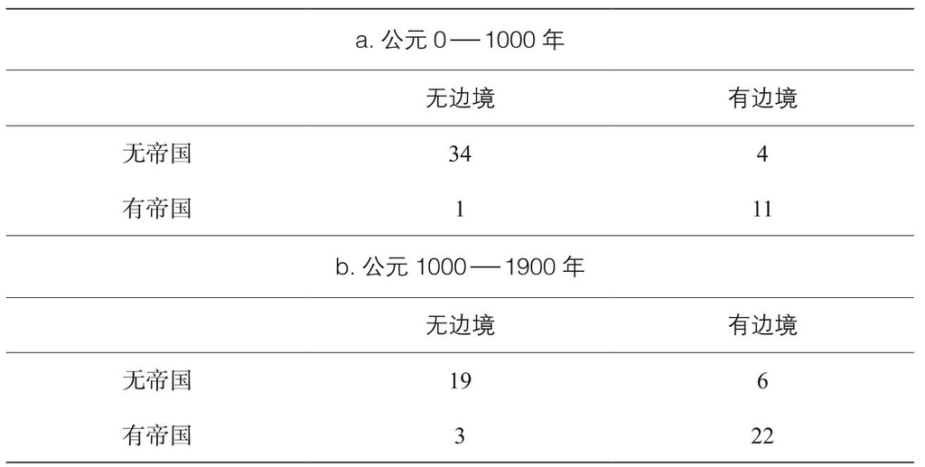

注：a.公元0—1000年的欧洲。独立性检验（Sokal and Rohlf，1981，第737页）：G<sub>adj</sub>=27.1，P≪0.001。b.公元1000—1900年的欧洲。独立性检验：G<sub>adj</sub>=22.0，P≪0.001。

第一个千年里欧洲民族政治史的简要概况

欧洲的罗马边境分为三个截然不同的部分：两个部分位于平地，中间被崎岖地带隔开。第一段平地沿着汝拉山脉（Jura）以北的莱茵河和孚日山脉（Vosges）延伸并穿过北欧平原（我将在第9.1.1节再次谈到这一区域）。崎岖地带位于阿尔卑斯山以北。阿尔卑斯山山麓以及汝拉山脉、巴伐利亚/波希米亚森林、苏台德山脉（Sudetes）和塔特拉山脉（Tatras）等较小的山脉和丘陵横贯其中。另一段平坦地带沿着多瑙河延伸，它是由两部分组成的：匈牙利平原和特兰西瓦尼亚阿尔卑斯山脉（Transylvanian Alps）之外的瓦拉几亚（Wallachian）平原。瓦拉几亚平原顺利融入黑海沿岸低地，从君士坦丁堡（今伊斯坦布尔）延伸至第聂伯河乃至更远（第9.2.1节将谈到后一片区域）。这一部分边境，包括匈牙利平原，都可以被视为欧亚大草原的西部延伸。

我在第4.1.2节中提出了一个假说，那就是崎岖地形会抑制群体感的增强。因此，我们可以预期大型政体会形成于罗马边境的平坦地带。事实也正是如此。第一个千年里最大的欧洲政体（完整的政体清单请见附录）是法兰克帝国（Frankish Empire），其疆域在查理大帝统治期间达到了近1.8Mm<sup>2</sup>的峰值。形成于同一片地区但规模较小的日耳曼国家和酋邦，包括勃艮第王国（Burgundian Kingdom）以及阿拉曼（Alamanni）公国、图林根（Thuringian）公国和撒克逊（Saxon）公国。英吉利海峡对岸也是同样的情形，只不过规模较小而已，韦塞克斯（Wessex）、默西亚（Mercia）和诺森布里亚（Northumbria）最终也与英格兰融为一体。

欧洲（或者更确切地说，欧亚大陆西部）第一个千年里的第二大帝国是拜占庭（在公元970年的时候面积为1Mm<sup>2</sup>）。拜占庭帝国给我们提出了一个令人着迷的历史难题，那就是：为什么东罗马帝国在西罗马帝国崩溃后幸存下来又继续繁盛了一千年？元民族边境理论给出了解决这个难题的方法。拜占庭-君士坦丁堡周围的区域从第3个世纪开始成为帝国边境并持续至第10个世纪。一旦来自北方的入侵者穿过多瑙河，它与君士坦丁堡之间就不再有重要的地理屏障。此外，君士坦丁堡周围的区域很容易受到海上袭击。其结果就是它不断地受到袭击和入侵，野蛮的哥特人、匈奴人、斯拉夫人、阿瓦尔人、保加尔人和阿拉伯人的轮番上场让君士坦丁堡应接不暇。此外，从第4个世纪开始，直到保加尔人在公元863—900年改变宗教信仰为止，东罗马帝国的边境一直与基督教和异教徒之间的元民族断层线相吻合。

我在第4章说过，一个新的帝国既可以诞生于旧帝国边境的帝国一侧，也可以诞生于部落一侧。在多瑙河下游边境，两侧都诞生了新的帝国。讲突厥语的游牧民族和讲斯拉夫语的农民在边境以北合并成了一个新的保加尔族群，而另一个新的族群，拜占庭人，则诞生在边境以南。我认为，我们有非常有力的理由将拜占庭人视为一个新族群。很显然，拜占庭人在语言和宗教上都不同于古典时代的罗马人，而文化上的改变还要更加深刻，比如从希腊文化的自然主义和理性主义突然转变为第五世纪和第六世纪的超验主义和神秘主义（McNeill，1963，第451页）。当然，拜占庭人仍将自己称为“罗马人”，但其他很多人也这么称呼自己——从“德意志民族神圣罗马帝国”到现代罗马尼亚人和（吉卜赛）罗马人，甚至还有罗姆塞尔柱人（Rum Seljuks）。请注意，我并不是说这样的族群转变是在一夜之间发生的，甚至都不是说它在一个世纪之间发生。东罗马帝国至少在500年的时间里一直承受着来自北方蛮族和东方穆斯林的极大压力。但拜占庭人幸存下来，当压力在9世纪中叶有所减弱时，他们开始了持续的领土扩张（Whittow，1996；Treadgold，1997）。

现在我已经介绍了前罗马边境上形成的政体。不过，这一特定时期有一个特征，那就是，有很多政体的族群形成位置与政体最终建立的位置相距甚远。西哥特人和东哥特人起源于黑海北部，但分别在伊比利亚和亚平宁半岛建立了国家。伦巴第人最初聚结于潘诺尼亚（HUN），但最后在意大利北部建立了一个国家。事实上，匈牙利平原见证了令人眼花缭乱的民族更替：罗马征服之前的达契亚人，然后是匈奴人、格皮德人（Gepids）和伦巴第人、阿瓦尔人，最后是马扎尔人（Magyars）。民族更迭之所以如此快速，最有可能的原因是地处欧亚大草原西端的位置使这片平原成为入侵游牧民族的最后一站。

不符合元民族理论预测的案例

有四个地区属于“有边境、无帝国”的范畴，每一个都是因为它们并入了邻近地区的一个帝国之中。NFR和AUS并入了法兰克帝国，TRA是阿瓦尔汗国的一部分，BUL是保加利亚汗国（Bulgarian Khanate）（其中心最初位于VLH，后来向南移至BUL）的一个组成部分。此外，AUS相对于周边地区来说处境不利，因为它坐落于罗马边境的崎岖地段（阿尔卑斯山脉贯穿其中）。

“无边境、有帝国”类别中的唯一案例是阿基坦公国（Duchy of Aquitaine）。如前一节所述，从边境模型的角度看，属于此类别的所有实例都被视为异常现象。然而，阿基坦公国并没有对这个理论构成严重挑战。这个政体是在法兰克帝国墨洛温王朝（Merovingian Frankish Empire）瓦解之后形成的，可以被视为旧帝国的残余物［还有纽斯特里亚（Neustria）和奥斯特拉西亚（Austrasia）］。它在8世纪重新并入了加洛林王朝。因此，这个政体可能都不值得纳入分析考量，不过我决定还是保守行事。

总之，对公元后第一个千年里的欧洲情况所做的分析结果为边境模型提供了强有力的支持。统计检验表明，边境与大国的起源之间存在高度相关性（表5.1）。事实上，这样的模式可以说是一目了然，几乎用不着进行统计检验。基本上所有在公元500—1000年的欧洲地图上看到的大型政体都是由那些在罗马帝国边境地带经历过族群形成过程的人们建立起来的。仅有的例外是两个外生政体（阿瓦尔和倭马亚）和一个可能的异常现象（阿基坦）。与之形成对比的是，帝国的心脏地带（尤其是意大利和西班牙）以及远离边境的部落偏远地区（北欧和东欧）明显缺少起源于本地的政体。这种一般模式正是边境模型所做的预测。

### 5.2.2 欧洲：公元1000—1900年

罗马帝国覆灭之后，欧洲的边境地理变得更加复杂。首先，这个时期出现了更多的边境地带。在公元500—1500年，略多于一半的文化区域（50个区域中的28个）被划分为边境区域（位于该地区三个世纪以上且张力强度分值为5分或更高）。其次，边境比罗马时代更具动态性。我们可以分出三大类边境。

第一类边境在这段时期的大部分时间里主导了西欧，那就是加洛林边疆（Bartlett，1993）。我将其前任政体（墨洛温王朝）以及后继政体——统称为拉丁基督教（Latin Christianity）（Bartlett，1993）——的边境包括在这个类别之中。西北部的法国边境面对的是布列塔尼人（Bretons）以及后来的诺斯人（Norse）；西班牙边疆防范着科尔多瓦酋长国（Cordoba Emirate）的穆斯林，该酋长国是收复失地运动（Reconquista）后期的一个地点。奥地利边疆最初是加洛林人对阿瓦尔汗国发起行动的地方。后来，它受到了马扎尔人入侵的冲击。在匈牙利人皈依拉丁基督教之后，这片边境失去了它的张力（不过，由于奥斯曼帝国的向外推进，它在16世纪又重新恢复了张力）。

最后，前加洛林时代的撒克逊边疆针对的是日耳曼异教徒。在查理大帝征服撒克逊人之后，这片边境出现了分叉，其中一个支脉向东移动，并最终转为德国的东进运动（Drang nach Osten）。第二个支脉向北穿过斯堪的纳维亚，先是影响了丹麦（它的名字反映出了它在丹麦边疆中的地位），然后影响了瑞典和挪威。北方支脉的影响在“推”和“拉”之间波动。在国力达到最巅峰的时候，加洛林王朝施加了军事压力（主要影响了丹麦）和意识形态压力。然而，持续的改宗尝试引发了本土异教徒，尤其是瑞典异教徒的反弹，瑞典直到12世纪才最终皈依基督教。加洛林衰落之后，边境出现萎缩，斯堪的纳维亚人甚至在法国西北部部分地区开拓了殖民地。不过，基督教最终取得胜利，东进卷土重来。在波罗的海北部，丹麦人和瑞典人的向外扩张时而与日耳曼人沿着南岸的扩张竞争，时而又与之合作。

第二类边境可以统称为“大草原边境”（McNeill，1964）。这片边境的一端位于现今的匈牙利（匈牙利大平原），这里是欧亚大草原的最西端。从HUN开始，它一路跟随着森林和草地之间的过渡地带，先是向东延伸（TRA、VLH、MOL），然后转向东北方向（ZAP、UKR、SRU、KAZ）。与加洛林边疆及其支脉相比，草原边境具有更大的稳定性，因为东欧的自然地理环境将它固定了下来。不过，随着时间推移，这片边境开始来回摇摆。在基辅时期，边境向南向东推进。蒙古人入侵后，边境向北退回大段距离。最后，边境在莫斯科时期再次向南推进，最终在18世纪晚期被俄罗斯帝国［在征服了克里米亚汗国之后］固定下来。

第三类边境包含罗马边境的一些“残存边境”。日耳曼入侵者和罗马不列颠土著居民之间的边境就是其中一例。随着盎格鲁-撒克逊人皈依基督教，这片边境在7世纪末失去了它的张力。然后，由于来自斯堪的纳维亚的另一波日耳曼异教徒发起了入侵，它又重新恢复了张力。

在欧洲的另一端，拜占庭帝国的边界也属于“罗马残存边境”。巴尔干边境在10世纪失去了它的张力，因为这个时候入侵的斯拉夫人和保加尔人基本上已经皈依了基督教。然而，东部边境在此期间一直是一条重要的断层线。拜占庭的中东和非洲领地在7世纪被哈里发占领。其结果就是，安纳托利亚成为基督教和伊斯兰教之间最激烈的接合点之一。阿拉伯的扩张给拜占庭形成了巨大的压力。拜占庭顶住了压力并在两个世纪后开始了自己的扩张。不幸的是，拜占庭帝国在11世纪晚期的曼齐克特（Manzikert）战役中遭遇了灾难性的逆转，扩张也因此变成了后撤。在14世纪，一直向前推进的奥斯曼抵达了巴尔干，并最终向西推进至匈牙利平原。至此，奥斯曼边境连上了大草原边境并与之重合；克里米亚汗国在其存在期间基本都是奥斯曼帝国的附属国，如果我们将这一点纳入考量的话，就更可以说两者的边境是重合的。顺便说一下，安纳托利亚高原可以被视为欧亚大草原边境的又一延伸。

以上是对欧洲边境史的简要介绍，它的关注重点是充满张力且长期存在的元民族断层线。还有其他很多人口流动的情况［说盖尔语的苏格兰人（Gaelic Scotti）进入苏格兰；巴斯克人（Basques）进入阿基坦；穆斯林进入意大利南部，尤其是西西里岛；弗拉其人（Vlachs）进入摩尔达维亚（Moldavia）；希腊人在穆斯林征服后从埃及和叙利亚进入拜占庭，后来又进入希腊；等等］。不过根据我的研究，这些事件要么仅限当地范围，要么没有形成充满张力并长期存在的边境（详见附录）。

为了对边境模型进行检验，我对50个区域进行了分类。如果它们在公元500—1500年的边境满足我对张力强度和持续时长的要求（5分或更高的张力强度并持续存在三个或更多世纪），则被划分为“边境”。否则，该地区就会被归类为“无边境”。然后，我确定了公元1000—1900年出现在欧洲（包括小亚细亚）的所有大型政体（在某个时间点达到至少0.1Mm<sup>2</sup>的面积）。接着我删去了一些政体，保留了一个在面积上达到更大峰值的政体，这样的话每个文化区域最多只有一个政体。比如说，KAZ地区是两个政体的所在地［伏尔加保加尔汗国（Volga Bulgars）和喀山汗国（Kazan Khanate）］。我删去了喀山汗国并保留了伏尔加保加尔汗国，因为后者在巅峰时期所控制的面积更大。我还删去了两个具有明显外生起源的政体：库曼（Cumans）和条顿骑士团（Teutonic order）。后者源自欧洲，要说哪个地区可以被视为其起源地的话，那就是EGE，而EGE还产生了另一个更大的政体：勃兰登堡-普鲁士-德国。还有一个政体我也将它归类为“残余政体”，那就是阿斯特拉罕汗国（Astrakhan Khanate），这是金帐汗国（Golden Horde）在19世纪覆灭之后留下的最大一片残余。最后，每个区域都被归入上一节所说的四个类别。具体结果如表5.1b所示。

我们可以看到，一般模式与边境模型的预测是吻合的。令人欣慰的是，所有大国（英格兰-英国、卡斯蒂利亚-西班牙、法国、勃兰登堡-普鲁士-德国、奥地利、立陶宛-波兰、拜占庭、奥斯曼帝国和莫斯科-俄国）都起源于深受边境影响的地区。那些从未经历过边境张力的地区，如AQU-SFR和EPL-BEL-WRU，也同样具有启发性。这些地区始终是地缘政治的客体，而不是其主体。

还有六个异常案例，在这些案例中，边境的存在并未生成大型政体。四个地区（AND、NED、VLH和SRU）被并入了源于邻近地区的帝国。SGE是一个很有意思的案例，有一个政体——瑞士——源于这个地区，但它没有达到面积阈值。瑞士的案例很有意思，因为最初在14世纪到15世纪的时候，瑞士相当积极地向外扩张。但在16世纪中叶之后，瑞士停止了扩张，而这时它显然有很多机会向北扩张进入一些较小的国家。对于它为什么未能这样做，一种可能的解释是，崎岖地形对群体感的规模扩展产生了负面影响（第4.1.2节）。另一个多山地区ALB也可能是由于同样的原因而未能形成强大的政体。

不过，该模型面临的最大挑战是三个无边界但有帝国的案例。第一个是中世纪的波兰（在公元1020年时面积为0.3Mm<sup>2</sup>），它并非一个极端异常的现象，因为与周边的波希米亚相似，它显然是在法兰克边疆的压力下形成的。然而，它很快就皈依了基督教，因此只经历了两个世纪的高张力边境（因此未能被划分为长期边境）。第二个案例是勃艮第公国。在法兰克王国于14世纪崩溃之后，勃艮第成为一个“清道夫”国家。该国的公爵随后开始推行领土扩张，他们主要通过王室联姻来实现这一目标。在公元1480年的巅峰时期，它的面积大约是0.13Mm<sup>2</sup>，刚刚超过面积阈值。但是，勃艮第公国变得摇摇欲坠并在15世纪末最终灭亡。尽管如此，我仍然认为它是边境模型中真正的异常现象，因为动荡不定是大多数农业政体的一般特征。

最后一个案例，萨伏依-撒丁-意大利（Savoy-Sardinia-Italy），似乎是最异常的现象。顺便说一句，它也是反流效应的最佳示例，因为这个国家起源于萨伏依（萨伏依现在是法国的一部分），而且数个世纪以来一直被其强大的邻国推向东方。但是，萨伏依这个案例没有任何可以称得上元民族边境的地方。虽然意大利从未进入大国行列（不过有些作者认为它在1870年至1914年期间可以被列入大国行列），但它并没有崩溃，甚至还设法在非洲获得了殖民地。因此，它具备所有的帝国特征（虽然不是一个非常强大的帝国），但边境模型在此显然并不适用。因此，这种异常现象清楚地表明，边境模型不能宣称可以对所有国家的崛起方式做出普遍解释。

## 5.3 位置优势？

到目前为止，我一直在对比边境模型的预测和下面这一隐式零假说：政体面积和边境在统计上是彼此独立的。一个更有力的检验是将边境模型的表现与一个显式可选方案进行对比（第1.2节）。第2.2.2节已经讨论了一种可能的可选理论。请记住，根据柯林斯地缘政治理论的假设，一个从易于防守的地区向外扩张的政体拥有位置优势（一种“边陲效应”）。我们可以使用本章提出的实证机制来检验边陲位置的影响。

在检验受保护位置的影响时，我的第一步是重点关注政体边界中的海岸线边界所占比重（Artzrouni and Komlos，1996）。更复杂的分析还应包含山地地形的影响。然而，要想估算地形对边界防御能力的影响并不是那么一目了然的事情。比如说，我们不能只计算该地区的平均海拔高度，因为比起高海拔高原，海拔较低但极为崎岖的山丘更能阻挡入侵军队。因此，我准备以后再做改进，眼下先使用一个较为粗略的指数，这个指数只包含了大型水体（海洋、海峡等）对边界防御能力的影响。

为了设计出一个粗略的地理位置易受攻击性指数，我用一个矩形来概略估算每个文化区域，并计算这个矩形有多少条边是内陆或海岸线。因此，该指数的数值范围为0至4，其中0对应的是岛屿区，4对应的是内陆区。只有一个区域的易受攻击性指数为0（IRL），9个区域的指数为1，6个区域的指数是2，16个区域的指数是3，18个区域的指数是4。我将指数值介于0~2的区域合并为一个类别，从而将易受攻击性划分成三个类别，每个类别的案例数大致相同（16、16和18）。

易受攻击性指数是一个静态值，因此我将手头上关于（公元1000年之前和之后）政体面积的两套数据集合而为一。如果一个区域有两个政体，我会保留最大的那个。然后，我根据它所达成的最大政体面积对每个区域进行了分类。为了避免过度依赖特定的面积阈值，我使用了两个阈值：0.1Mm<sup>2</sup>和0.3Mm<sup>2</sup>。采取这种方法后，我们得出了三种面积类型的政体：小（0~0.1Mm<sup>2</sup>）、中（0.1~0.3Mm<sup>2</sup>）和大（>0.3Mm<sup>2</sup>）。

在将结果按易受攻击性和政体面积排序之后，我们发现两者之间没有明显的联系（表5.2）。因此，我们必然会得出这样的结论：地理位置不会对政体的最终面积产生正面或负面影响。不过，这个结论还要打一些折扣，因为我在生成表5.2中的数据时使用了非常粗略的程序。不过，进一步的定性考量表明，就算更为复杂的检验发现边陲优势与地缘政治成功之间有关联，那也会是一种弱关联。欧洲的一大地理特征就是从法国西南部一直延伸至法国北部、德国、波兰、白俄罗斯和乌克兰以及俄罗斯的平原。没有大型山脉打断这片平原。在这里，政体的存在总是动荡不稳的（就像波兰的例子）。然而，大多数欧洲大国恰恰起源于这片土地（规模最大的有法国、法兰克王国、神圣罗马帝国、普鲁士-德国、立陶宛-波兰、基辅-俄罗斯和莫斯科-俄罗斯）。在有这么多反例的情况下，位置优势不太可能有助于解释欧洲的历史动态。它充其量是一个次要因素。

表5.2 位置效应模型的实证检验结果

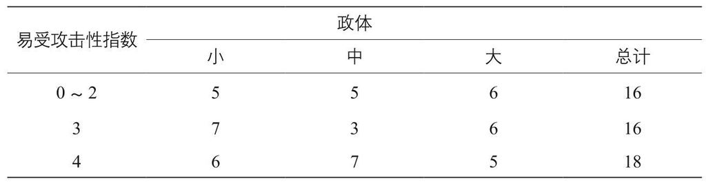

## 5.4 结论：欧洲的形成

查尔斯·蒂利（1975，第40页）撰写过一篇关于欧洲国家建构历史的文章，他在文中提出了这样的问题：“在1500年之后的每一个时间节点上，我们可以从政治单元的哪些特征来预测它是否会（1）作为一个独特的单元存活至下一个时期，（2）进行领土整合和权力集中，（3）成为民族国家的核心？”。正是这样的问题促成了本书提出的理论。我不敢说元民族边境理论能为每个欧洲国家的疆域动态提供精准的答案。但是，我认为该理论解释了欧洲政治发展的一般模式——“欧洲的形成”（Bartlett，1993）。

斯坦·罗坎等人（Stein Rokkan，1975；Rokkan and Urwin，1982）的著作对这种一般模式做出了特别清晰的阐述。罗坎指出，从地缘政治角度看，早期现代欧洲可被分为一系列带状区域，侵略性的国家构建区与政治薄弱、四分五裂的区域在其中交替分布。中间的一片长条形区域是领土分裂但经济繁荣的城邦，这片区域从北海和波罗的海南部沿着莱茵河延伸至意大利。在这条“贸易通道带”的西边是一片强大的征服中心区（“向海帝国”）：丹麦、英格兰、法国和西班牙。再往西还有一片政治上比较薄弱的领土（“向海边缘国家”）：冰岛、苏格兰、爱尔兰、威尔士和布列塔尼。中心贸易带另一侧的情形正是西边情形的镜像。首先是一群“内陆帝国”：瑞典、普鲁士、巴伐利亚和奥地利。接下来是一群“内陆边缘国家”：芬兰、波西米亚、波兰和匈牙利。因此，“矛盾的是，欧洲历史是在强大而独立的城市网络边缘形成中心的过程”（Rokkan，1975，第576页）。

本书第3~5章中提出并进行过检验的理论表明，这种异乎寻常的模式并没有任何让人觉得矛盾之处。我们可以从两个方面予以解释：通过元民族边境机制以“传染”方式实施的国家扩张以及群体感在帝国核心地带（长达数百年）的缓慢衰减。不过，要想弄清楚哪些区域在1500年之后发展出了强大的国家，哪些区域土崩瓦解并被他人征服，那我们必须回到加洛林时代的欧洲，而这个时代的欧洲又可以在罗马时代的欧洲那里寻找答案（顺便提一下，罗马的崛起缘由也可以往前追溯到公元前第一个千年里地中海地区的动态）。由于第5.2.1节中详细讨论过的原因，罗马帝国的莱茵边境成为墨洛温、加洛林和奥托（Ottonians）等一系列日耳曼帝国的核心区域。因此，高度城市化但在政治上四分五裂的政体中心带是由两个前帝国核心（古罗马和中世纪神圣罗马帝国）构成的。

现代欧洲形成的关键时期是后加洛林时期的9世纪和10世纪（Bartlett，1993），当时拉丁语基督教受到了四面八方来自维京人、撒拉逊人（Saracens）、马扎尔人和波罗比安斯拉夫人（Polabian Slavs）的袭击。一系列防御性边境——加洛林边陲——为应对这些威胁而设立起来。在边陲地带形成的新政体将注意力指向了外围<sup>[1]</sup>。在加洛林核心地带的西方和西南方，强有力的征服政体崛起于布列塔尼和西班牙边陲；在英格兰因诺曼征服而加入拉丁基督教世界之后，这样的政体也出现在英格兰。在北方，斯堪的纳维亚世界的合并是通过宗教皈依而不是通过征服实现的，它主要向东扩张，原因很简单：西方（冰岛）和北方（拉普兰）没有什么机会。最后，两个征服中心形成于核心地带的东方：一个位于撒克逊-斯拉夫边境（东进运动，Drang nach Osten，勃兰登堡-普鲁士因此而形成），另一个位于巴伐利亚-马扎尔边境（奥地利哈布斯堡因此而形成）。

总之，我认为，元民族边境理论为后罗马时代欧洲的政治发展时空模式提供了一个具有连贯的解释。它还对这个模式做出了更精确的陈述。比如说，罗坎相当随意地将丹麦划分为向海国家，而将瑞典归入内陆帝国带。与之形成对比的是，我将欧洲的政治演变解释为加洛林-奥托核心沿着除南方以外（另一个旧帝国的核心位于这里）的所有方向扩张。最后，上文提出的解释具有一般性这个优点。罗坎（1975，第596页）在他的著作中强调了欧洲格局的独特性。我认为欧洲的独特之处在于初始条件和边界条件（这是数学术语）的特殊组合，而不是一般机制。换句话说，欧洲一系列事件的具体走向取决于罗马帝国的起始点、外部入侵的时间和地点以及影响边境形成地点的河流和山脉等地理特征。不过，着眼于边境和集体团结之间关联的一般解释应该也可以应用于欧洲之外的地方。至少，它看起来是一个合理的工作假说（Tilly，1975），值得在世界其他地区对之进行研究。

[1] 感谢杰克·戈德斯通（Jack Goldstone）提出这一模式。

## 5.5 总结

●元民族边境模型预测认为，大型领土政体起源于受到高张力元民族边境长期影响的地区。在本章中，我通过公元后两个千年里欧洲（加上小亚细亚）的情况对这一预测进行了实证检验。

●我将总检验区划分为50个面积介于0.1到0.2Mm<sup>2</sup>之间的“文化区域”。针对每个区域和从公元0到1900年之间的每个世纪，我计算出了一个“边境指数”，该指数有四个组成部分，分别是民族线两侧的宗教差异、语言差异和经济生活方式差异以及战争强度。指数为0的区域在给定世纪里没有边界从中穿过，而指数为9的区域则是极具张力的重要元民族断层线。对于张力相对较强（张力得分为5分或更高）、边境稳定不变（持续三个世纪或更长时间）的地区，我将之划分为“边境”区域。其余地区被划分为“无边境”区域。

●我先是核对了公元1000年结束时边境与大型政体之间的关系。一个地区在公元0—500年充满张力且长期存在的边境与公元500—1000年源起于该地区的政体所实现的最大领土面积之间存在强相关性。统计检验以P≪0.001否定了无关零假设。

●在对公元500—1500年的边境情况与公元1000—1900年的政体最大面积进行对比后，我得出了类似的结果。同样，零假说因P≪0.001而被否定了。特别需要指出的是，我发现所有欧洲大国（英格兰、卡斯蒂利亚-西班牙、法国、勃兰登堡-普鲁士-德国、奥地利、立陶宛-波兰、拜占庭、奥斯曼帝国和莫斯科-俄罗斯）的起源地都受到了高张力且长期存在的边境的影响。唯一的例外是萨伏依-撒丁-意大利。

●我还根据“边陲”位置优势的地缘政治概念对一种备择假说进行了研究。根据每个地区海岸边界与陆地边界的比例，我构建了每个地区的易受攻击性指数。我发现，一个地区的易受攻击性指数与源自该地区的政体面积之间没有关联。

●这些结果为元民族边境模型提供了很大程度的实证支持，该模型的表现既优于完全随机的零假说，也优于将位置优势与地缘政治成功相关联的显式对立假设。然而，实证检验也发现了几个异常异象，其中以意大利最为重要。换言之，虽然边境模型对大部分大型领土政体做出了正确预测（至少就公元500—1900年的欧洲而言是这样的），但它没能预测出其他几个政体。这一观察结果表明，除了边境理论之外，可能还有其他机制可以解释大型领土政体的起源。

# 第6章 民族动力学

## 6.1 新并入人口的忠诚度动态

上两章分析了政体扩张的初始阶段，在此期间，新并入的群体迅速融入核心民族。该理论的一个设定是，居住在新占领区域的人口会立即转为忠于征服国。这倒未必是一个不切实际的设定。在某些情况下，特别是当新并入的精英群体与政体核心具有民族相似性时，因为没有强烈的民族差异，所以他们可能较快地融入核心精英群体。

然而，这种状况无法持续很长时间。一个成功的扩张型帝国迟早会吞并在民族上与之截然不同的人民（异族）所居住的领地。事实上，“帝国”的定义就是包含两个或更多民族的政体。一旦政体变得多民族化，新并入民族的忠诚度就会对其运作和扩张的能力产生强烈影响。新并入民族的群体感可能会在（每个种族居住的）区域层面和帝国层面之间出现大幅下降。这会带来两个后果。首先，由于被吞并民族的成员对帝国缺少忠诚，因此他们不愿为帝国贡献资源。因此，吞并异族对帝国地缘政治力量的助益将远远少于扩张相同数量民族相似人群带来的助益（即使国家强迫异族像核心民族成员那样做出相同的贡献，对国家实力的总体贡献也还是会减少，因为胁迫需要付出高昂的代价）。想要从异族招募到忠心耿耿的士兵尤为困难，因此很多帝国选择只从核心民族招募士兵（例如，罗马共和国，而不是罗马帝国；俄罗斯帝国）。

其次，不同民族的人更有可能背叛帝国。如果他们在民族层面的群体感很高，那么他们的精英群体就可以相对容易地发动起义并解决其中涉及的集体行动问题［关于这个问题的一般性综述，请参见Goldstone（1994）］。因此，帝国将不得不投入大量资源拉拢异族精英或压制他们的反叛。

简而言之，民族分歧有可能严重削弱国家的地缘政治实力。然而，民族并非一个静态变量，政体的民族构成是不断变化的。民族构成的变化先是人口机制的结果（人口增长率不同），然后是民族社会机制的结果（Bromley，1987），如民族同化和族群动员。因此，异族精英是否会融入核心民族以及这个过程的快慢与否将会对帝国的命运产生重大影响。

历史上绝大多数中型和大型政体都是多民族政体（McNeill，1986；Hall，1998）。由于地缘政治实力在很大程度上取决于政体的民族构成，所以我们需要对政体的民族构成如何以及为何随时间演变有一些定量的理解。因此，本章的主要目的是构建民族社会变化的动态模型。我把这种模型称为民族动力学，因为从数学角度来说，它们与化学动力学模型非常相似。我的首要重点是民族同化，因为它对帝国的力量基础来说极为重要。我还需要提醒读者，由于我使用了广义的民族定义，因此我不会将民族同化简化为语言同化。诚然，语言或方言是一个非常重要的民族文化象征，然而，在我们所研究的目标时期里，宗教经常会充当更重要的（元）民族标记。因此，就本章的研究目的而已，语言同化和宗教皈依这两个格外重要的社会过程是可以说明民族认同如何变化的实例。我在下文将引用宗教同化的实证案例。

## 6.2 理论

### 6.2.1 非空间同化模型

非互动模型

我先尽可能简单地公式化民族动力学过程。首先，我设定只有两个群体：核心民族和边缘民族。其次，两个民族的人口增长率是一样的。这意味着核心和边缘民族的相对比例只会因个体转换民族忠诚度（身份）而变化。再者，在每单位时间里，边缘民族以恒定的概率改变他们的民族并成为核心民族的成员。做出这些设定之后，就生成了我所说的非互动同化模型（之所以说它是非互动模型是因为民族身份变化的概率并不取决于其他人正在做什么）。霍普金斯（Hopkins，1973）和塞德曼（Cederman，1997）提出了极为相似的模型，不过这些作者在模型中设定的不是两类个体，而是多类个体（分类依据是他们是否被同化、是否被动员）。

很显然，设定只存在两个不同的民族而且个体在两个民族之间瞬时切换，是对现实情况的过度简化。然而，对于一些历史实例来说，这个简单的模型也许能提供不错的近似。我指的是历史上那些主要（甚至完全）以宗教定义其民族界限的民族。这样的话，“民族身份转变”其实就是指宗教信仰转变。奥斯曼帝国和莫斯科-俄罗斯是历史上两个相对开放地接纳愿意皈依该国宗教的个体进入核心精英群体的国家。第6.5节讨论了语言障碍和多维民族界限等更复杂的情况。

我们设C是核心民族在人口总数中所占比例，P=1-C是边缘民族在人口总数中所占比例。从边缘民族转为核心民族的概率是p。那么，描述宏观层面民族形成动态的微分方程就是

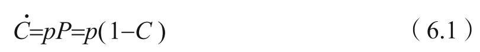

我们已经在2.1节中见过这种渐进增长的简单模型（等式2.3）。在C值处于低位时，该变量近似线性增长，最终它以指数方式接近均衡点C*=1（参见图2.1c）。

在推导等式6.1时，我设定的是只有边缘民族的成员才能改变民族身份。我们也可以允许逆向过程，即核心民族的成员转变身份（也就是说，“入乡随俗”；比如说，中世纪爱尔兰的古英语；Kidd，1999，第146页）。现在我们假设从边缘身份转变为核心身份的概率是p<sub>0</sub>，而反向转变的概率是p<sub>1</sub>。进行这样的改动之后，我们就得出了一个非常接近渐进增长的模型：

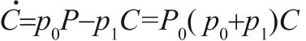

。但是，在均衡点，核心民族的比例不是1，而是C*=p<sub>0</sub>/(p<sub>0</sub>+p<sub>1</sub>)。不过，这个模型接近均衡点的方式与简单模型的方式是相同的：先是线性地，后是渐近地。

自动催化模型

尽管非互动模型已经被用于研究民族同化［如Hopkins（1973）和Cederman（1997）所做的多类别改进］，但我认为它有很大的缺陷。问题并不在于它过于简单，因为我即将讨论的可选方案也同样简单（其实还要更简单，因为它的参数少了一个）。问题出在非互动模型假定了一个从社会学角度来说令人难以置信的场景。社会不是由原子化的个体组成的；相反，每个人都嵌在一个（或多个）由其他个体组成的社交网络之中。从我们对谣言、创新和族群传播的了解可以看出，这些文化元素是通过接触，经由社交网络从一个人传播给另一个人的（Rogers，1995）。以宗教皈依为例，一个人不会简单地因为在报纸上看到关于一个新教派的新闻就皈依这个教派。相反，宗教社会学家已经证实（Stark，1996；Stark and Bainbridge，1996），宗教皈依就像传染性疾病一样，是沿着人际纽带进行传播的。“宗教皈依运动取得成功的关键就是通过社交网络、通过直接而亲密的人际纽带结构实现信徒数量的增长”（Stark，1996）。

我们如何将微观层面的这些假设转化为描述宏观层面宗教皈依动态的模型？要想做到严谨缜密，则需要显式空间法（此处的“空间”指的可以是社会空间而不是物理空间）。我们将在下一节讨论这种方法。不过，此处我想用一种简单的模型来刻画非互动同化和基于关系网的同化（或宗教皈依）过程之间的差异，因此空间在这个模型中只能是隐式的。那么，让我们简单地假设宗教皈依概率与已经皈依的人数是成正比的，然后再来研究这一假设的结果。

为了让模型稍微复杂一点，我将允许双向民族转变的存在。将个体（在每单位时间里）从边缘身份转变为核心身份的概率设为p<sub>0</sub>=r<sub>0</sub>C，反向转变概率p<sub>1</sub>=r<sub>0</sub>P（转变为一个民族的概率与该民族所属人口的占比是成正比的；比例常数r<sub>0</sub>和r<sub>1</sub>是转变的相对速度）。因此，边缘民族转变为核心民族的速度是转变概率与边缘人口占比的乘积。核心民族的转变率（rate of switching）也与此相似。因此，C的变化率（rate of change）是

[figure not shown]

定义r=r<sub>0</sub>-r<sub>1</sub>并代入上面的等式中，我们就得出了

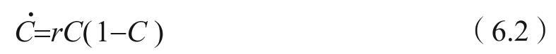

我们可以看到，这种推导生成了logistic方程——第2.1节讨论到的另一种基本增长模型。该模型甚至比设有p<sub>0</sub>和p<sub>1</sub>两个速率参数的完全非互动模型还要简单。在这个模型中，我们只需要知道一个参数，即两个相对速率的差，也就是r。

动态方程6.2与非互动模型有一个重要的不同之处：当C处于低位时，它将加速增长。加速增长模式的原因是转变或同化的人数越多，某一个体转变身份的可能性就越大。这种动态模式类似于化学动力学中的自动催化反应，即一种化合物的存在能够加快自身的生成速度。因此，我将把等式6.2称为自动催化模型。

非互动模型和自动催化模型的另一个不同之处在于，C在自动催化模型中接近的均衡点是1（假设r>0），而在非互动模型中，均衡点有可能远远小于1。仅这一点差异就足以让我们对非互动模型产生怀疑。当核心身份所占比例具有压倒性优势时，核心个体为什么还会继续转变成边缘身份呢？然而，这正是非互动模型的结论。显然，核心个体转变成边缘身份的情况仅应该发生在P≫C的位置，上文提到的盎格鲁-爱尔兰就属于这样的例子。

阈值模型

将转变概率设为与核心民族比例相关的函数，这是朝着正确的方向迈出的一步。然而，我们假定的是p和C之间为线性关系（p=rC），所以我们可以放宽这一假设的限制并看看将会出现什么结果。有一类特殊的非线性行为，即集体行动的阈值模型（Granovetter，1978；Schelling，1978），已在社会学文献中得到广泛讨论。它也曾被用来研究民族身份转变问题，这一点对于我们所研究的问题来说格外重要（Laitin，1998）。

我们可以将先前假定的p和C之间的线性关系调整成形式为p=rC（C-C<sub>0</sub>）的非线性关系，从而对阈值行为建模。新参数C<sub>0</sub>是阈值比例。当C>C<sub>0</sub>时，转变成核心身份的速度为正值，因为核心民族已经达到“临界规模”。当C＜C<sub>0</sub>时，转变速度为负值。也就是说，更多的个体正在从核心身份转变成边缘身份，而不是反向转变（换句话说，我将p视为正反两个转变概率之间的差）。谢林（Schelling，1978）和格兰诺维特（Granovetter，1978）等人详细讨论过临界规模和阈值行为的概念，因此我就不再赘述，读者可以参看这些作者的文献。

在模型中代入p的设定形式之后，我们就得到了以下等式

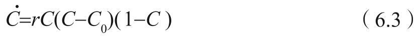

阈值模型属于亚稳定动态类（第2.1.2节）。它有三个均衡点：两个稳定的点是C=0和C=1，一个不稳定的点是C=C<sub>0</sub>。民族同化过程的结果完全取决于初始条件。如果C一开始的时候高于C<sub>0</sub>，那么轨迹最终将会接近1。换句话说，帝国的所有人口都转变为核心身份。或者，如果C一开始的时候低于C<sub>0</sub>，那么边缘身份将会取得最终的胜利，所有核心民族都会失去其原始身份。这是阈值模型的一个预测，而这样的预测看起来很符合诸多历史案例，在这些案例中，一小群入侵者征服了一个人数远超自身人口的异族。入侵者通常会改为信仰被征服者的主要宗教并使用他们的语言（如西哥特人、朗格巴德人、保加尔人和诺曼人）。

在阈值模型中，决定其动态的是全局频率（global frequency）高于还是低于阈值，而这一点是存在问题的，更合理的设定是个体转变身份的概率受到局部社会构成的影响。作为社交网络过程的近似模型，自动催化模型也受到了这样的批评，不过我们将在下文看到，即使在显式空间设定中（在特定条件下），它看起来也是一个不算糟糕的近似模型。另外，向阈值模型添加显式空间可能会显著改变它预测的动态。这是下一个需要我们研究的问题。

### 6.2.2 空间显式模型

正如我在本书中反复强调的那样，建立数学模型有诸多优点。其中一个优点就是，当我们为某个问题推导出一个特定的模型时，我们可能会发现，从数学角度来说，它和一些为完全不同的问题而设立的建模方程式是完全一样的。这意味着我们无须从头建立分析工具，相反，我们可以借助其他人之前做过的工作。民族动力学正是这样的情况。我们在上一节中构建的模型已被广泛用于化学动力学、谣言和创新的传播、流行性疾病动态等建模工作。我在上一节中指出，我们需要进行理论研究的一个关键因素是显式空间的添加。幸运的是，空间化学动态和空间种群过程动态领域有着丰富的理论（反应-扩散理论和流行病学模型），我们在研究时可以借鉴人们从这些数学理论中得出的认识［如想深度了解相关数学理论，请参见Murray（1993）］。在下文中，我将主要参考空间流行病理论的研究结果，因为它的数学形式最接近我们需要研究的这类过程。

社会空间

当我说我们需要添加“空间”时，我指的不一定是物理空间。相反，我们需要的是一些社会空间概念，其中个体之间的距离是以其社交互动的频率和强度衡量的。社会空间有很多维度，但社会学家常将它们缩减为两个主要类别：纵向和横向（Sorokin，1927）。纵向维度是指在社会等级上的位置（阶层）。因此，农民可能与村长有很多互动，村长又与当地贵族互动，依此向上类推至政体统治者。居住在同一个地方的两个人可能有着遥远的社交距离（比如说王子和穷光蛋）。横向维度则来自日常活动模式，如工作、抚养孩子乃至与邻居的交流（Black，1998）。横向维度有很强的空间性。因此，一个普通农民主要与同村的人们互动，与附近村庄的居民也有一定程度的互动，而与不同省份的人就算有互动也会是很少的互动。

社会空间具有一些特殊的拓扑特征（Black，1998）。首先，它通常是各向异性（anisotropic）的，因为向下的互动可能要强于向上的互动。例如，一位国王皈依基督教的决定对农民皈依概率的影响要大于反过来的情况。其次，阶层较高的人往往隶属于更广泛的社交网络。比如，一位中层贵族与邻省另一位贵族之间的联系应该会比两个相距同样物理距离的农民之间的联系更紧密。最后，某些地理特征，如山川，往往会增大社会距离。也许更好的衡量标准不是物理距离，而是以旅行时间衡量的距离。比如说，河流沿岸也可能出现水平各向异性（顺流而下要远比逆流而上更容易）。

流行病学有一个重要概念被用来构建语言同化和宗教皈依的空间模型。这个概念就是接触分布（contact distribution），在流行病学中它被定义为疾病从一个人传给另一个人的概率，是一个与两者间距离相关的函数。我们可以将接触分布重新解释为在社会空间中位于不同位置的两个人之间的社交互动强度。宗教皈依完全可以与之相类比，因为我们可以将接触分布解释为宗教皈依从一个人传给另一个人的概率。这个公式原则上允许模拟各种复杂效应，包括异质空间（如山脉和其他屏障）和各向异性（例如较高层人物的特点是更大规模的接触分布）。我在此不打算追求这些复杂效应，因为如果一个模型包含了所有这些现实特征，那我们就得通过计算机模拟来求解。相反，我重点关注的是空间会如何改变民族动力学过程的频率依赖性。在这个问题上，我们可以借鉴流行病学理论给出的分析结果。我首先考虑自动催化模型的空间扩展版本，其次是阈值模型的空间扩展版本（非互动模型不受空间影响，因为每个人自发地改变身份，不受他人行为的影响）。我在下文中没有给出数学方程，因为感兴趣的读者可以在相关的专题文献中找到这些方程。我写过一本关于运动定量分析的书（Turchin，1998，第70—72、329—348页），读者可以在这本书中找到有关空间接触过程和传播模型的生态学方面的介绍。默里（Murry，1993）和莫里森（Mollison，1995）的著作中有更多的技术探讨。我无须深入研究数学结果，因为我所做的只是借用已经完善的理论，并从社会接触及身份转变所受的社会影响这两个方面来重新解释。

空间自动催化模型

为了将自动催化模型变成空间显式模型，我们首先要将拥有核心身份C（t）的个体的频率重新定义成一个在空间上可以变化的变量C（x，y，z，t）。这里的x和y代表物理空间坐标，z代表社会等级地位；t还是代表时间。在举例时，C（x，y，z，t）可能是指在某个特定时间点和某一特定城镇的小商人中基督徒所占的比例。其次，我们定义了接触分布：V（s）是社交距离为s的两个人之间的社交联系强度。请注意，在这个模型中，我假设的是接触分布不会随空间、等级或时间变化。不过，上文说了，我们也可以做出这样的改动并以数字方式对得出的模型进行研究。再者，我将个体转变身份的概率设为与附近其他个体身份相关的函数，我根据这些个体会与目标个体的社交距离对他们赋予权重。为了说明这一模型的工作原理，让我们假设接触分布是矩形的，如图6.1a所示。这意味着，与目标个体进行社交互动的亲戚和朋友有一定的圈子，而且圈子内部每个个体的互动强度是相同的。然而，在这个圈子之外，互动强度为零。因此，身份转变的概率就与圈子内部已经完成身份转变的个体所占比例形成正比关系。

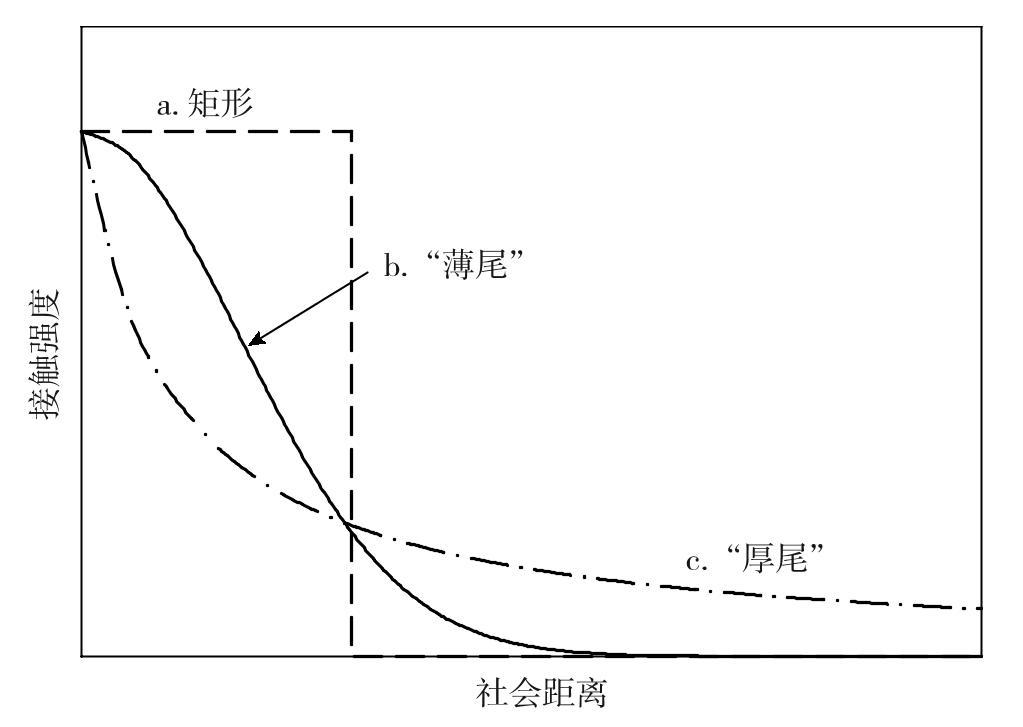

图6.1 接触分布的不同形状

矩形接触分布对于人类社交互动来说并不是一个切合实际的形状，因为有些人也许会有相距很远的熟人，只不过他们之间的互动可能没有那么频繁。因此，接触分布不应该突然结束，而是应该有一些拖得相当远的“尾巴”，这些“尾巴”代表的是少数几个个体（例如，距离遥远的商家）。空间接触过程的数学理论区分了两种重要的情况：当接触分布的尾部随社会距离呈指数（或以更快速度）下降时的“薄尾”情况，以及尾部下降得比指数要慢的“厚尾”情况（图6.1）。下文我们将会看到，这两类尾部意味着截然不同的空间动态。

当接触分布带有尾部时，就意味着目标个体在做出身份转变的决定时，考量的不仅仅是周边其他人的行为，还有整个社会的情况。不过，社会距离遥远的个体产生的影响要远远小于朋友和亲戚这个小圈子的影响。影响力随社会距离扩大而减少的幅度是通过接触分布以多快速度下降到零来度量的。

从数学角度看，薄尾接触分布的情况很好理解。如果身份转变的概率与其他人所持身份的加权平均值成正比（权重由接触分布决定），那么这一空间接触过程就可以通过反应-扩散模型来得到近似模拟——在该模型中，局部源/汇（source/sink）项为logistic分布，而空间再分布属于简单扩散。自费希尔（Fisher，1937）和科尔莫戈罗夫等人（Kolmogoroff et al.，1937）对优势基因的空间传播进行开创性研究以来，这一模型已经得到了全面的研究。它在社会科学中的一次广为人知的应用是欧洲新石器时代农民的扩散模型（Ammerman and Cavalli-Sforza，1973）。该模型的动态如下：我们假设最开始只有少量皈依新宗教的人口（如围绕先知或弥赛亚形成的一群门徒）。局部转变过程将遵循S形logistic曲线，最初以指数方式增长，然后在所有当地人都皈依新宗教时达到饱和。空间扩散起初也会加速，但很快就会形成一个明确的前沿，这个前沿将以恒定速度随时间扩展。其结果就是，大多数人皈依的地区的总面积会随时间线性扩大。因此，在最初的加速增长之后，皈依者的数量将呈线性增长，直至整个可用空间都被占满。

薄尾接触分布中这种有序前沿与厚尾接触分布的情况形成了鲜明对比。最初的一小组皈依者将在局部呈logistic增长，这和薄尾接触分布是一样的。然而，随着身份转变者数量的增加，他们中的某个人认识远距离熟人而且这个熟人皈依的可能性就越来越大。对一个传教式宗教来说，最有可能的机制是最初的宗教社区向外派遣传教士。皈依过程中的这种长距离跳跃将阻止有序前沿的形成。相反，我们会看到原始中心点周围形成一些次级扩散中心点，然后由于次级中心点向外派遣传教士，又会出现三级中心点并依此类推。整个空间过程将以加速方式向外扩散，全局皈依者的数量将呈现S形增长模式。接触分布的尾部越厚，全局扩散过程就越接近logistic曲线。

空间阈值模型

空间阈值模型的行为方式完全不同于自动催化模型［相关数学细节请参见Lewis and Kareiva（1993）］。第一点是相当明显的，那就是皈依的初始局部比例必须超过阈值C<sub>0</sub>，否则，新的宗教就会消亡。第二点不那么明显，那就是新宗教最初占据的区域（“滩头阵地”）在面积上必须超过一定的阈值。否则，跨越边界的“扩散性损失”将超过新宗教所在区域内的皈依率，因此这个宗教将以失败告终。第三点区别也是最重要的不同之处，那就是不管接触分布是什么形状，阈值模型都只能有线性边界。之所以出现这一特征，是因为超出前沿太远的皈依者将会受到阈值效应的影响：他们将在局部被非信徒淹没。

该理论所做的另一个有趣的预测是，在社会关系四通八达的空间里，两个身份不可能共存。假设两个身份之间以某种方式建立了空间前沿。那么它将始终朝着一个方向或另一个方向向前推进。在上文提出的特定形式的阈值模型（等式6.3）中，推进方向取决于C<sub>0</sub>是否大于0.5。如果是，那么核心身份就输了；否则，它就赢了（Lewis and Kareiva，1993）。然而，如果跨越边界的社交互动明显少于两侧的互动，那么稳定的共存是有可能的（如Levin，1976）。

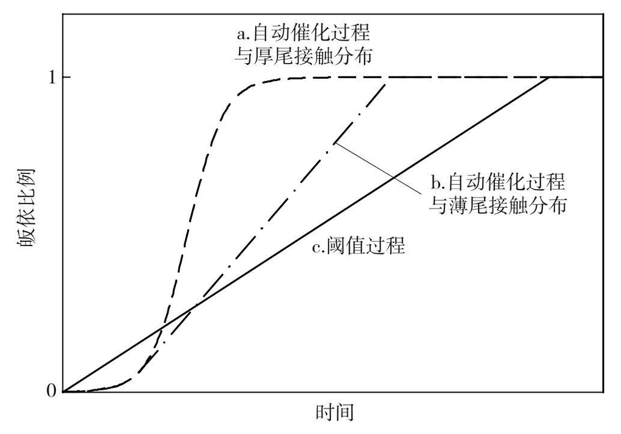

图6.2 空间接触模型所预测的扩散模式示意图

总结：空间接触模型的三种增长<sup>[1]</sup>类型

总的说来，本节介绍的空间模型预测了三种不同模式的宗教皈依或同化过程。图6.2a给出了这些模式的示意图。扩散最快的是出现厚尾接触分布的自动催化模型。在这种情况下，皈依过程会在初始皈依组所在位置加速增长。在这个过程（因局部大部分人口完成身份转变）进入局部饱和阶段之前，皈依过程会跳转到其他一些地点，从而进一步推动增长，并产生进一步的扩散中心点。因此，皈依动态是爆炸式的。接触分布的尾部越厚，就会越快到达我们建模总区域中的所有点。如果尾部相对于整个区域来说基本是扁平的，那么空间过程与非空间logistic动态就没有什么区别。

相反，如果接触分布的尾部快速变薄（薄尾），那么我们首先应该观察到一个“潜伏期”，在此期间没有任何扩散（这是局部皈依者的数量增长期），随之而来的是一个加速增长期。最终，皈依区和未皈依区之间形成了一个空间前沿。该前沿以恒定速度向前推进，形成线性扩散，直到整个区域最终完成皈依（图6.2中的曲线b）。

最后，如果皈依过程以阈值为特征，那么接触分布的形状就无关紧要。如果皈依过程是可行的（这需要足够的初始皈依规模、一个不太高的皈依阈值C<sub>0</sub>以及扩散过程中不太大的皈依损失），那么皈依区和未皈依区之间很快就会形成空间前沿。该前沿随后线性向前推进，不过速度要慢于自动催化情况下的速度。传播速度较慢的原因是，为了让前沿向前推进，边界处的皈依者数量必须超过阈值C<sub>0</sub>。相反，在自动催化模式下，即使局部密度较低，皈依过程也可以扩散。因此，在阈值模式下，前沿是被其后方的大量皈依者“推动”的。在自动催化模式下，前沿是由其前方少量皈依者与未皈依人口之间的互动“牵引”的。

[1] 这里的增长是指皈依宗教的人口数量的增长。——译者注

## 6.3 实证检验

第6.2.1节的三个模型为民族动力学理论的实证检验提供了一个合理的起点。我将重点检验非空间模型，因为目前我无法获取任何宗教皈依或同化方面的空间数据集来对空间模型进行检验。确实，空间模型预测出了不太一样的同化时间轨道全局模式（如图6.2所示），理论上我们可以借此来设计实证检验。然而，一些实际问题使得这个想法无法直接实现。首先，图6.2所描述的模式是高度程式化的。要想获取更精确的定量预测，就需要根据各种有关身份转变过程和接触分布形状的设定，从数值上求解空间显式模型。其次，图6.2中的三条轨迹都预测了类似于S形的动态。鉴于现实数据会受到各种程度的过程和观察噪声的影响，在实践中想要区分可选理论将会非常困难。换句话说，我认为，试图根据全局民族变化（ethnic change）模式数据来区分各种空间模型的方法将具有较低的统计效力。我们需要显式空间数据来检验显式空间模型。

与空间模型相比，民族变化的全局曲线应该能为我们提供一个极好的机会来设计非空间模型（非互动式、自动催化和阈值过程）的实证检验。然而，我们必须慎重选择反应变量才能让检验的统计功效达到最大化。统计学中的反应变量或因变量是基于预测变量或自变量预测出来的（Box and Draper，1987）。我们可以通过测定可选模型对反应变量的预测准确程度来区分这些模型。对反应变量做出最佳预测的模型即数据最支持的模型。在对比三种模型的预测能力时，一个显而易见的反应变量选择——但未必是最佳选择——将是轨迹C（t），即核心身份在时间为t时所占的比例。我们可以看一看非互动模型和自动催化模型所预测的轨迹（见图2.1c和d）。鉴于数据不够丰富以及大量的噪声（这是对历史应用的切合实际的预设），我们通常很难确定曲线是否具有初始加速阶段。相比之下，如果我们看一下不同模型对C的变化率的预测，就会发现不同模型之间的对比非常明显（图6.3）。非互动模型预测了和C之间的线性关系（图6.3a），而自动催化模型预测了一个驼峰曲线（图6.3c）。简单对比一下C＜0.5时的关系斜率（负值或正值），就足以判定哪个模型更接近现实情况。阈值模型的预测相当惊人：C＜C<sub>0</sub>时的变化率为负值（图6.3e）。自动催化和阈值模型之间的另一个对比也可以派上用场，那就是它们对相对变化率/C的预测（图6.3 d与f；对非互动模型相对变化率的检验，即图b，不是很有意义，但还是被涵盖在内以确保完整性）。

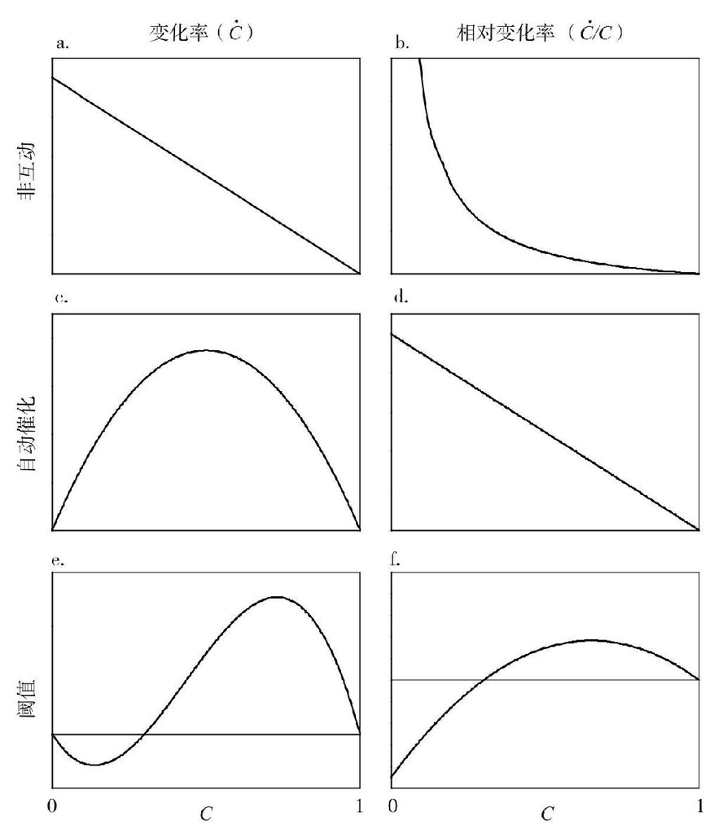

图6.3 非互动模型（图a和b）、自动催化模型（图c和d）、阈值模型（图e和f）预测的C与变化率的关系（图a、c和e）和相对变率/C（图b、d和f）

这里的关键信息是，我们肯定应该检验实证时间轨迹并将它们与模型预测的轨迹进行比较，但是为了更充分地利用数据，我们也应该以图6.3的描绘方式来绘制它们（并把模型套入它们）。这样做可以让我们更快地找到观测轨迹背后的机制，因为我们是在微分方程的层面上（绘制观察到的变化率与状态变量），而不是在方程时间解更具现象性的层面上来考察动态过程的结构。

接下来我将把这些设想应用于三个数据集，这三个数据集分别是人们皈依伊斯兰教、基督教和摩门教的情况。我们的目标是判定三种可选模型中的哪一个与实证模式最匹配。

### 6.3.1 皈依伊斯兰教

数据

第一个案例研究的立足点是理查德·布利特所建立的数据库。传记辞典这一文学体裁是伊斯兰社会的特色文化产品之一（Bulliet，1979，第9页）。包含诸多条目的传记汇编成为中世纪伊斯兰社会量化数据的独特来源。布利特分析了伊朗传记辞典中的近6000条传记并发现了一个很有意思的模式。传记中基本没有出现波斯名字，这些人属于虔诚的上层阶级，他们的一个常见习俗就是给自己的儿子取阿拉伯名字。然而，波斯人的名字出现在了传记的族谱中。在三分之二以上的族谱中，第一个名字都是波斯名字，然后到后面就会完全变成阿拉伯名字（Bulliet，1979，第18页）。布利特做出了这样的假设：排在序列第一位的波斯名字是家族中第一个成为穆斯林的成员（这一假设在某些情况下可以通过独立信息得到证实）。因此，以波斯名字开头的族谱子群就可以在伊朗家庭皈依伊斯兰教的大致日期方面提供可靠数据。这个子群共有469个族谱。布利特将穆斯林日历切分成25年一个时期，并计算了每个时期的预期皈依比例（详见Bulliet，1979，第3章）。

伊拉克、叙利亚、埃及和西班牙也有大量族谱可以查证。如果对这些地区的情况进行同类分析，以此来验证伊朗的分析结果，那将大有助益。不巧的是，非阿拉伯名字在伊拉克、叙利亚和埃及非常罕见。所有这些地区都成为讲阿拉伯语的地区，甚至在伊斯兰征服之前，伊拉克和叙利亚的居民所说的就是与阿拉伯语相关的语言。幸运的是，西班牙的情况有所不同（Bulliet，1979，第10章）。布利特从五本传记辞典中找出154份以非阿拉伯名字开头的西班牙族谱。他像分析伊朗族谱数据库那样进行了分析并计算出每50年间皈依伊斯兰教的家庭所占的比例（由于数据点的数量少于伊朗，因此他所划分的每个时间段的长度要长于伊朗）。我们可以使用这些数据来对伊朗的数据进行独立验证，因为穆斯林西班牙是一个在地理上和时间上都与其相差甚远的地区（它被征服的时间比伊朗晚了70年）。

分析

在对每25年间皈依伊斯兰教的伊朗家庭所占比例与该时期的中点进行对比分析之后，我们得出了伊朗皈依伊斯兰教的估算曲线（图6.4a）。从数据来看，这应该是一个类似logistic曲线的过程。在拟合了logistic时间解之后，这一印象得到了证实：

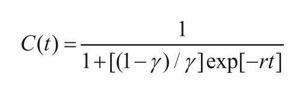

拟合参数γ=C（0）是在时间t=0时的初始皈依比例，r是相对皈依率（公式6.2中的同一参数）。这个双参数曲线能够解释反应变量C（t）99.98%的变化，这是一个相当惊人的数据。即使从物理科学的标准来看，这也是一个极佳的拟合。与之形成对比的是，非互动模型只能解释79.2%的方差（请注意，这个数据本身也是非常可观的结果，但是在将数据作为判断标准对可选模型进行比较时，重要的是相对拟合程度；也就是说，哪个模型表现得更好，好多少。）

针对西班牙数据的分析得出了几乎相同的结果（图6.4b）。logistic曲线解释了99.7%的方差。有趣的是，参数r的拟合值大大低于伊朗的值（伊朗的r值为2.8世纪<sup>-1</sup>，西班牙的r值为1.5世纪<sup>-1</sup>）。同样，非互动模型与数据的拟合程度要差很多（后者能解释76.6%的方差）。

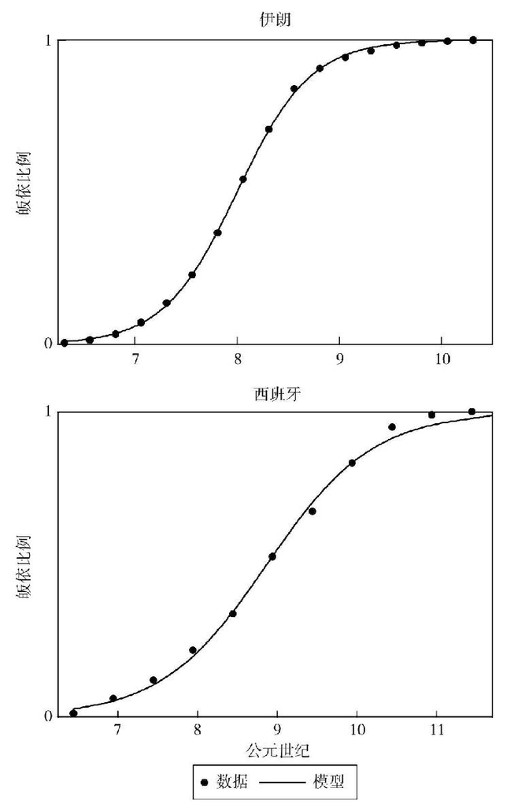

图6.4 伊朗和西班牙皈依伊斯兰教的轨迹图

资料来源：Bulliet（1979），表2和曲线图20。

在分析-C相图（图6.5）时，我们看到了进一步支持自动催化模型的证据（与两种可选方案相比）。曲线在C＜0.5区的正斜率是一目了然的，无须统计检验。此外，没有证据表明会出现负变化率，但阈值模型预测了负变化率。因此，在6.2.1节提出的三种简单可选方案中，自动催化模型给出了迄今为止对实证模式的最佳描述。另一方面，相空间中标绘的数据揭示了皈依过程的一些有趣特征，这些特征在轨迹图中并不明显。尤其需要指出的是，曲线看起来是不对称的（向右倾斜），而logistic模型预测的当然是完全对称的抛物线。为了进一步研究这个问题，让我们看一下数据所显示的相对变化率与皈依比例之间的关系（图6.6a）。我们看到，虽然从定量角度看，相对皈依率之间有着相当大的差异（伊朗的过程几乎快了一倍），但从定性角度来说，两条曲线有相同的非线性。这样的观察结果表明，这不仅仅只是一个抽样问题（当然了，只有两次重复采样）。话说回来，还有一种情况也大有可能，那就是我们观察到的非线性是布利特从族谱中提取皈依日期时的程序导致的。如果这种非线性是真实的，那让我们推测一下造成这一非线性的有可能是哪种机制（这是为日后的研究工作生成假设的一种方式）。首先，非线性肯定不会产生任何阈值效应，因为这会造成反曲率非线性（见图6.3f）。此外，空间模型全都预测了皈依过程初始阶段的加速度，这同样无助于解释观察到的模式。实际上，函数在C处于低位时的凹形与非互动过程有一些相似之处（见图6.3b）。这一观察结果提出了以下可能性：该过程在最初阶段是非互动的，然后又变成了自动催化式。比如说，人口皈依比例一开始上升是移民迁入的结果。随着皈依者数量的增加，该过程的自动催化部分迅速淹没了移民迁入带来的增长。我用这个显式模型研究了一下这一设想，发现只要p≪r，也就是说，在移民迁入率很低的时候，模型就可以精确地预测出数据中观察到的形状。图6.6b给出了移民迁入-自动催化增长模型预测的模式。

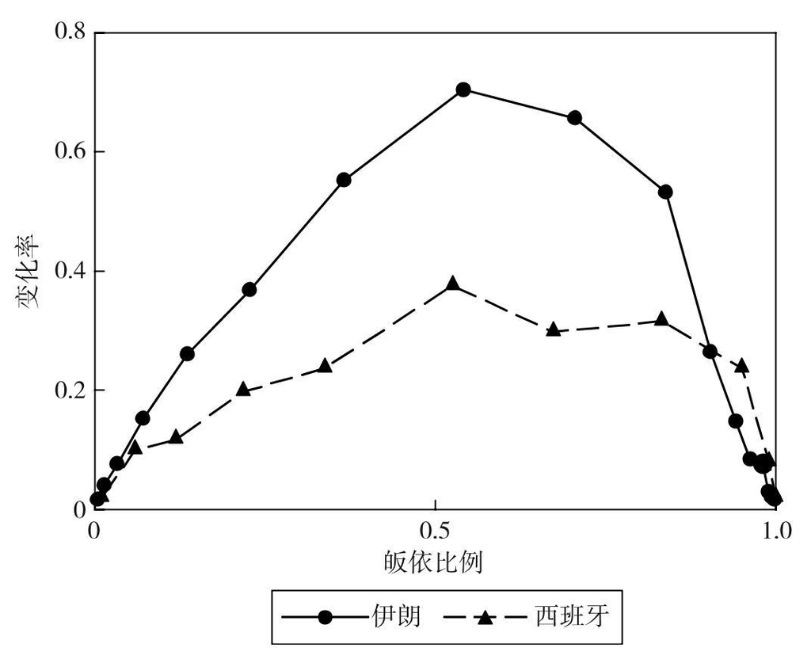

图6.5 -C相图中绘制的伊朗和西班牙的数据

注：变化率的单位为每个世纪的皈依比例。

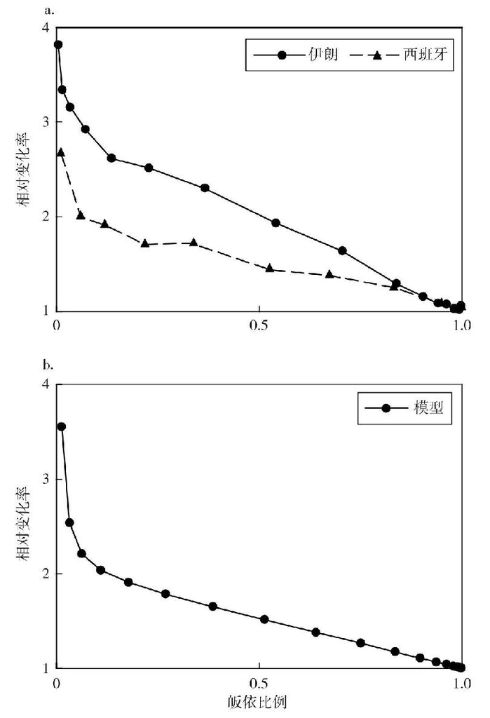

图6.6 （a）/C-C相图中绘制的伊朗和西班牙的数据

（b）移民迁入-自动催化模型预测的相对变化率与皈依比例之间的关系

注：变化率的单位是世纪<sup>-1</sup>。

总之，对布利特数据的分析表明，自动催化模型与实证模式的拟合度绝对优于非互动模型和阈值模型这两种可选方案。实际上，自动催化模型达到了99.98%的精确度，这样的数据（至少在非物理科学中）是前所未有的。然而，这种完美拟合的部分原因在于我们选择的特定视角，即拟合时间轨迹。在对状态变量（C）与其变化率以及相对变化率之间的关系进行更细致的研究之后，我们发现自动催化模型的预测与实际数据之间也有一些出入。我们还发现，一种相对于简单自动催化模型来说要稍微复杂一些的可选模型，即有移民迁入的自动催化过程，与实证数据有着更好的拟合度。虽然最佳拟合的模型是由数据反推得出的，但它看起来与我们掌握的西班牙在伊斯兰征服之后的历史真实走向比较吻合，当时确实出现了穆斯林阿拉伯人和柏柏尔人的大举迁入。不过，我们需要注意的是，目前只有两次重复采样（这是防止采样错误所需的最低数量）。此外，我们观察到的非线性有可能是布利特在估算皈依日期时出现的某些（未知）偏差的结果。最后我要说明的是，两者的差异相当小，新模型最多算是对基本自动催化模型的二阶改进。事实上，基本自动催化模型与数据的拟合程度已经达到了极高的水平。

### 6.3.2 基督教的兴起

第二个案例研究更多地属于定性分析，原因就在于我们手头上有关基督教皈依动态的数据集并不像布利特为伊斯兰教皈依建立的数据集那样完善。本节中的材料主要引自罗德尼·斯塔克的《基督教的兴起》（Rodney Stark，1996）。

在探讨基督教兴起时，让历史学家印象深刻的是公元头两个世纪里基督徒的数量之少以及第三个世纪下半叶突然出现的信徒增多，可以称得上是暴增。大多数研究早期基督教的历史学家得出了一个结论：要想出现这种惊人的扩张，必须得有某种异乎寻常的大规模皈依才行（具体原文请参见Stark，1996，第14页）。斯塔克指出，这样的观点源自人们对自动催化过程的本质存在错误认识。指数或logistic等自动催化过程有一点异乎寻常之处，那就是在基本驱动机制没有改变的情况下，它们的增长阶段似乎是不连贯的。它的驱动机制就是相对皈依率（单位时间内新成员数量与现有成员的比率）。虽然相对皈依率保持不变，但绝对皈依率（相对皈依率和已皈依比例的乘积）会随时间上升，因此让人产生了该过程在定性方面会经历不同阶段的错觉。

斯塔克用4世纪中叶之前的基督徒增长估算曲线对这一现象进行了说明。他假定，在公元40年时大约有1000名基督徒，然后他们以每10年40%的相对皈依率呈指数增长（斯塔克使用的指数模型与我们的logistic增长模型并没有实际差异，因为这两个过程对早期增长阶段做出了基本相同的定量预测，两者只在皈依比例超过10%~20%之后才开始出现分叉）。1000人对应的是罗马帝国人口的0.0017%。斯塔克预测，到公元200年时，皈依基督教的人依然不到罗马人口的1%（确切地说是0.36%）。然后就出现了“突飞猛进式”增长：公元250年为1.9%，公元300年为10.5%，公元350年为56.5%（Stark，1996，表1.1）。换句话说，基督教在公元50—250年没有出现明显增长（流行病学术语中的“潜伏期”），但在公元250—350年出现了惊人扩张，而这有可能是在基本皈依机制没有任何变化的情况下发生的。只要早期的基督徒设法保证其社交网络的开放性，他们就会继续以相同的相对变化率来联系新成员并让其皈依，最后的结果就是基督教的社区规模出现最终的爆炸式扩张。

斯塔克通过整合各种来自不同渠道的定量和定性信息，得出了预测的皈依转换曲线的参数（公元40年时的初始人数和相对增长率）（参见Stark，1996，第4—12页）。几年后，因为一位同事的缘故，斯塔克开始关注罗杰·巴格纳尔（Roger Bagnall）对埃及基督教增长情况的数据再现。巴格纳尔核对了埃及纸莎草记录，以确定不同年份中带有明确基督徒名字的人所占的比例（Stark，1996，第12—13页）。将斯塔克的预测曲线与这些独立数据进行对比就可以检验该理论（事实上，这是一个真正的实证检验，因为斯塔克在构建他的预测时并不知道巴格纳尔的数据）。图6.7显示了检验的结果。拟合度相当高，预测系数达到了非常可观的R<sup>2</sup><sub>pred</sub>=0.74。所以说，这次检验是对该理论强有力的定量证实。

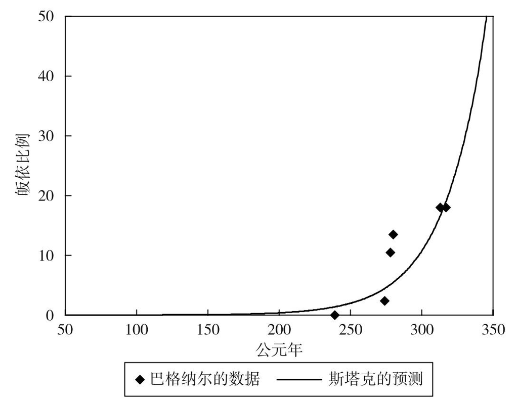

图6.7 斯塔克对罗马帝国早期基督教增长情况的预测和巴格纳尔关于埃及基督徒比例的数据

### 6.3.3 摩门教的发展

最后一个案例研究涉及摩门教这个现代宗教的发展情况。相关数据是1840年至1980年间末世圣徒教会（Church of the Latter Day Saints）的成员总数，斯塔克（1984）将之制成了表格。为了将logistic模型与这些数据拟合，我需要将它们转换为比例。因为摩门教是一个全球性宗教，在所有有人居住的大陆上都有分支，所以我将这些数据表示为全球皈依人口的比例。这么做可能会高估潜在皈依者的数量，因为摩门教的皈依目标是那些对其他宗教没有坚定信仰的人。不过，这一点不会影响分析结果，因为无论我们如何定义“有望皈依”的人口，摩门教徒离皈依中点都很遥远，因此自动催化模型预测它们的增长应该基本呈指数方式。

logistic曲线与这些数据的拟合显示，该模型解释了98.9%的方差。因此，我们再次在理论预测与观察轨迹之间取得了非同寻常的拟合（图6.8）。

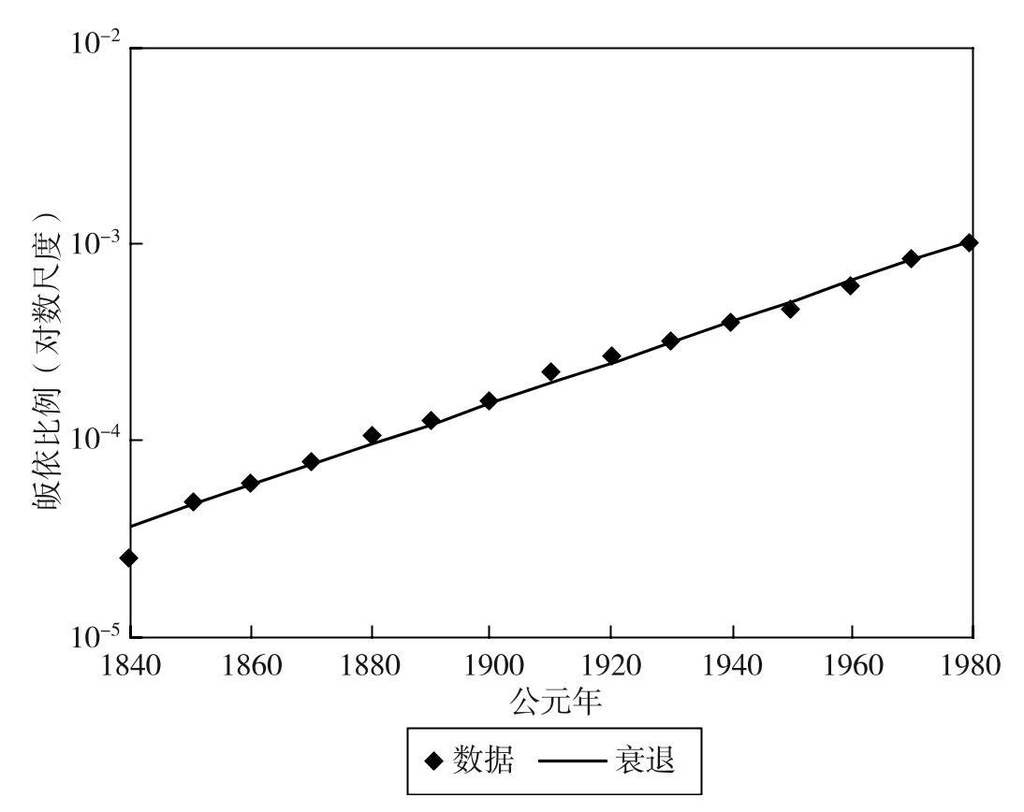

图6.8 1840—1980年皈依摩门教的全球信徒所占比例

注：数据是以对数标度绘制的，以突显人数增长的指数性质——指数性质是自动催化动态在C处于低位时的表征。

## 6.4 结论：自动催化模型的数据支持

表6.1总结了实证检验的结果。这些结果有一个突出的特点，那就是自动催化模型与数据（或预测，在基督教的案例中即是这样的情况）的拟合度相当高，尤其需要指出的是，这是一个非常简单的模型。它只有两个拟合参数［初始条件C（0）和相对皈依率r］。由此可以得出的重要信息是，并非所有历史都是一团乱麻或无从预测。此外，我们是有可能对可选模型进行全面检验的。我们最初提出了三个模型，这三个模型对人们如何皈依新宗教有着不同的假设：分别是非互动、自动催化和阈值过程。对全部四个数据集的定量检验生成了一致的结果：自动催化模型与数据的拟合度要远远胜过另两个可选模型。这是一个令人振奋的结论，因为根据当前的社会学看法，宗教皈依是通过人际网络传播的（Stark，1996），这也是自动催化模型所依据的机制。换句话说，完全以数据为依据进行的分析与理论上的假设是一致的。

表6.1 实证检验总结

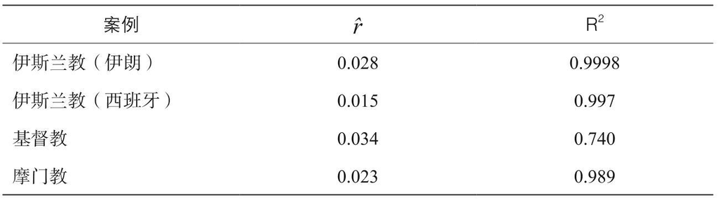

注：估算的相对皈依率和自动催化模型能够解释的数据方差比例R<sup>2</sup>（基督教除外，其R<sup>2</sup>是预测的比例）。r的单位为年<sup>-1</sup>。

如果我们剖析一些更加准确的数据（比如说皈依伊斯兰教的两个案例），就会发现模型预测和数据之间存在一些系统偏差。但这一点绝不会削弱自动催化模型的成就：它的表现远远优于其他可选模型，而要想取得科学进步，就得不断改进理论，舍弃表现不佳的可选模型并保留更好的可选模型（事实上，在这个案例中，即使从绝对意义来说，自动催化模型的表现也极为出色，不过这并不是重点）。此外，根据我们所观察到的系统偏差，可以得出一个改进模型：先是移民迁入，然后是自动催化的皈依过程。根据我们对早期伊斯兰伊朗和西班牙历史的了解，这种说法完全站得住脚。

自动催化过程对实际观察到的皈依动态有着最准确的描述，这一实证发现对历史动态研究具有重要意义。（不同于渐进增长）logistic增长对初始条件有一定的敏感性。比如说，我们来看一下基督教的发展壮大。我们先用到达logistic曲线拐点（也就是50%的人口转为皈依基督教的时候）所需的时间对皈依的时标进行量化处理。从公元40年时的1000名基督徒开始，根据斯塔克估算的=0.034，我们将在公元368年达到中点（稍晚于斯塔克的计算结果，因为斯塔克用的是纯指数方法，而我用的是logistic模型）。为了将logistic增长与渐进增长进行对比，我们假设参数p=0.0021，有了这一参数后，从公元40年1000名基督徒起步的渐进过程也在公元368年达到中点。渐进模型的预测轨迹对初始条件——即公元40年有多少基督徒——极不敏感（表6.2）。无论公元40年时有10名还是100000名基督徒，它都会在公元368或367年达到中点。与之形成对比的是，初始条件每出现10倍的变化，logistic模型的预测中点就会改变69年（表6.2）。

表6.2 logistic与非互动模型对不同初始条件下50%人口皈依的时间点所做的预测

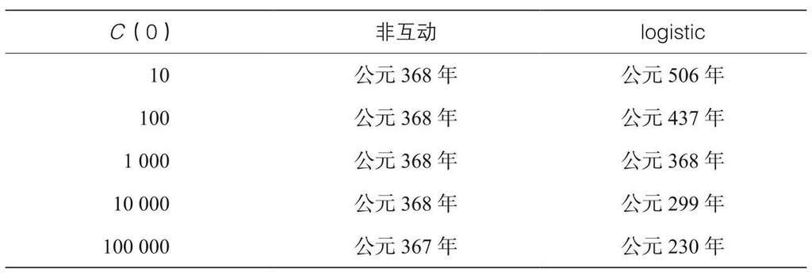

最后，在实证检验中，我关注的是宗教皈依，因为我可以找到这方面的数据。然而，宗教只是民族象征或民族边境的标记源之一。界定性标记的性质会影响跨越这些标记的难易度。跨越某些界限很容易（比如说得体的着装），而另外一些界限则较难跨越，甚至不可能跨越。比如说，如果人种是定性民族特征之一——就像现代日本那样——那么一个欧洲人就没有被接纳的可能性。基于语言的界限对个人来说也很难跨越，因为绝大多数人一旦进入青春期之后，就无法把外语学得像母语使用者那样流畅。此外，语言同化通常不是直接发生在一种语言和另一种语言之间，而是通过一群双语说话者间接发生的。因此，跨语言民族同化甚至有可能比宗教皈依还要缓慢。请注意，即便是宗教皈依也是一个异常缓慢的过程：从实证案例研究来看，通常需要2~3个世纪才能达到皈依的中点。

我在模型中只设定了两类个体：已经同化的个体和没有同化的个体。要想让模型更加贴合实际，创建其他一些类别是一种可行之道。比如说，要想对语言同化建模，也许可以明确添加第三个变量，即政体中双语人口所占的比例。此外，当民族边境涉及多个符号维度时，创建多个类别可能是一个合理的建模方法。比如，如果同化既需要皈依官方宗教，也需要学习核心民族的语言，那我们可能会设立四个类别，反映出两种宗教和两种语言的所有可能组合。原则上，我们可以添加更多类别来进行细分，但这样的话模型最终将变得过于复杂而难以管理。另一种方法是假设两个民族之间的差异可能有多个连续的维度。因此，如果我们希望用个体特征来显式模拟民族内部差异性，则每个民族都是这个多维空间中的一个点，甚至是一个点群。那样的话，关键变量就变成了两个民族在这个多维空间中相隔的距离。糖域模型（Sugarscape Model）的创建者使用了一种与此类似的方法（Epstein and Axtell，1996），只不过他们对文化特征进行了离散模拟，将之设为一系列1（“特征存在”）和0（“特质缺乏”）。

我介绍这些可选建模策略是为了表明我们并不局限于本章讨论的简单方法。如果我们发现这种方法过于严格，就可以使用其中一种替代模型，只不过代价是后续模型会变得更加复杂。

## 6.5 总结

●如果一个不断发展壮大的帝国新增领土上居住的人群所属的民族不同于其核心民族，那么新并入的民族对帝国的初始忠诚度预计不会太高。帝国地缘政治力量的后续发展将很大程度上取决于新并入的人口（和/或其精英群体）是否以及多快融入核心民族。

●我在本章中研究了三个关于人们如何改变民族身份的基本假设（这个过程可能涉及语言同化、宗教皈依等）。

●非互动模型假设的是每个未同化个体（在每单位时间内）转变民族身份的概率是恒定的。这种同化过程的结果是渐进式动态。

●自动催化模型假设同化是直接的人际纽带产生的结果。自动催化模型预测的动态是S形logistic曲线。

●阈值模型假设的是更加非线性的民族身份转变模式：如果已经同化的人口比例超过某个阈值，同化率为正。否则，同化率为负，而这将促成核心个体被同化为边缘身份的逆过程。阈值模型预测的动态是亚稳定动态。

●接下来，我探索了这三种模型的空间扩展模型。添加空间变量之后，非互动模型不受影响。

●如果社会接触分布的特征是厚尾，那么空间自动催化模型的全局表现将呈logistic模式。这在实践中意味着，如果已经被同化的个体设法保持其社交网络的开放性，继续向外延伸并进入新的遥远的社交网络，那么同化过程将不会耗尽潜在的对象。如果接触分布的特征是细尾，那么在初始的加速增长阶段之后，扩张就会稳定下来，变成随时间线性增长。最后，如果有一些人群与其他所有人群都没有紧密联系，那他们可能会永远保持未被同化的岛屿状态。

●空间阈值模型认为同化过程很难起步。在同化开始扩散之前，必须得在某些局部建立起临界数量的同化人口。如果成功扩散的话，扩散将是线性的。社交接触中的缺口可能会导致两个或更多种族身份的稳定共存（这一结果甚至比自动催化模型更容易实现）。

●为了判定这三个简单可选模型中的哪一个模型准确描述了历史上的身份转变动态，我研究了宗教皈依方面的一些数据库。我只对非空间模型的预测进行了对比，因为我缺少空间数据。相关数据涉及伊朗和西班牙皈依伊斯兰教的情况、基督教在罗马帝国的兴起以及摩门教的发展。

●对两个伊斯兰案例的进一步详细分析显示，自动催化模型的预测与数据模式之间存在一些系统性差异。把穆斯林缓慢的移民迁入加入考量之后，自动催化模型的改进版就与实证模式相匹配了，这表明该模型在未来的实证检验中会是一个切实可行的竞争者。

●本章的一条重要信息是，书中推崇的形式方法（将可选假设转化为数学模型，并用数据验证可选模型之间的差别）可以应用于实际历史研究。此外，简单的模型在应用于实际历史数据库时，有可能产生惊人准确的结果。

# 第7章 人口结构理论

## 7.1 人口动态和国家崩溃

除非过早地被极其强大的外部力量摧毁，否则帝国通常会经历以下三个阶段：（1）政权和核心族群逐渐成形，同时在民族相似的基础地区开始初期扩张；（2）帝国持续扩张，规模达到巅峰，并且在这个过程中具备多族群的特点；（3）帝国发展停滞、开始衰落并最终崩溃（或许它还可能复兴，进入另一个帝国周期）。第4章和第6章针对前两个阶段建立了数学模型，本章则着重探究了导致帝国崩溃的原因。

伊本·赫勒敦的理论仍然为我们提供了一个极其便利的起点。他假定导致帝国衰落的主因有两个：（1）意识形态原因（社会凝聚力丧失）和（2）经济原因（包括人口和财政机制方面的原因）（Ibn Khaldun，1958，第Ⅱ卷，第118—119页）。我们已经在第4章探讨了前一个机制，本章将聚焦第二个机制。

伊本·赫勒敦（1958，第Ⅱ卷，第122—123、135—137页）强调，新近成立的国家，支出规模适中，执政公正公平。因此，它们的税负较轻，不太需要对民众采取高压政治。这种仁爱的治理方式为人民享受美好生活创造出条件，而且“人们有旺盛的精力生儿育女”。普遍繁荣使统治者和民众都习惯了支出的不断增加（伊本·赫勒敦将此称为“奢华”）。军队和官僚机构要求提高薪酬的愿望也往往得到满足。虽然人口的规模在逐步扩大，但（经历几代人的时间后）社会最终达到增长极限。不过，此时奢华的习惯仍然愈演愈烈，必须竭力维持，所以国家尝试着增加税赋来提高财政收入，或者直接夺取民众的财产。这些财政政策不可避免地摧毁了经济，最终引发饥荒、瘟疫、政治骚乱和叛乱。

以上只是对伊本·赫勒敦观点的简要描述。他在这个观点之下列出了很多假定的关联关系，并探讨了这些关联中潜在的具体社会机制和生态机制（譬如，虽然在他那个时代，人们对疾病的微生物起源还不甚了解，但他仍明确地将传染病的传播与人口密度联系起来）。我建议读者阅读伊本·赫勒敦的著作以了解更多详细内容（他还从历史学角度描述了很多文明崩溃的具体案例，某种程度上援引了他的上述观点）。

自从马尔萨斯（Malthus，1798）的著作问世以后，在过去两个世纪里，人们一直对“人口过度增长对社会动态产生消极影响”这个假设争论不休。我无法在本书详细回顾这本鸿篇巨著的内容，不过要强调的是，看起来并没有实证依据支撑那些假设“人口增长直接导致社会崩溃”的理论。当前人们更加关注的一个主张是：人口增长通过影响社会机制间接引发社会危机，进而影响社会稳定（Goldstone，1991b）。戈德斯通称自己的国家崩溃理论具有人口结构的特点：之所以说它具有“人口特点”，是因为驱动国家崩溃的潜在力量是人口增长；之所以说它具有“结构特点”，是因为直接引发社会危机的并不是人口变化趋势本身，而是它对经济、政治和社会机制产生的影响（Goldstone，1991b，第xxvi页）。下文简要总结了戈德斯通理论的内容（Goldstone，1991b，第24—25页）。

人口增长超出土地的生产率增长时，对社会机制产生了多方面的影响。

●首先，它推动物价持续上涨，超出农业国家提高税收的能力范围。此外，人口增长导致军队规模扩张，实际成本不断攀升。因此，国家别无选择，只能顶着精英阶层和普通民众强烈抵制的压力提高税收。然而，竭力提升税收也无法抵消国家支出的螺旋式上升。因此，即使国家迅速提高税收，仍然无法改变走向财政危机的结果。

●其次，随着人口规模快速扩张，越来越多志向远大的人渴望进入精英阶层，由此造成的后果是进一步加剧了国家承受的财政压力。此外，精英阶层内部的竞争日趋激烈，由此产生了各种关系网来竞相争夺国家资源，结果精英之间的对抗加剧，派系丛立，整个阶层四分五裂。

●第三，人口增长导致农村陷入困境，促使人口向城市迁移，压低实际工资并加快了饥民暴乱和人们对工资不满而爆发抗议的频率。

●人口快速增长造成的另外一个后果是青年群体的规模不断扩大。就业机会匮乏对这个群体造成的影响尤为严重。此外，人口年轻化提高了民众的动员潜力。

●最后，精英竞争和民众的不满情绪加剧了意识形态上的冲突。譬如，在近代早期欧洲，大批持政治异见的精英分子和对社会不满的艺术家被吸纳进异端宗教运动。

随着所有这些趋势不断加剧，最终造成的结果就是国家溃败，随之丧失对军队的控制；精英们发起区域性和全国性叛乱；在精英的号召下，民众揭竿而起，中央政权分崩离析（Goldstone，1991b，第25页）。

戈德斯通（1991b）分析的一个优势在于它采用了定量数据和模型来探寻各种经济、社会和政治机制之间的机械性联系（本书第7.3.1节将深入探讨这部分内容）。然而，戈德斯通没有把他的理论升华为清晰的动态模型。特别是，他将人口增长这个引发变化的潜在动力视为外生变量。他认为，全球大多数地区的人口在16世纪和17世纪初翻番的原因在于风调雨顺的同时疾病暴发情况减少（Goldstone，1991b，第25页）。显然，他并不是随随便便做出这个选择的。戈德斯通（1986，1991a）分析了近代早期欧洲的人口动态、价格和实际工资，并由此得出一个结论：现有内生理论并没有得到数据的支撑。譬如，马尔萨斯-李嘉图模型（Malthusian-Ricardian model）假设人口流动对价格变动做出响应。然而，正如戈德斯通用数据展示的那样，看起来长期死亡模式与实际工资没有什么关联。

或许这是一个正确的研究方法，而且我们需要寻找能够解释不同时期和不同地区人口动态的具体外生因素。然而，我认为所有的内生模型尚未与数据进行对比。我尤其想探究的是，政治动乱是否会对人口动态产生反馈效应？

政治稳定或政治动荡如何对人口动态产生影响？我们首先假设人口动态和粮食生产的相互作用中存在马尔萨斯-李嘉图模型。我想到了一个包括两个参数的logistic模型。人口增长的内禀增长率（inner rate of population growth）是在没有人口密度反馈的情况下（即人口密度较低时）出生率和死亡率之间的平衡。承载能力取决于气候和土壤条件，以及当时的农业技术水平（下一节会更加具体地探讨这个问题）。政治动荡对这两个参数都会产生影响。最明显的是，国家实力羸弱或没有国家时，犯罪、抢盗行为及内部和外部战争爆发得更加频繁，人口死亡率上升，民众深受其害。此外，时局动荡会提高人们的迁徙率，如战乱地区的难民会四处流亡，生产潜力被摧毁地区的居民也会背井离乡寻找新的出路（请参见下文对这个问题的分析）。人口流动会产生诸多影响。首先，它会导致民众离开本国（我们可以简单把这部分人算入死亡人口）。其次，人们在迁徙途中没有能力抚养孩子，因此生育率会下滑。再者，人口流动的增加会加快流行病的传播。四处飘泊的人们会将国泰民安时原本相互隔绝的地区连接起来，扩大疾病传播范围。此外，流浪汉和乞丐会向城镇汇集，使这些地区的人口规模日益膨胀。这或许会使人口密度达到传播阀值（“传播阀值”指疾病传播的临界人口密度）。最后，政治动荡导致人们的生育率下降，因为局势不明朗时，人们会选择推迟结婚，而且生育子女的数量也会减少。要附带说明的是，人们对家庭规模的选择不仅反映在生育率上，而且体现在杀婴率上。因此，限制家庭规模的行为或许被儿童死亡率上升的现象掩盖了。

政局动荡还会影响承载能力。国家可以通过多种机制提高承载能力，所以我在本书中只介绍了其中最常用的两种机制。第一种机制是，国家提供保护。在没有国家的社会里，人们只能生活在有自然屏障保护的地方，或者可以建造防御工事的地方，如秘鲁被西班牙征服前的山堡酋邦（Earle，1997）和罗马帝国崩溃后人们纷纷涌向山顶安居的现象（Wickham，1981），都可以说明这一点。由于人们担心受到攻击，所以他们只会在修建了防御工事的定居点附近开荒耕作——尽管他们的耕作面积在肥沃土地的总量中只占到一小部分。强大的国家可以保护有生产力的民众免受外部威胁和内部忧患（如抢盗和内战），使所有可耕种的土地都得以投入生产。第二种普遍采用的机制是，国家通常会修建灌溉渠和道路，推行防洪措施，砍伐森林开垦耕地，以这些方式投资农业来不断提升它的生产率。再次要说明的是，这些举措造成的最终结果是能够有效生产粮食的劳动力越来越多，即承载能力得到提升。

总之，政局动荡对人口率和社会的生产能力都产生了负面影响。下文将建立起相应的模型来深入研究这两种机制。需要重申的是，我的目标在于建立一个将人口动态视为内生过程的理论，即人口增长与国家分裂之间不仅存在关联，而且存在反馈连接。

## 7.2 数学理论

### 7.2.1 基本的人口-财政模型

建立模型

本文首先从一个最简单的模型入手探究农业国家崩溃的情况。我的首要目标是展露这个观点最基本的逻辑要件，然后再把现实生活中的复杂因素纳入这个模型。本节会邀请读者与作者共同推导出模型并进行分析，因为其中涉及的数学计算极其简单，但对于理解模型的主要结果至关重要。随后几节不会再展示数学计算过程，而是把这部分内容放进了附录。

本节的模型中包含两个变量：人口和国家。N(t)表示在时间t时，国民的人口密度。我假设国土面积没有发生变化，那么只要用人口数量除以面积就可以得出人口密度，由此得出N的单位为每平方米的人口数。S(t)是当时积累的国家资源（用粮食的公斤数或吨数衡量）。我们之所以选择这个特定的变量是基于农业国家的经济特征，即粮食是其出产的主要商品。

要推导出将这两个结构性要素（N和S）连接起来的方程式，我首先假设人均剩余产量率与人口数量呈衰减函数的关系（这符合大卫·李嘉图的收益递减法则）。这个关系建立在多个社会生态机制上。首先，随着人口不断增长，最富饶的土地被逐渐开发殆尽，越来越多处于边缘的小块土地也开垦出来用于耕种。其次，人口加速增长还意味着土地被划为越来越小的地块。尽管每块土地上的劳动力增加了，但它的生产率（即每公顷土地每年的粮食产量）仍然受制于收益递减法则。

为了简化这部分的阐述，我用一个线性函数粗略描述了人均剩余产量率（ρ）和人口数量（N）之间的关系，即：

ρ(N)=c<sub>1</sub>(1-N/k)

在这个函数中，c<sub>1</sub>是比例常数，k是剩余产量等于零时的人口规模。因此，当N＞k时，剩余产量为负值（即民众生产出的粮食不足以维持当前的人口规模）。

同时，我假设人均人口增长率与人均剩余产量率之间构成线性函数r=c<sub>2</sub>ρ(N)。将这两个假设综合到一起，就得出以下关于人口增长的logistic模型：

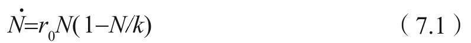

当N接近于0时，r<sub>0</sub>=c<sub>1</sub>c<sub>2</sub>是人口增长的内禀增长率。此时，参数k被视为“承载能力”，或达到均衡状态时的人口规模。当N＜k时，社会生产过剩，人口规模增长。如果N＞k，那么社会生产的粮食不足以维持家庭生存并繁衍生息，导致人口规模减小。

现在回到表示国家资源（S）的微分方程上。我们要强调的是S会随着收入和支出这两个完全相反的过程发生变化。我假设国家从剩余产量中拿走固定比例的产量作为税收。剩余产量率的总量是通过人均生产率和人口总数得出的。因此，税率为c<sub>3</sub>ρ(N)N，其中c<sub>3</sub>表示作为税收被征收的产量在剩余产量总量中的比例。此外，我们假设国家支出与人口规模成正比。这是因为我们认为随着人口规模不断扩张，国家必然要为军队投入更多资源来保护民众并维持治安，为官僚机构投入更多资源来让他们完成征收和管理税收的工作，同时为市政工程投入更多资源（如修建市政建筑、道路和灌溉渠等）。将所有这些过程综合起来，就得出以下关于S的方程：

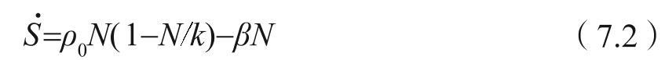

在这个方程式中，ρ<sub>0</sub>=c<sub>1</sub>c<sub>3</sub>是人口密度较低时的人均税率，β是人均国家支出率。

以上分析尚未结束。尽管我们在N和S之间已经建立起一个动态链接，但是这个模式里并没有（从S到N的）反馈效应。假设国家强大对人口动态产生积极影响——具体来说，前面几章的讨论表明国家强大提升了k，即在当时的生态条件以及农业科技发展情况下具有可持续性的人口规模。

因此，承载能力k是S的单调递增函数。然而，k并不能无止境地增长。无论S有多高，到达某一点时，所有可能被开发的土地都会被开垦成耕地，潜在的发展潜力被发掘殆尽，因此考虑到当时农业科技所处的水平，K必然会有一个最大值k<sub>max</sub>。研究这个机制的另外一个角度是：资本投资的回报率也取决于收益递减法则。假设对于k(S)可以建立起以下具体函数：

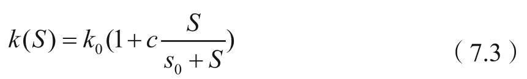

参数k<sub>0</sub>表示没有国家时，社会的承载能力c=k<sub>max</sub>-k<sub>0</sub>。在资金没有限制的情况下，提高k可能获得的最大收益，s<sub>0</sub>代表了k的发展如何取决于S［S=s<sub>0</sub>时，k(S)提升了c/2］。

把等式7.1至等式7.3组合在一起，可以得到完整的人口-财政模型（因为它关注了国家的财政健康，并把它当作主要的结构变量）。这个模型包括六个参数：ρ<sub>0</sub>、β、r、k<sub>0</sub>、c和s<sub>0</sub>，不过我们可以按比例缩放，使N'=N/k<sub>0</sub>且S'=S/ρ<sub>0</sub>，把这六个参数减少到以下四个：β'=β/ρ<sub>0</sub>,r、c和s'=s<sub>0</sub>/ρ<sub>0</sub>。按比例缩放后的方程式如下：

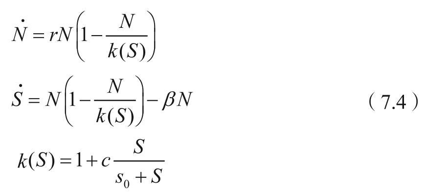

（为了提高此方程式的可读性，我拿掉了等式中的质数S≥0）。此外，我加上了不允许国家负债的条件。

模型动态

图7.1a展示了人口-财政模型的典型动态。在这个模型中，S的初始值为S=0，人口规模的初始值为N=k<sub>0</sub>/2。它预测起初N和S都会增长。随着S的增长，承载力k(S)也会水涨船高，迅速接近上限k<sub>max</sub>。因此，N的增长不会停留在k<sub>0</sub>的水平，而是继续增长，跨过临界值。然而，早在N接近k<sub>max</sub>之前时，人口规模达到特定值N<sub>crit</sub>，国家资源就不再继续积累，S开始加速崩溃，迅速变成0。这意味着k(S)也下降至k<sub>0</sub>，人口规模随之快速下滑。

图7.1b展示了导致S崩溃的运作机制。S的变化率取决于税收和支出这两股相反的力量之间的平衡状况。N较低时，它的增长会推高税收（劳动力队伍不断扩大意味着可以获得更多税收）。国家支出的增长速度落后于税收的增长速度，国家的财政预算盈余不断积累。不过随着N继续增长，税收增长会逐渐停滞，并开始大幅下滑。这是农业劳动力的收益不断递减造成的。然而，国家的支出继续攀升。当人口密度达到N=N<sub>crit</sub>时，税收和支出（短暂地）达到平衡。但不幸的是，人口增长继续迫近承载力k，国家支出与税收之间的缺口开始具有毁灭性而且迅速恶化。因此，国家在年景较好时积累下的资源被迅速消耗。S变成零时，国家无力承担军队和官僚机构的费用，也无力维护基础设施，于是分崩离析。

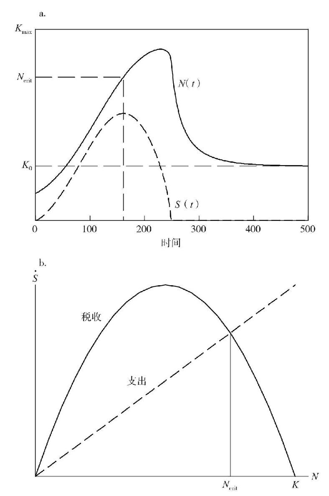

图7.1 （a）人口-财政模型（7.4）的时间动态

（b）税收与支出之间的平衡状况引发的国家资源（）变化模型参数：β=0.25，r=0.02，c=3，s<sub>0</sub>=10

我们就参数对模型动态的影响进行了数值研究，结果表明政治周期的平均时长主要取决于r值，此外β也对它产生了影响，只是效果有限。参数c影响了振荡的幅度，因为它确定了k<sub>max</sub>超出k<sub>0</sub>的幅度。

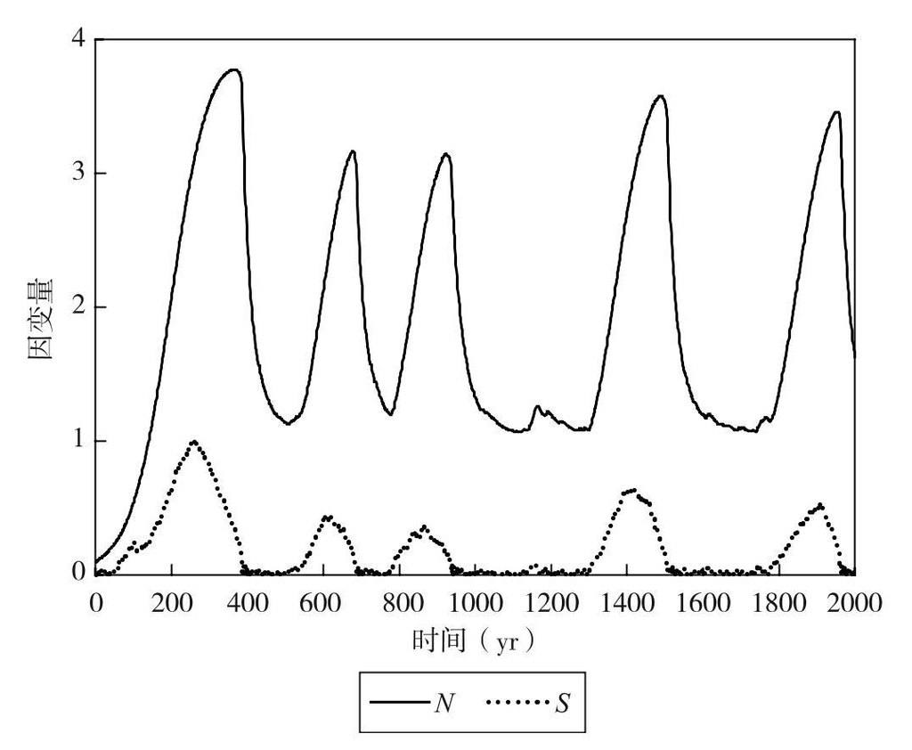

图7.2 随机人口-财政模型的时间动态

参数：β=0.25，r=0.02，c=3，s<sub>0</sub>=10和σ=0.1s<sub>0</sub>

参数s<sub>0</sub>决定了是否会出现振荡：如果振荡值过高，那么k(S)的增长幅度永远不足以启动政治周期。由于N<sub>crit</sub>=1-β，所以参数β确定了导致国家税收低于支出需求的人口规模。最后，由于最主要的决定因素是人口规模需要多长时间增长到N<sub>crit</sub>，所以人口的人均内禀增长率r影响了振幅的时间范围。r的一个合理估算值是0.02yr<sup>-1</sup>（或每年相对增长2%）。要注意的是，r是N接近0时获得的内禀增长率。对于N=k/2前后的典型人口密度来说，这个模型预测了人口的人均内禀增长率每年约为1%，这也是人们研究历史上的短期人口增长时观察到的典型数据。我们采用r的这个估算值进行模型预测时，得出的结果是历史周期大致跨越两至三个世纪（请参见图7.2）。这是通过模型做出的定量预测，我们可以对它进行实证检验。

评估

现在我们来讨论建模过程中对函数形式提出的部分简化假设。我们回顾一下图7.1b，显然对于探讨人口规模和人均剩余产量/人均国家支出之间关系的函数，它的形式细节没有对基本观点产生太多影响。譬如，如果我们不假设人均剩余产量与人口规模呈线性下滑，而是用非线性函数（而不是单调函数）取而代之，那么我们得到的结果不过是以某种方式扭曲了函数表示的抛物线。由于在N=0的起始端和N=k的终止端，税收都必须为零，而且两者之间必然出现最大值，所以曲线的基本形状不会受到影响（即国家的税收先增后降）。同样，支出和人口规模之间的关系可以是非线性的（事实上，支出可能与N建立起加速函数，而这只是因为人口规模增加时需要更多官僚层级来管控社会和征收税费）。然而，需要再次说明的是，支出必然会随着N的增长单调递增，因此人口规模达到一定程度N<sub>crit</sub>时，支出曲线和税收曲线必然会相交，引发上文讨论的国家财政所承担的各种后果。看起来上面的讨论使我们不可避免地得出一个总体结论，即除非可以避免人口规模超过阀值N<sub>crit</sub>，否则国家支出会不可阻挡地增长到入不敷出的水平，国家无法逃避无力偿债的命运。一旦达到这个临界点，提高税率或缩减不必要的开支（如消除宫廷奢靡）至多会在短期内解决一些问题。允许国家举债（即在债务达到最大值之前允许S为负值）同样只是延迟了终将降临的命运而已。

我深信这个结论对农业政权的动态至关重要，但依据这个模型提出的观点并不意味着世界各地的所有国家必将在两三个世纪的时间里分崩离析。不过，建立起明确直观的模型，可以帮助我们考虑没有纳入模型的各种现实特征如何影响这个模型传达出的基本信息。

首先，我要强调的是，这个模型仅适用于工业化前的社会。我们可以想象工业社会（甚至是以信息为基础的经济）可以通过科技创新来扩大生产基础，从而使生产的增长速度领先于人口的增长速度。然而，这种情况不适用于农业社会。传统社会储备了一些科技，可以在人口压力上升的情况下大幅提升产量（Boserup，1966，1981），只是继续提升产量的可能性终究会被消耗殆尽（Wood，1998）。这已经反映在我的假设中，即k(S)的函数最终会饱和。

其次，这个模型忽略了人口-国家体系之外的因素，特别是国家受到严峻的外部军事威胁时，可能会阻碍人口规模增长到粮食产量决定的均衡水平。譬如，我们可以在N的logistic方程（即方程7.1）中增加一个与人口密度无关的死亡项-δN来对这种情景建模。如果δ足够大，那么人口均衡会左移，超过N<sub>crit</sub>，而且在税收超过支出的地区，其政权可以无限延续下去。然而，这种情景可能只会对规模较小的政权产生影响。在地域广阔的帝国，只有边境地区会受到外来军事威胁的影响，其中心区域的人口会不受限制地增长，一直到勉强持续生存的极限。反之，一个国家可能会四处征战，把邻国纳入自己的版图。如果这个社会采取积极的殖民化政策，那么帝国内部承受的人口压力会得到缓解。不过，任何农业帝国都不可能毫无节制地开疆辟土，所以这个机制只是让无法更改的命运来得晚一些而已。

第三，社会可能会选择限制人口增长。由于少生孩子引发的成本是由个体家庭承担的，所以自愿限制家庭规模的情况不太可能是事先的，但人口过剩引发的问题会在整个社会蔓延开来。换言之，自愿限制家庭生育规模的行为表现出集体行动导致的问题的所有特征。然而，这个问题或许并非“无药可救”。此外，在某些条件下，限制家庭规模或许是个人采取的一种理性策略。因此，这是一个取决于特定社会的实证问题：它的社会成员控制家庭规模吗？控制家庭规模是否使人口规模的均衡水平低于N<sub>crit</sub>？

最后，国家或许会强制限制人口增长。只要它占有的资源超过剩余产量，就可以间接达成这个目标。如果它课以重税，使农民家庭纳完税后手中剩下的资源不足以维持农民的生活并养儿育女，那就会导致人口规模下降，并且悖论式的提高政府手中的剩余产量（我们可以在图7.1中观察，N向N<sub>crit</sub>的左侧移动将如何提升财政结余）。看起来这种可能性在历史社会中最具现实性，因为人们不需要假设国家刻意采取了减少人口规模的策略。他们需要做的不过是从民众生产的所有产品中拿走更多充当税收，而如果国家已经接近N<sub>crit</sub>临界点，它们就有强大的激励来这么做。此外，从实证层面看，在绝大多数时候，人们都在指责大多数农业国家拼命压榨从事生产的人口。因此，我们需要建立一个比之前更复杂的模型以深入探讨这种可能性。主要问题在于，国家采取高压政治的机制是什么？换言之，农业国家里由谁采取高压统治？这个问题的答案通常是“精英”。他们要么直接从农民那里征收税收，然后转交国家；要么为官僚和军官提供用来攫取税收的国家机器。无论在哪种情况下，我们都需要给前文建立的基本模型增加更多结构，并且明确地将国家、精英和平民的动态变化作为研究目标。

### 7.2.2 增加阶级结构

我的下一个目标是思考纳入阶级结构会对国家崩溃的理论预测产生什么影响，然后在此基础上进一步拓展上一节建立的理论。为此，我将总人口划分为两个社会经济阶层：平民和精英。本节进行理论推导时很大程度上借鉴了杰克·戈德斯通（1991b）人口结构理论提出的见解。

这个模型的基本结构如下（请参见附录A.3节了解它的推导过程和其他数学方面的详细内容）。它包括三个结构性变量：平民的人数（即农民的人数，P）、精英的人数（E）和累积的国家资源（S）。和基本的人口-财政模型中一样，平民人口的增长导致人均生产率下降。具体来说，我假设每个农民的产量与农民的人口规模构成线性下降函数。为了把产量与人口动态联系起来，我假设平民人口的人均增长率与每位生产者可以获得的资源之间存在线性函数。如果每个农民获得的资源超过一定临界点，那么农民的人口规模会不断扩张。另一方面，如果被国家或精英攫取的资源占比过高，那么农民的人口规模会下降。我在附录中展示了农民把自己创造的所有资源都消耗光时，如何用logistic方程式来描述他们的人口动态。

然而，农民无法把自己生产的所有粮食都占为己有。我在附录中为精英的资源攫取推导出一个模型，其关键要素是精英可以对农民施加的高压统治程度。精英人数（即E）较少时，他们可以采取的高压统治程度（以及由此可以从生产者手中攫取的资源占比）与E直接呈正比。然而，尽管E在不断增长，但贵族可以攫取的资源不可能超过总产出。因此，尽管精英阶层的规模日益扩大，从农民那里攫取的资源比例也越来越高，但他们攫取资源的能力受到收益递减法则的制约，可见精英人数增加时，其人均攫取到的资源会不断减少。

我们对精英人口动态的建模过程与农民人口动态的建模过程相差无几。如果精英阶层人均获得的资源较多，那么精英阶层会通过生儿育女以及从平民中招募人才来扩大自己的规模。如果他们人均获得的资源较少，那么其繁衍后代的行为会减少，死亡率上升，而且流动性下降，导致整个阶层的规模缩水。不过，有一点是显而易见的，即精英家庭维持生活以及繁衍后代所需的资源临界值远远高于平民达到同样目标时所需的资源数量。

和基本模型展示的情况一样，国家资源会根据税收和支出的情况发生变化。在税收侧，我假设从农民手中攫取的资源分给了精英（以租金形式体现）和国家（以税收形式体现）。然而，被攫取的资源中最终进入国库的比例是一个动态量。从农民那里攫取的资源足以维持精英阶层期望的消费水平时，他们会把国家应得的税收转交给国家。然而，随着精英的人数不断增加，所有精英家庭拿到的用于生存和繁衍的资源数量逐日减少，精英会将越来越多的税收装入腰包满足自己的需求。从历史上看，贵族使用各式手法挪用国家税收。首先，他们假称自己生活潦倒，恳求政府免除他们的税收。其次，他们常常把税收据为己有，不上交国家（地主负责收税时就可以采取这种手段）。第三，在政府任职的精英利用多种贪腐手段将国家税收揣入自己及同伙的腰包。以上所有这些情况都造成同样的最终结果，即随着精英阶层日益困顿，从平民那里攫取的资源中最终流向国家的比例越来越小。我假设所有精英家庭先将维持自身生存的必要资源留在手中，然后按固定比例把剩余资源中的一部分转交国家，据此为它们的动态变化建立了模型。

其次，我认为这个模型的推导过程与基本模型的推导过程类似，所以依然假设国家必须雇用精英人群担任政府官员、官僚和教士，那么国家支出将随精英人数呈线性增长。这个观点假定平民人数增长产生的国家支出与精英阶层对国家提出的需求相比可以忽略不计（我们完全可以增加“与平民有关的支出”这个变量，但这么做会使模型复杂化，且不会改变它的主要结果）。

最后，我们需要为S对P和E的人口动态产生的影响建立模型。第7.1节讨论过，S既可以影响社会的生产能力（像基本人口-财政模型展示的那样），也可以对人口率（demographicrate）产生作用。我在附录1中推导了这个模型的两个版本——每个版本分别对应上面提到的一种情况。第一个模型与基本人口-财政模型几乎一模一样：S增长会提升农民人口的承载力。在第二个模型中，我假设存在一个强大的国家使精英阶层保持稳定与和平：精英阶层的内部竞争没有造成严重危害，而且精英的灭绝率很低。然而，如果国家的角色缺失或国家极其羸弱，那么精英阶层的内部冲突加剧，由此提高精英的灭绝率。

这两个模型得出的动态基本相同，因此我主要关注了第二个模型（在这个模型中，S影响了精英的人口结构），并称之为“自私精英”模型，这是因为它假设精英压迫平民时完全不考虑后者的福祉，只有在满足自己的基本需求后才将剩下的税收转交国家。

我们对“自私精英”模型进行数值研究后发现，它可以出现三种动态行为。首先，模型中的参数达到某些值时，精英无法保全自己而走向灭亡。其次，经历了初期的国家兴起和崩溃后，精英和生产者接近均衡水平，并且永远维持在这个状态（请参见图7.3a）。（模型中的参数达到某些值时，国家永远无法建立起来，所以直接进入国家缺失的均衡状态。）这个模型表明，平民人口增长创造出庞大的资源基础时，精英阶层得以迅速扩大规模。在精英阶层的扩张初期，国家规模也与之同步扩大。然而，随着精英人数持续增长，他们维持最低生活水平所需的资源在平民被剥夺的产出中所占的比例越来越高，留给国家的份额开始减少。与此同时，精英对国家的需求在上升，因此到了某个时间点，国家的支出会全面超过收入，随后就像基本模型展示的那样，最终导致国家崩溃。与此同时，精英对农民生产的资源的需求越来越强烈，农民被剥削后手里剩下的资源不足以维持其生存。残酷的压榨导致农民人口下降。国家崩溃后，随之而来的无政府时期通常表现出以下特点：农民受到残酷剥削，精英人群的内部冲突造成极其严重的破坏。结果平民和贵族的人数都会下降，经过一些小幅振荡后接近均衡状态。

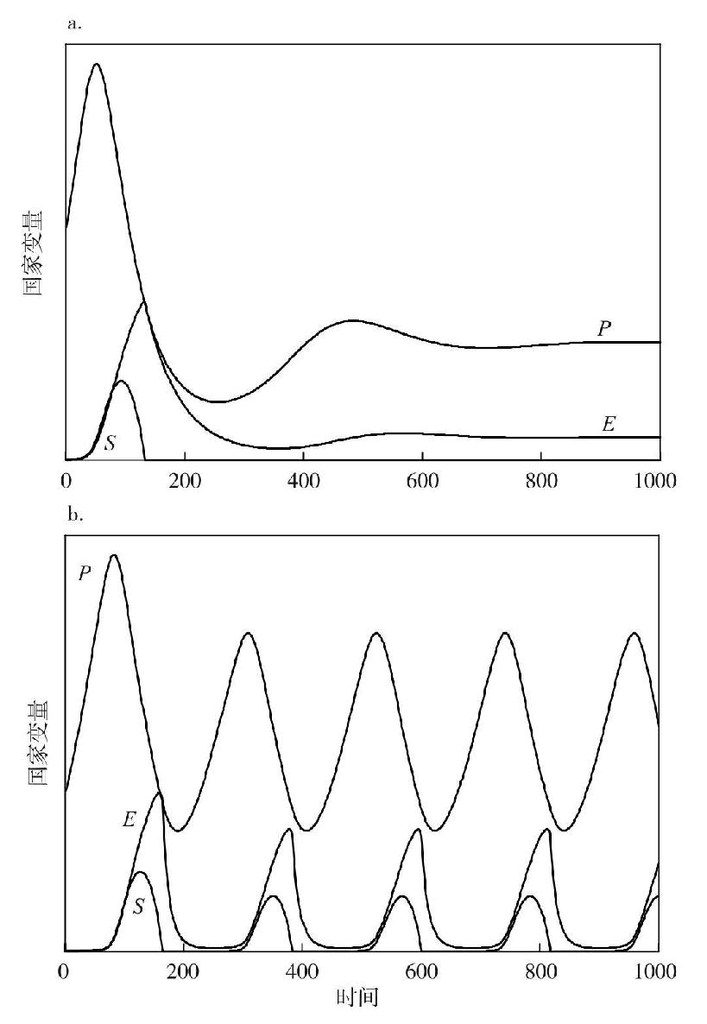

图7.3 “自私精英”模型的动态变化

注：（a）无国家社会中的稳定均衡。它包括的参数为β<sub>1</sub>=δ<sub>1</sub>=0.02，ρ<sub>0</sub>=2，β<sub>2</sub>=0.5，δ<sub>2</sub>=0.025，γ=10，α=0.2。（b）稳定的极限周期。除了δ<sub>2</sub>=0.1以外，其他参数与（a）中完全相同。

“自私精英”模型预测的动态与基本模型展现的典型动态非常相似，唯一的区别在于N的角色现在由E来扮演了。和基本模型的情况一样，尽管模型中的均衡局部稳定，但一旦受到扰动就会启动新一轮国家构建/国家崩溃的周期（这也与基本模型中展示的动态变化非常相似）。

（没有受到扰动时）一个国家构建/崩溃周期结束后出现无国家均衡，是“自私精英”模型中的大多数参数组合起来展现的典型动态，也是阶层结构模型表现出的典型动态（在这个模型中，S影响着社会生产能力）。然而，它的参数达到某些数值时，“自私精英”模型展现出第三类行为，即整个体系经历了“国家构建→崩溃→无政府时期→再次出现国家构建”这一过程周而复始的稳定极限周期（请参见图7.3b）。使整个体系从稳定的无国家均衡状态进入以上循环过程的一种方式是：在国家缺失的情况下精英的死亡率提高。这种变化会使精英迅速相继死亡，最终达到一个足够小的人口规模，为国家资源重新增长创造条件。

“自私精英”模型没有表现出的一类行为是，在有国家的情况下（即S>0），农民和精英之间存在稳定的均衡状态。出现这种行为的原因非常明显，而且它的运行机制与基本人口-财政模型中的运行机制完全相同。如果E处于均衡状态，那么必然为零（精英没有剩余资源可与国家分享）。因此，国家拿不到任何税收，但仍然有国防和行政等支出。

我们可以对这个模型做一个明显的调整，使精英从农民那里攫取资源后必须将固定比例的资源上交国家（而不是从精英用剩的资源中给国家留出一部分），这样在有国家的情况下也达到了均衡状态。进行这种调整并且为模型赋予具有现实意义的参数值后，P和E会接近均衡状态，而S始终保持正值（事实上，S会随着时间的推移增长，但毫无疑问国家总会为手里的剩余资源找到支出用途）。

不过，这个研究结果提出了一个很有意思的问题。如果我们假设精英在极其艰难困顿的时期仍然将很大一部分税收上交国家，那么这种假设的现实性有多强？我们要强调的是，这个模型假设，即使精英的经济状况极度令人绝望，精英人群的规模在不断缩水，他们仍然不愿染指农民向国库上交的税收。在绝大多数农业社会，精英掌管着征收赋税的工作。绝大多数精英可能更倾向于和自己的家庭及宗族团结一致，而不是与整个国家同气相求。因此，我认为这种“无私精英”模型并没有特别务实地描述历史上大多数农业国家的情况。

### 7.2.3 精英周期模型

第7.2.2节描述的模型表明它预测的动态主要取决于我们对精英所做的假设。这种理论研究结果支持了“精英对国家分崩离析发挥了核心作用”这个观点（Goldstone，1991b，参见第7.1节）。

本节将继续探索精英的特点如何影响政权动态。我尤为感兴趣的是游牧民族的精英或从游牧部落成长起来的精英如何与农业国家发生互动。为了简化这些问题，我首先假设平民的数量不会随着时间推移发生变化。不过，我对这个简单模型进行研究后，仍然检验了简化版假设对模型的预测结果产生了什么影响（这是本书惯常采用的研究流程）。

伊本·赫勒敦模型

我根据北非马格利布人在中世纪的情况，为它“量身定制”了第一个模型——伊本·赫勒敦的理论阐明了这个模型的基本概念（下文主要运用文字来描述这个模型，与之对应的方程式收入本书附录）。伊本·赫勒敦式的“世界体系”的动态取决于文明社会与沙漠部落之间的互动（请参照第3.2.1节）。文明地区是国家构建/崩溃重复上演的舞台。居住在当地的平民为社会奠定了生产基础。沙漠是不受国家管控的部落的栖息地。这些部落定期攻占文明地区，并在当地建立统治王朝。因此沙漠部落为文明国家提供了精英阶层（即贵族）。

我在这个模型中假设，平民人口的动态大体上与精英的动态没有关联。虽然朝代不断更迭，但农民和商人始终在生产粮食或开展贸易，而且无论哪个政府当权，他们都要缴纳税款。因此从平民那里攫取的资源数量是恒定的，即R。在王朝成立初期，从平民那里攫取的资源分为两部分：用来支持政府运转的税收（即γR）和用来维持精英生活的租金［即(1-γ)R］。这里假设参数γ保持不变（γ表示进入国库的资源在资源总量中的比例），那么贵族的人均收入为μ=(1-γ)R/E，其中E是当前的贵族人数。

随后我又引入另外两个参数，用μ<sub>0</sub>表示一位贵族维持生活并养儿育女必需的人均收入。换句话说，人均收入低于μ<sub>0</sub>时，精英的人数会下降，而如果μ>μ<sub>0</sub>，那么精英阶层的规模会扩张。引入的第二个参数是μ<sub>min</sub>，即贵族根据自己的处境认为自己需要得到的最低人均收入。这个“最低可接受收入”取决于社会因素，而且在各个社会中的具体数值不尽相同。然而，如果贵族获得的收入无法维系自己的家庭传宗接代，那么他们不可能接受这种收入水平，所以总体来说μ<sub>min</sub>≥μ<sub>0</sub>。伊本·赫勒敦认为随着时间的推移，曾经的部落居民把沙漠里未开化的生活方式抛在脑后，他们的后裔逐渐适应日益奢靡的生活。因此，王朝刚刚成立时，μ<sub>min</sub>这个变量的起点较低（如μ<sub>0</sub>），随后按照一定速度（如每年δ<sub>μ</sub>）持续增长。

正如前文所述，人均收入μ超过μ<sub>0</sub>时，精英人数会增长。精英人数的增长率与μ-μ<sub>0</sub>之差成正比，但不会超过最高增长率r<sub>max</sub>。由于这个模型是针对精英人群采取一夫多妻制的社会“量身打造”的，所以我确定r<sub>max</sub>=0.08yr<sup>-1</sup>比典型的工业化前人口内禀增长率超出3倍。我之所以做出这个假设，是因为穆斯林男性最多可以迎娶4位合法妻子。当然，在伊斯兰社会里，很多身居高位的男性会拥有大量妾室，而且这些妾室的儿子通常也可以作为他的法定继承人。这些做法大大提升了人口增长率。在另一方面，精英阶层中较贫困的人群有能力迎娶的妻子人数达不到法律许可的最高上限。我认为，从总体来看，“4”这个乘数作为伊斯兰社会的参考值较为合理（这种做法在理论建构过程中很常见。我们常常需要确定这个参数及其他参数的变化会对模型的预测结果产生什么影响）。

该模型的下一个核心假设是只要租金带来的人均收入超过最低可接受收入，即(1-γ)R/E>μ<sub>min</sub>，那么国家和精英会和平共处。然而，一旦精英的人数达到临界点，使他们的人均收入低于μ<sub>min</sub>，那么贵族会产生不满情绪，并利用多种常见的手段将部分税收装进自己的腰包（前一节已经讨论过这种情况）。这个模型假设，到了这个阶段，精英窃取的国家税收恰好能够满足他们认为自己需要达到的最低生活水平。如果精英的人数达到R/E>μ<sub>min</sub>的水平，即从平民那里攫取的资源不足以满足所有贵族的需求，即使国家拿不到任何税收，这个模型仍假设μ=R/E。换言之，到了这个阶段，贵族会把从平民那里攫取的所有资源都在自己内部瓜分干净，而国家什么都拿不到。

和之前一样，我们对国家的财政动态建立了模型，其税收情况如上文所述，其支出情况与精英人数成正比。因此，S（即累积的国家资源）的动态与典型的变化轨迹保持一致，即在王朝建立初期，精英人数较少，对物质的需求不高，所以S会增长。然而，到了一定阶段，税收下降至无法支撑国家支出的水平，S开始下降直到变成0。这个时候，模型假设王朝最终被颠覆。由于邻近的沙漠部落已经虎视眈眈，为建立下一个王朝做好准备，所以国家面对外来的征战不堪一击（至少在这个模型里，这一切很快会发生）。图7.4a展示了这个模型预测的典型轨迹。

要注意的是，我特意用经济（或财政）术语来搭建这个模型。不过，我们也可以从集体团结（即群体感）的角度来比较轻松地构建这个模型。譬如，我们可以重新解读S，将它作为精英阶层支持执政王朝所体现的群体感（这里的“执政王朝”指战胜了前一个王朝的部落民族建立并和自己的后代治理的王朝）。那么在王朝建立初期，精英的群体感很强，而且在精英人数达到临界点之前一直居高不下（临界点指人均收入低于最低可接受收入水平的节点）。精英人数达到临界点后，精英内部的竞争加剧，群体感开始削弱。一旦群体感达到特定的临界值，王朝（和国家）逐渐瓦解，并被其他沙漠部落取而代之。这个模型的动态与图7.4a中展示的动态完全相同。

既然我们已经对伊本·赫勒敦模型预测的动态有了一些初步了解，那么现在可以来探究我们推导这个模型时所做的简化假设会对研究结果产生什么影响。或许其中简化程度最高的假设是我们可以忽略平民的动态变化。为了检证这个近似假设的有效性，我建立了另外一个更复杂的伊本·赫勒敦模型，并将阶层结构纳入其中（请参见附录来了解相关方程式）。这个模型预测出的E和S的动态与简化版伊本·赫勒敦模型预测出的动态变化基本没有差别（请参见图7.5a）。此外，它展示了精英周期中的平民动态。我们可以看到平民人口的增长速度因为周期性国家崩溃而有所放缓，但这种影响极小。我们对模型参数进行数值研究后发现，（通过提高参数∈的值）增强精英攫取资源的能力后，平民人口的下降幅度更明显（∈代表被精英攫取的产量在平民的总产量中可以达到的最高比例）。此外，我们下调精英的人均繁衍率时，整个周期被拉长，平民的振荡幅度加剧。这是因为周期拉长意味着平民被精英残酷压榨的时间随之延长，导致平民人口的规模在周期结束时缩水的幅度更大。图7.5b展示了∈=1和r<sub>max</sub>=0.02时简单的变化轨迹。

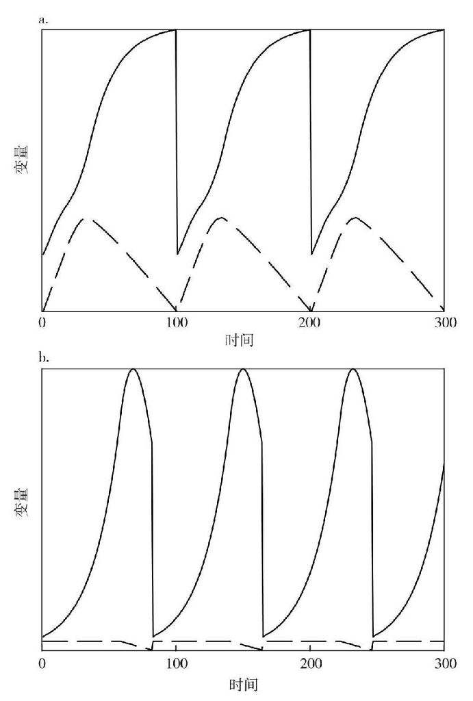

图7.4 （a）伊本·赫勒敦模型展示的动态：其中的变量包括代表精英人数的E（用实线表示）和代表国家累积盈余的S（用虚线表示）。（b）寄生性游牧部落模型展示的动态：其中的变量包括精英人数（用实线表示）和代表精英凝聚力的S（用虚线表示）。

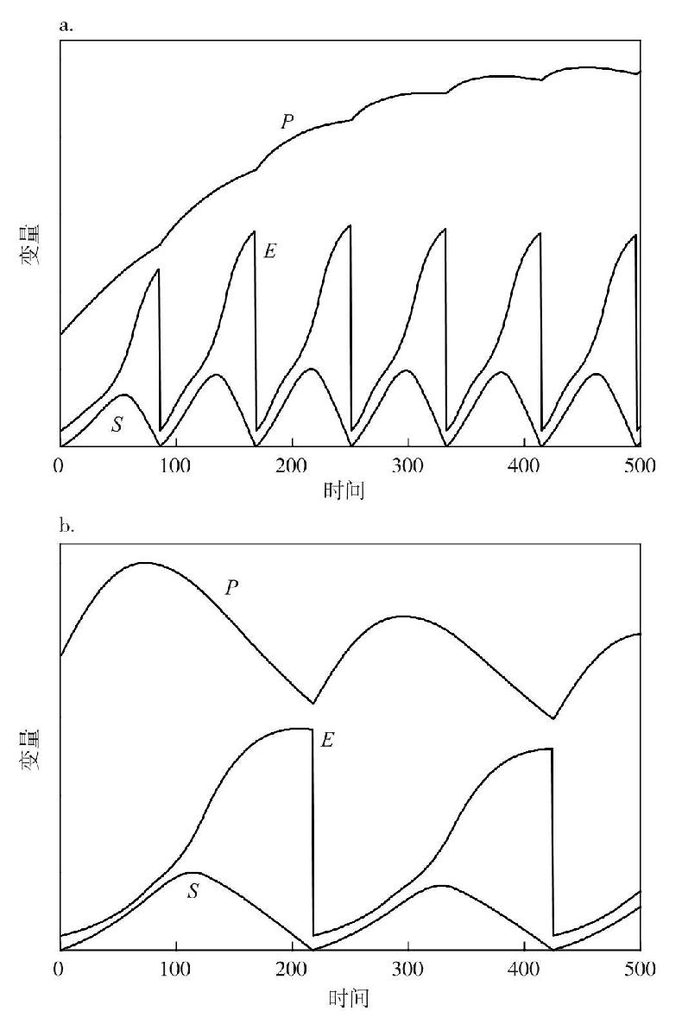

图7.5 纳入阶级结构的伊本·赫勒敦模型展现的动态变化

注：E表示精英人数，S表示国家累积盈余，P表示平民人数。（a）精英繁衍率较高且攫取资源的能力有限时表现出的动态变化。（b）精英繁衍率较低且攫取资源的能力较高时表现出的动态变化。

寄生性游牧民族模型

我采用巴菲尔德（1989）提出并由科拉丁（Kradin，2000，2002）进一步发展起来的概念，针对中国的亚洲内陆边疆建立了最后一个模型。这个模型在很多方面都与伊本·赫勒敦模型表现出相似之处。我再次关注了游牧民族的精英（即不同层级的部落头领及其亲属）所表现出的动态。不过，与马格利布人的情况截然相反的是，在亚洲内陆边疆活动的游牧民族不愿攻占文明国家（即中华帝国），而是勒索他们年年纳贡。

下文用文字描述了这个模型（与其对应的方程式收录在本书附录中）。我们用R指代游牧民族在特定年份从中华帝国榨取的贡品数量（下文将解释R这个变量与模型中其他变量的依存关系）。用E指代精英阶层的人数。因此，精英阶层的人均收入为μ=R/E。对精英人口动态的建模过程与伊本·赫勒敦模型的建立过程几乎没有差别（即精英人口的人均变化率与μ-μ<sub>0</sub>成正比。其中μ<sub>0</sub>指一位精英维持生活并生儿育女的必要收入）。

除了E以外，这个模型的第二个结构变量是“帝国联盟”的S，即处于政权架构顶端的游牧精英的群体感。我假设小规模群体的凝聚力始终保持在高位——这是游牧生活的典型表现——因此我们不需要为此建立清晰明确的模型。下文对帝国联盟崛起的整个过程进行了概念化阐述。起初，大草原被多个“部落”（即游牧民族的酋邦）分而治之。其中一个与众不同的部落凭借自己得天独厚的地理优势和富有号召力的领袖，或仅仅是因为运势奇佳，提升了自己从草原边界另一侧的农业政权夺取战利品或贡品的能力。部落首领利用自己从安居乐业的务农者那里攫取的货物，招募到越来越多的战士追随他，由此启动一个积极的反馈动态：追随部落首领的战士越来越多，首领就有能力使周围的游牧部落臣服于他，并将后者纳入自己日益壮大的草原军队，进而从农业国家攫取更多战利品/贡品，然后再吸引更多战士归附他，如此周而复始，最终形成一个草原帝国联盟。这个自催化过程会一直延续，直至帝国联盟从农业国家攫取的资源达到极限（我们要记住，精明的游牧民族不想彻底占领农业国，而是在后者可以承受的范围内不断压榨它来获取资源）。

具体而言，我假设贡品的数量（即R）与E呈非线性函数：首先，它随着E的上升加速增加，但随后接近上层渐进线。R还与帝国联盟层面的凝聚力S成正比。开始S的数值较高，只要精英阶层人均获得的贡品数量非常充足，那么S会保持恒定（即=0）。然而，如果人均收入μ下降到某个在人们看来比较适宜的最低水平（即μ<sub>min</sub>），那么精英阶层的内部竞争会加剧，逐渐侵蚀群体感，S随之下降。

### 7.2.4 中国的王朝循环模型

历史学家很早就注意到王朝循环在中国历史上的重要性（Meskill，1965）。在王朝循环的初始阶段，和平和繁荣是社会的主基调，人口规模往往会扩大。然而，这个王朝终究会变得衰老羸弱，腐败滋生，社会骚乱日益频繁，直至整个王朝最终覆灭。在随后的无政府时期，人口数量通常会下降。学界曾经就王朝循环提出两个相似的模型：一个模型是由经济学家厄舍（Dan Usher，1989）提出的，另一个是经济学家朱敬一和人口统计学家罗纳德·李（Chu and Lee，1994）提出的。由于厄舍的模型极其复杂（包括20个方程式），所以本文不对它进行讨论，而是采用朱敬一和罗纳德·李提出的相对简单的模型。

朱敬一和罗纳德·李提出的模型中包括三个阶级：出产粮食并纳税的农民；偷盗粮食并与农民和统治者相抗衡的盗匪；向农民征税、追捕盗匪且自私自利的统治者。在农业生产中投入更多劳动力会提高粮食产量，但这种做法的收益不断递减。农民面对的一个选择是：他们可以永远当农民从事农业生产，也可以变成盗匪靠盗抢谋生。这种职业选择基于对盗匪和农民各自的期望效用进行比较后得出的结果。我们可以通过人们得到的粮食和生存概率来建立效用函数。朱敬一和罗纳德·李表示人口规模扩大的影响之一是加快了农民变成盗匪的速度。盗匪的规模扩大会产生两个后果。首先，农民的人数减少，粮食产量也随之下降，结果推高了儿童死亡率，导致人口规模下降。盗匪的人数增加还提高了成年人的死亡风险。其次，盗匪的社会地位提升增加了他们的生存概率，导致这个群体的规模持续扩大。到了某个阶段，盗匪的势力压倒了政府的势力，王朝就此覆灭。

评估

厄舍的模型以及朱敬一和罗纳德·李的模型都以理性选择论为基础，即农民会认真权衡继续当农民还是变成绿林人士的效用，随后做出适宜的职业选择。原则上，这是一个很有意思且可能非常奏效的方法，我们可以用它来构建理论并进行实证预测。然而，这些学者选择的效用函数的本质令人困扰：从本质上说，平民的效用等于预期收入（以粮食产量为计量单位）乘以平民的生存概率得出的结果。我对此的感受是，这些经济学家选择的方法过于偏重经济学，需要采用更复杂精细的社会学研究方法，而且这些方法应建立在人们集体秉承的规范和做出的决定之上。

对这两个模型更严肃的批评意见在于：它们将研究重点放在平民叛乱上，认为它是导致国家覆灭的主要机制。然而，戈德斯通（1991b）提出了一个很有说服力的观点，并用近代早期国家崩溃的实证案例充分佐证了人民起义本身通常不会导致国家覆灭。农民手头武器匮乏，几乎没有接受过军事培训，组织涣散，而且在团结一致的精英人群支持国家的情况下，农民几乎没有机会反抗国家的高压政治体制。戈德斯通认为，国家崩溃是由精英内部的派系斗争造成的，这给平民叛乱打开了口子（此外，就连农民起义往往也是由精英领导的）。因此，当前的理论表眀，在某种意义上，民众的不满情绪是次要因素。我们应该从精英动态入手寻找导致国家覆灭的主要机制。

尽管存在以上批评意见，但我深信厄舍以及朱敬一和罗纳德·李提出的模型对构建国家覆灭理论做出了重要贡献。需要强调的是，在这两个模型里，导致国家覆灭的潜在力量都是人口增长。它导致每个人的收入逐步减少，最终除了维持最低生存水平所需的资源以外，剩下的资源不足以供养统治阶级（Usher，1989）。厄舍以及朱敬一和罗纳德·李并没有细化自己的模型来帮助我们确定这些模型可以预测哪些类别的长期动态。不过，本书第7.2.1节提出的基本模型可以做到这一点。它还表明模型中的参数达到某些值时，模型展示的动态表现出以下特点：国家构建-覆灭的周期会往复循环，且其时长大约为2~3个世纪（或许其循环过程并不那么规律）。

此外，我们可以观察是否能从理性选择的角度找到关于精英动态的洞见，这个角度非常有意思。因此，如果我们将“职业选择”模块应用于经济形势恶化时的精英，而不是应用于农民（即精英是努力争取一官半职还是揭竿起义？），那么会给我们带来很多启发。不过，这种方法会使我们的研究远远超出本书的研究目标，因此我把它留待今后的研究中使用。

### 7.2.5 理论见解的总结

本节探讨的人口-结构模型提供了两个一般性见解。首先，由于劳动力的收益递减，农业社会的人口增长必然会导致人均收入逐步下降。最终，农民生产的剩余部分不足以维持国家正常运转。只有在人口问题始终低于临界值，国家支出与收入相匹配时，才可以避免国家破产并崩溃。

其次，精英在国家动态中发挥着核心作用。精英可以使留在平民手中的资源不足以维持他们的基本生存，从而限制平民的人口增长。不过看起来并不存在一个普遍机制能限制精英人口的增长。在某些特殊情况下，国家机器或许可以在不受精英左右的情况下正常运转，同时提供必要的强制力以限制精英阶层的规模。在其他情况下，精英会自行决定限制本阶层的规模。但我认为，在绝大多数农业社会中，精英阶层的规模会不断扩大，并超出具有可持续性的规模水平，导致国家倾覆。

精英的特质对国家成形/覆灭周期的时长和振荡幅度产生了显著的影响。看起来有两个参数最为重要：精英繁殖率和攫取资源的能力。精英的繁殖率较高且攫取资源的能力较差时，会加快伊本·赫勒敦式周期，其时长约为一个世纪，同时平民人数的振荡幅度较为缓和。精英的繁殖率较低，接近平民的繁殖率时，会拉长整个周期。精英攫取资源的能力增强会导致平民人口急剧下降。周期延长还会加剧平民人数的振荡幅度，这是因为分权阶段被拉长会进一步压低平民的规模。因此，在“自私精英”模型中，精英的繁殖率较低，攫取资源的能力较强，它展示的平民人口动态与人口-财政基本模型中的人口动态在周期时长和振荡幅度上都非常相似。

要注意的是，在所有模型中，我都假设精英是通过繁衍后代来充实本阶层的。当然，在真实社会中，精英阶层可能通过两种途径扩大自己的规模：现有精英家庭生儿育女；平民阶层通过社会流动进入上层社会。我研究了将精英培养机制引入模型后产生的影响，发现这并没有改变从我的理论中得出的定性观点。从本质上说，以上动态取决于精英人群的扩张速度，而到底哪些机制促成这种扩张并不重要。

我们可以用多种方式拓展上文讨论的简单模型。譬如，如果用戈德斯通理论中的术语重新定义朱敬一和罗纳德·李模型中的变量，那会非常有意思。模型中的三个结构变量为平民人数、精英人数以及异见精英人数（“异见精英”又称“反精英”）。另外一个有趣的方向是拓展变量清单，不仅将特定阶层的具体人数纳入这份清单，而且追踪每个阶层中的个体平均积累的资源。这个变量与绝大多数人口-结构模型中的显式变量基本相当。最近，马尔可夫及其合著者针对这个问题建立了相应的模型（Malkov et al.，2000；Malkov and Sergeev，2002）。

本节需要探讨的最后一个问题与研究中使用的术语有关。我们应该如何称呼本节建立的一整套人口-结构模型所预测的动态？模型预测会出现跨越1~3个世纪极为漫长的振荡，它们的具体时长取决于模型的结构和参数值。这些动态的特点体现在两个阶段：政治稳定程度极高的集权阶段；政治动荡极度剧烈的分权阶段。当国家羸弱不堪或国家的角色完全缺失时，分权阶段可以涵盖多个时期，而且不一定会走向集权阶段，因此以上模型预测的振荡不一定表现出强烈的周期性。

很多学者对跨越数个世纪的长期摇摆或波动有过评论。简单举几个例子，卡梅伦（Cameron，1989）称它们为“逻辑斯蒂”（logistics），布罗代尔（Braudel，1988）将它们称为“长期趋势”，费希尔（Fisher，1996）将它们称作“大波动”。我希望将“逻辑斯蒂”这个术语留给logistic方程，这是本书探讨的很多模型的基本构成要素。logistic模型是一个一阶模型，无法展现人口-结构模型预测的二阶振荡。因此，把这些周期称作“逻辑斯蒂”不会彻底消除人们的困惑。“长期趋势”这个术语更完善，因为“长期”包含的一个意义是指以世纪为时标的极其长期的变化。不过“趋势”往往指单调地上升或下降，而人口-结构模型预测的动态包含了上下摆动。为此，我建议将这些动态描述为“长周期”或“长期波动”。如果我们希望强调这些动态的准周期性，那么可以采用第一个术语；如果希望强调它上下摆动的模式没有规律，那么可以采用第二个术语（这两种动态都在模型的预测范围内，具体得出哪种动态取决于与对模型所做的结构性假设）。我还会进一步区分出另外一类周期，即“精英周期”，在这种周期里，总体人口变化不大，但绝大多数行动是由精英互动引发的。

## 7.3 实证应用

### 7.3.1 近代早期国家的周期性崩溃

戈德斯通（1991b）提出的人口-结构理论对人口增长、通胀率、国家财政困境、精英的内部竞争以及民怨等变量之间的相互关系做了详尽的定量预测。因此，我们可以研究历史记载来确定各种国家崩溃的案例中是否存在所假设的关系，从而对这个理论进行实证检验。戈德斯通正是采取这种方法，选择四个历史案例进行了详细的分析，即英国革命、法国革命、17世纪奥斯曼危机（Ottoman crisis）和中国明清两朝之间的朝代更迭（他还将这几个案例与其他几个近代早期的政权进行比较，只是分析的详细程度略低）。我将研究重点放在了17世纪的英国革命，因为它记录各种动态变量的数据库最为完善。

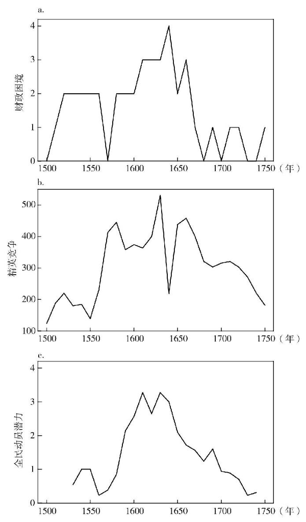

图7.6 （a）国家财政困难水平，其衡量尺度从0（表示收入和信贷充足）至4（完全破产）分为不同等级（数据来源于Goldstone，1991b，图4）。（b）用牛津大学招生人数来衡量的精英竞争强度（Stone，1974，表1A）。（c）全民动员潜力（采用任意尺度）（数据来源于Goldstone，1991b，图4）。

戈德斯通国家崩溃论的最后一个要素是普通大众的全民动员潜力（mass mobilization potential，MMP）。城镇工人和艺术家因为居住在权力中心附近而与全民动员潜力最为相关（特别是首都的工人和艺术家）。戈德斯通建议将三个可测算的要素纳入与全民动员潜力相关的研究。首先，我们可以测算实际工资的动态变化对城市人口造成痛苦的严重程度（譬如，用可购买的粮食数量表示平均劳动工资）。其次，年龄结构年轻化会提高群体动员潜力。第三，城市发展会吸引贫困的青年男性聚集到城市里，从而在贫困程度不断加深引发民众不满时，发挥至关重要的乘数作用，放大民众的愤懑。戈德斯通提出了以下方程式，将这三个机制产生的影响一并纳入全民动员潜力的衡量方式中。

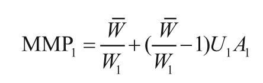

在这个方程式里，W<sub>t</sub>表示第t个10年的实际工资，表示1500年至1750年间的实际平均工资。当时的实际工资与长期平均工资的比值越低，/W<sub>t</sub>的比率就会越高。第二项反映出城镇化与年龄结构的互动效应。戈德斯通将U<sub>t</sub>定义为伦敦在某个10年内的增长与之前20年的增长的加权平均值，将A<sub>t</sub>定义为10~29岁年龄段的人口数量与30岁以上人口数量的比值。因此，第二项表示如果W<sub>t</sub>＜，那么U<sub>t</sub>和A<sub>t</sub>会放大W<sub>t</sub>产生的效应，否则对全民动员潜力的影响有限。图7.6c展示了对1530年至1750年英国全民动员潜力的估算结果。

总之，英国革命的案例为戈德斯通的人口-结构理论提供了相当充分的实证支撑。这次革命的三个要素为：国家陷入财政危机；精英阶层内部存在尖锐的竞争和派系斗争；有一大批对王室不满的民众可以被议会领袖动员起来反对伦敦的保皇派。对这三个过程的测算结果表明，它们在16世纪下半叶和17世纪初不断加剧，最终在1640年达到巅峰（请参见图7.6）。

### 7.3.2 大波动

如前文强调的那样，人口-结构理论（Goldstone，1991b）的价值在于它详尽地分析了重要社会要素之间的相互关系如何调和了人口增长对国家稳定（或动荡）造成的影响。戈德斯通收集了海量关于近代早期欧洲和亚洲国家崩溃的定量材料，为他的理论奠定了坚实的实证基础。然而，他的理论并不完整：尽管人口动态对国家稳定产生的影响已经非常清晰地记录在案，但国家稳定对人口的反馈效应却鲜有记录。在戈德斯通的理论中，人口动态是一个外生变量。

历史学家大卫·哈克特·费希尔（Fischer，1996）提出的模型更加完整地描述了人口数量与社会政治稳定之间的相互作用（他是用文字描述的这个模型）。费希尔提出，在公元1200年至2000年间，西欧经历了四次社会经济变革的“大波动”（他并不是第一个注意到这些波动的学者，我会在第8章开篇处再次探讨这个问题）。这些长期动态体现在价格变动的历史上（请参见图7.7）。在价格达到均衡水平的各个时期之间（基本上为文艺复兴时期、启蒙运动时期和维多利亚时期），穿插着通货膨胀迅速恶化的时期（如13世纪、16世纪、18世纪和20世纪的“价格革命”）。费希尔认为价格变动与一整套社会变量相关。价格达到均衡水平的时期表现出以下特点：经济持续繁荣，艺术蓬勃发展，充满乐观情绪的意识形态深入人心。价格革命之后的时期则表现出以下特点：民众普遍陷入困顿，政界动荡不安，社会秩序混乱，文化界的焦虑情绪不断加深（Fischer，1996，第237页）。

费希尔（1996，第246—251页）对这种波动模式的解释可以归纳如下。在价格均衡期的最后阶段，物质条件不断改善，社会稳定程度逐日提高，文化界对前途的展望一片光明。民众对此做出的回应是提早结婚并生育更多子女。人口规模由此开始扩大。需求总量的增长速度超过供给的增长速度，价格水平（特别是粮食和燃料的价格）开始攀升。这些变化最终为贫困日益深重创造出条件；导致社会关系日趋紧张和阶层冲突加剧。公共收入的增长速度低于支出的增长速度，国家几近破产。文化界的情绪发生转变；开始出现社会悲观主义。社会环境的变化对青年人的冲击尤为强烈。他们发现自己很难找到理想的工作或者组建家庭。最终出现一个触发事件（或通常是多个事件相结合）迅速引爆严重的危机，导致政治动荡和社会冲突迟迟不能平息，在相当长的时间里经济衰落，人口萎缩，并且文化绝望情绪盛行。这种普遍性危机释放了压力，经济趋势开始逆向而动。需求下降，物价走低，实际工资开始上升（因为此时劳动力变得稀缺）。经过一段滞后时间后，新的均衡期逐渐孕育成形，文化氛围再次变得正面积极。人口开始增长，新的周期就此启动。

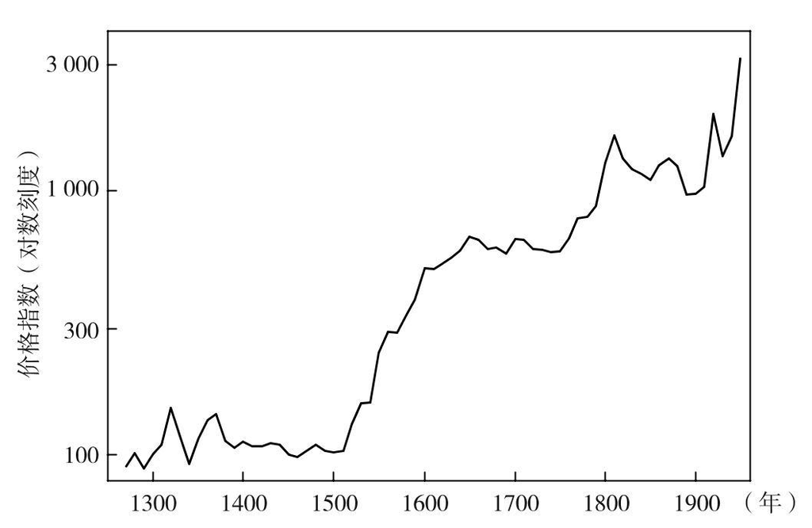

图7.7 消费品价格指数

注：这里所说的消费品包括粮食、酒饮、燃料和衣服。本图描绘了每10年的平均值。

资料来源：Phelps-Brown and Hopkins，1956，Appendix B。

费希尔收集了数量庞大的计量历史学材料，如人口变化，粮食、牛和工业品的价格，贵金属的进口率，实际工资，租金和利率等，甚至包括犯罪、私生子和酒类消费率等方面的材料。随后，他利用这一系列定量数据描绘了西欧在上一个千年里出现的四大波动中的主要阶段（即价格革命、危机和价格均衡）。

人们对费希尔著作的回应大体上比较消极（如Krugman，1997；de Vries，1998；Morgan，1999；Munro，1999）。评论家批判了费希尔对经典通货膨胀理论的讽刺，认为他缺乏具有说服力的数学模型，而且未能区分工业革命前和工业革命后的社会。这些批评意见非常中肯，但我认为绝大多数评论家都认同的一点是，费希尔在努力尝试着从上一个千年的欧洲史里找到至关重要的一般性模式（本书附录表明，费希尔蜻蜓点水般地指出古代和东亚存在着一些看起来非常相似的模式）。

此外，费希尔的描述和解释模型大体上符合人口-结构理论的内容。因此，戈德斯通对于近代早期（即17世纪至19世纪期间）国家崩溃提出的波动论与费希尔描述的第二次和第三次波动中的危机阶段遥相呼应。此外，需要强调的是这三次完整的浪潮持续的时间与第7.2.1节中人口-财政模型的理论预测结果完全匹配（这三次浪潮分别持续了三个世纪、三个世纪和两个世纪）。因此，我认为，本章提出的模型至少可以弥补费希尔著作中的一个不足之处，即缺少清晰明确的数学理论。

### 7.3.3 黑死病暴发之后

在14世纪中期，鼠疫（即“黑死病”）暴发并肆虐，导致西亚欧非国家的社会、经济和政治结构受到严重扰乱。鼠疫产生的首要影响是导致很多国家的人口减少三分之一至一半。因此，我们可以将这种扰动视为一个“自然实验”，并在“实验”中将人口数量作为一个重要的解释变量来检验各种理论。有意思的是，不同社会受到黑死病的冲击后走上了完全迥异的社会轨道。因此，解释各个社会的结构特征如何促使它们在黑死病后走上这些轨道，成为比较历史学研究的一个重要目标。布伦纳论战（Aston and Philpin，1985）中讨论的很多话题都与这个问题息息相关。

最近博尔施（Stuart Borsch，2001）发表的一篇博士论文对黑死病暴发之后的埃及和英格兰进行了很有意思的比较。初期黑死病的肆虐和随后暴发的瘟疫使这两个地区几乎一半的人口死于非命。在英格兰，工资上涨，租金和粮食价格直线下滑，失业率下降，人均收入上升，经济在1500年之前全面复苏。与此形成鲜明对比的是，埃及人口减少产生的后果几乎完全相反。埃及的工资水平下滑，土地租金和粮食价格上涨，失业水平攀升。到1500年时几乎看不到任何经济复苏的迹象：农业产量在1350年至1500年间下降了68%。因此，一个社会（即英格兰）以典型的马尔萨斯-李嘉图方式对人口减少做出回应（不过这种回应仍然经历了一个多世纪的时间。下文会详细讨论这个问题），而另一个社会（即埃及）以完全相反的方式做出了回应。

博尔施尝试着用几个相关因素来解释为何人口减少在这两个国家造成的结果迥然不同，并重点关注了两者在土地所有制上的差异，将它作为主要的解释因素。在1250年至1517年间，统治埃及的是被称为“马穆鲁克”（Mamluk）的专业军队。马穆鲁克是由“奴隶骑兵”组成的，“奴隶”指通过意大利掮客从高加索地区购买的基督教或异教徒子女。马穆鲁克的土地占有制与西欧的体制差别很大。在马穆鲁克的体制下，与房地产和本地乡村社区息息相关的个体土地拥有者并不是一个松散的群体，而是组成一个统一的组织，经常共同进退来保障自己在乡村的利益。黑死病暴发后，马穆鲁克试图利用自己强大的集体力量从大幅缩水的农村人口身上攫取和过去等量的资源，加重了农民个体受到的剥削（这与“自私精英”模型预测的动态非常相似）。

在英格兰，精英也试图走上这条道路。农民受到严酷压榨是他们在14世纪末和15世纪初频繁起义的主要原因。然而，正如博尔施所说，贵族和农民之间的斗争并不是在战场上决出胜负（只要武器精良的骑士始终团结一致，农民暴徒就永远不可能有机会战胜他们），而是通过农民群体一致用脚投票来分出高下。只要租金或工资条件对农民不利，他们宁愿放弃地产。最终妄图采取集体行动的土地所有人以失败告终，农民的需求会缓慢但明确地得到满足。随着租金水平下滑，农村的工资水平上升，按照惯例征收的费用和罚款被废除，农民收入增加，为启动另一个经济和人口持续增长的时期创造了条件。

对博尔施的观点表示反对的学者可能会指出埃及社会和英格兰社会在其他很多方面也存在着差异。博尔施面对这种批评意见做出了精彩的回应：我们可以进行另外一项比较研究，但这次研究针对的是公元2世纪末安东尼瘟疫暴发后埃及的处境。当时人口规模剧烈下降，使纳税人群缩水了三分之一。然而，在罗马统治时期的埃及，其土地占有制更接近于中世纪英格兰的土地占有制，而不是马穆鲁克统治下的埃及采取的土地占有制。因此，罗马统治时期的埃及遭受瘟疫的巨大冲击后相对比较迅速地实现了复苏。总体来说，其社会发展轨迹与英格兰在黑死病后的发展轨迹比较接近。

评估

我认为博尔施构建并维护的观点很有说服力。这项研究也有力地展示了比较研究法在历史社会学中具有的优势。关于布伦纳论战中讨论的西欧（即英格兰和法国）和中欧（即普鲁士、波兰和波希米亚）在经历了黑死病后走上不同社会发展轨道的案例，博尔施补充了两个“数据点”：即埃及分别遭受黑死病和安东尼瘟疫冲击后的情况。我们希望最终能获取几十个这样的数据点来进行统计学分析。开展形式上的统计元分析能够有效地平息批评者的反对意见。

然而，我希望根据人口-结构模型对博尔施的观点再补充一个元素，特别是让我们回忆“自私精英”模型的研究结论，它预测人口下降期具有以下特点：精英/农民人口比较高，随之提高了农民的被剥削率。然而，各种相关过程结合起来，导致精英阶层缩水（这些过程包括经济困境导致贵族堕入农民阶级，繁殖率下降并且内战推高死亡率）。这一切都是英格兰在玫瑰战争末期的真实经历。随着精英人数下降到足够低的水平，农民受到的剥削得到缓解，他们的人均消费率开始上升，下一个长期周期的启动条件逐步成形。

然而在埃及，马穆鲁克仍然继续通过外部渠道招募成员（要注意马穆鲁克的子女本身并不会变成马穆鲁克）。因此，尽管农民人口在下降，但马穆鲁克的规模却不会缩水，精英/农民人口比不会随着时间的推移下降。因此，马穆鲁克统治下的埃及陷入人口较少，精英/农民人口比较高并且农民受到残酷压榨的均衡中。显然，这种恶性均衡即使受到内部扰动时也会保持稳定，只有受到外来力量的冲击时才会被打破（在本案例中，它遭受的外来力量指1517年奥斯曼帝国推翻马穆鲁克王朝而占领埃及）。

有意思的是，我们对英格兰和法国受到瘟疫冲击后的社会发展轨迹进行比较后，为这种情景提供了更多证据。我们要强调的是，与法国相比，英格兰的经济和人口增长被延缓了约半个世纪（会在第9.1.2节讨论这个问题）。“英格兰的贵族阶层利用百年战争引发的动乱，牺牲了法国的利益来解决自己遇到的部分困难（至少能暂时性实现这个目标）”，所以英格兰的复苏过程可能被耽搁了（Bois，1985，第113页）。一旦英格兰被法国赶出欧洲大陆，它马上进入内战时期（即1455年至1485年的玫瑰战争）。英格兰贵族的人数全面下降后，英格兰经济才开始重新增长。

## 7.4 总结

●由于农业中的劳动力收益递减，所以农业社会的人口增长导致人均产量逐步下降。国家可以获得的剩余产出不断缩水，最终无法满足国家的需求。因此毫无节制的人口增长会导致执政政权的财政破产。

●国家崩溃以及随后出现的社会政治动荡对人口率（包括出生率、死亡率和迁徙率）以及社会的生产能力都产生了负面影响。因此，国家崩溃之后接踵而来的往往是人口下滑期。

●我们对人口动态及国家财政健康状况之间的相互作用建立了一个简单的数学模型。它预测国家构建和人口增长后会出现国家崩溃和人口下降的情景，如此周而复始。当参数值处于合理范围内，这个人口-财政模型预测每隔两三个世纪就会出现国家崩溃，但并不一定总是如此规律。

●本章建立了一个更加复杂的模型分别追踪平民人群和精英人群的动态，它预测得出的动态与前一个模型非常相似（即国家崩溃会周期性出现）。平民人口增长推动精英阶层扩张，而且在国家成立初期增强了国家实力。然而，随着精英群体不断扩大，他们为了满足自己的需求，将越来越多从农民那里攫取的产品占为己有。国家收入下降，而支出仍然持续上升，最终导致国家破产。

●我建立了两个模型重点研究游牧精英与农业国家之间的政治动态。伊本·赫勒敦模型探讨了游牧部落周期性攻占农业国家并建立王朝统治的情况。寄生性游牧部落模型解释的是游牧部落并不攻占农业国，而是强迫它向自己纳贡的情况。在这两种情况下，这两个模型所预测的政体构建-崩溃周期要比人口-财政模型及其纳入阶层结构后的变体所预测的周期短一些（前者的时长约为一个世纪左右）。

●我简要评估了用来解释中国历史上的王朝周期的两个经济模型。它们解释中国王朝颠覆时采用的基本逻辑也遵循了马尔萨斯-李嘉图学说，但比我建立的模型复杂得多。

●戈德斯通（1991b）用结构-人口理论解释了近代早期国家崩溃的原因。他假定人口增长是导致国家崩溃的首要原因。然而，要强调的是，在这个理论里（以及我建立的模型中），人口动态并不会直接导致国家崩溃，这一点至关重要。相反，人口增长使国家陷入财政困境，加剧精英内部的竞争和派系斗争，并且提升了平民百姓的动员潜力，间接导致政治动荡。我回顾了戈德斯通研究的一个案例——英国革命，因为这个案例有极其完备的计量历史学数据库。这些数据充分印证了结构-人口模型做出的定性预测。

●最后，我简要回顾了费希尔（1996）对四次“大波动”提出的理论和相关数据。这四次“大波动”描绘了12世纪至20世纪期间，西欧社会经济经历的动态变化。我得出的结论与前面相同，即费希尔的观点和分析与本章建立的理论基本吻合。

●本章建立的各个模型可以得出多种动态，具体情况取决于对它们所做的结构假设和赋予的参数值。振荡幅度可以是规则的，也可以极不规则。这些振荡跨越的时期通常较长，但其范围在一个世纪至三个世纪之间。平民人口的变化可能非常剧烈，也可能极其温和（如在“精英周期”中，平民人口变化不大）。不过，这些模型得出的一个一般性结论是，农业国家会在几个世纪的时间范围内表现出不稳定和振荡的特点。我建议将这种动态称作“长周期”或“长期波动”。

# 第8章 人口数量的长周期

## 8.1 前言

人口-结构理论做出的一个重大预测是农业国家的人口数量会经历缓慢的振荡，它的整个周期大致跨越两三个世纪（详情请参见第7章）。<sup>[1]</sup>我们认为这些“长周期”不一定极为规律。然而，这个理论明确了这些动态应该具有二阶性。第2.1.4节引入了“过程阶数”（process order）的概念。下文将进一步对其进行形式化分析以获取它的人口动态。不过用非技术语言来说，我认为人口振荡的上升和下降阶段应该发生在几代人的时间范围里。

西米昂（François Simiand，1932）、阿贝尔（Wilhelm Abel，1966）、波斯坦（Michael Postan，1973）和拉杜里（Emmanuel Le Roy Ladurie，1974）描述了西欧社会经济史和人口学历史中的长期波动（另请参见Braudel，1988；Fischer，1996）。最近涅费多夫（1999，2002a）展示的数据表明，亚洲的很多大区域（如中国、中东和印度）也出现过长周期。

这些学者研究人口波动时采用的数据多半不完整，不过近年来学界已经汇编并发表了不少长度合理的数据序列。这些进展使我们得以运用时间序列分析的形式方法来检验人口-结构理论的预测，从而对人口数量长期波动的周期性和过程阶数等特征进行实证估算。

[1] 要强调的是，本章不会探讨游牧社会或在游牧精英掌控下的社会。相关研究的预测表明这些社会的振荡时间较短（请参见第7.2.3节）。

## 8.2 人口动态的“规模”和“阶”

最近人口生态学家在非人类生物种群动态的建模、分析和解释方面取得了重大进展。我在《复杂的种群动态》（Complex Population Dynamics）中回顾了这些进展。我们是否可能借用种群生态学家采用的部分技巧和见解来研究人类的种群动态？当然，对人类繁衍、死亡和迁移产生影响的一系列具体机制应该完全不同于人们研究动物后总结出的相关机制。与人类相关的机制多半在本质上涉及经济学和社会学，而且看起来某些生态学模型完全不适用于研究人类族群，如让人类在“捕食者-猎物模型”中扮演猎物的角色。但另一方面，只要我们不掉进生物主义的陷阱，不要试图用纯粹的生物术语来解释所有事物，那么会发现很多生物学模型对于我们理解历史上的人类种群和史前人类种群息息相关，如与资源-消费者互动或疾病-宿主互动有关的模型。这里值得强调的一个重要问题是，种群动力学家已经开发出一系列通用方法来对种群体系中的时间序列数据进行非线性建模。这些方法不预设任何可能或不可能适用于人类种群的具体生态学模型，而是为我们提供了许多工具来量化种群数量随时间波动的实证模式。

我在第2.1.4节中引入了“过程阶数”的概念。事实证明，这个概念对于研究非人类生物的种群动态极有价值（Turchin，2003）。然而，尽管“阶”在微分方程中是一个很容易界定的特性（我正是在这个背景下将它引入第2.1.4节的分析），但这个概念不能直接应用于时间序列数据的分析过程。其中的要点在于，我们从数据中估算的阶取决于我们量化种群波动时采用的时标。因此，有必要简单评论一下对种群变化产生影响的各种机制运行的时标。

时标：年

我们假设存在四个潜在的时标：年、十年、世纪和千年。由于四季轮回对食物采集和食物生产的影响极大，所以第一个时标“年”是为人类资源基础的动态发展确定发展速度的重要因素。此外，很多导致死亡的原因都以年为时标（或者比这更短的尺度）产生作用。譬如，对儿童期疾病动态的研究表明，具有重要历史意义的致死原因都保持着自己的规律性变化：接触率的季节性变化驱动了它们的年度周期（Yorke and London，1973），而且婴儿和病原体之间的种群互动具有非线性本质，导致它们的振荡往往持续两三年（Schaffer and Kot，1985）。其他受季节性周期影响极大的致死因素还包括恶劣的天气以及季节性的粮食匮乏。

时标：十年和世纪

第二个尺度“十年”适宜于测算人类通过生儿育女来迭代更新的情况。这里的一个重要基准是如何衡量一代人的时间。人类女性的生育年龄从15岁一直延续到45岁（Wood，1990）。然而，女性的受精率随着年龄发生变化的曲线是倾斜的，因此它的众数（即最高受精率）大约20岁，同时其平均值（即女性分娩的平均年龄）约为25岁，某些族群的平均值会接近（甚至超过）30岁。当然，用这些方式衡量一代人的时间时，得出的结果往往存在很大差异，具体情况取决于种群的生物特点（如他们的营养状况和死亡进程）和社会特点（如结婚年龄）。不过，对历史上的绝大多数人类种群来说，显然它们一代人的时间间隔应在20年至30年之间。

一般性种群动态理论表明，种群动态学中与振荡有关的因素主要分为以下三大类：世代、一阶周期和二阶周期（Turchin，2003）。世代周期（generation cycle）表现出的特点是一代人的时间通常为20年至30年。人类种群中常常能找到这类周期（Keyfitz，1972）。当人类种群的年龄结构表现为金字塔时，这些周期会显得更加突出。譬如，当前美国人口中的年龄金字塔每隔约30年的时间就会明显膨胀，它们代表着婴儿潮时代出生的人及其子女。世代周期在当今俄罗斯的人口动态中表现得更加明显。它的年龄结构受到两次严重扰动——第一次世界大战/内战和第二次世界大战，两次扰动之间大致隔了一代人的时间，随后出现一系列振荡。不过，与某些昆虫种群的世代周期（Godfray and Hassell，1989）不同的是，人类的世代周期似乎并不是一个稳定的现象，一旦受到扰动就迅速消失（Wachter and Lee，1989）。此外，世代周期通常用年龄结构的振荡来表示，对种群的总量只产生微弱的影响。

世代周期是由不同年龄组之间的互动造成的。与此不同的是，一阶周期是由相对较快的人口密度制约型反馈机制引发的。出现一阶周期最自然的场景是离散人口模型，而且它的典型时长为两代人的时间（一代人的密度较高，下一代人的密度较低，诸如此类）。人类种群中存在一阶周期是伊斯特林（Easterlin，1980）提出来的假设。伊斯特林表示，在20世纪，美国人口统计结果表现出来的特点是人口较多的世代与人口较少的世代交替出现。在人口较少的世代，人们的工资水平较高（这是因为劳动力不足），生育的后代更多。然而到了下一个世代，人们之间的竞争变得激烈，生育子女的数量也减少。理论上说，这个机制会制造出典型的一阶振荡，平均时长为两代人的时间（约为40年至50年）。尽管相关形式模型确认了原则上存在为期两代人时间的周期，但在实践中，对参数的估算结果表明循环机制中不能建立起这个模型（Lee，1974;另请参见Frauental and Swick，1983；Wachter and Lee，1989）。

二阶周期是人口规模与某个其他的慢动态变量相互作用产生的结果（请参见第2.1.4节）。二阶振荡的一个范例是国家崩溃的人口-财政模型展示的动态（请参见图7.1）。在典型的一阶周期中，它的上升阶段和下降阶段分别持续一代人的时间。二阶振荡表现出来的特点与此不同，它的上升阶段和下降阶段分别跨越了几代人的时间。因此，世代、一阶周期和二阶周期的基本三分法产生了一代人、两代人或多代人的典型时长。

接下来，我们看看适用于研究二阶振荡的时标，如果这样的时标确实存在于人类种群的研究中。以离散模型为基础的种群理论表明，二阶周期的特点是它至少延续6代人的时间（Murdoch et al.，2002）。这些模型中的典型时长在6代人或12~15代人，甚至比这更长（Turchin，2003）。用这些时长乘以20~30年的人类世代时长得出的结果是，人类二阶周期的时长从120~450年不等，最可能出现在200~300年的区间中。当然，这种计算假设因子X发挥作用的时标与人类种群变化特有的时标相似（X代表慢动态变量。它与种群密度的相互作用引发了振荡）。然而，这个假设对于第一近似（first approximation）来说或许有其合理性，因为一旦两个相互作用的变量在完全不同的时标上运转，我们就无法轻松地找到二阶动态（如果一个变量运作的时标远远快于另一个变量，那么慢变量获得的反馈本质上会“加快”它的动态，使其变成一阶动态）。简单的连续时间模型也表明应该采用相似的时长。譬如，在洛特卡-沃尔泰拉（Lotka-Volterra）捕食模型中（请参见第2.1.3节），振荡时长约为，其中r表示猎物种群中按“人头”计算的平均增长率，δ是捕食者种群的员均增长率（实际上，它表示没有猎物时，捕食者族群中按“人头”计算的平均下降率）。假设r和δ与人类种群的内禀人均增长率处于相同的数量级，那么r的值为r<sub>0</sub>时，其周期的估算时长为2π/r<sub>0</sub>（这个估算结果相当粗略）。由于人类种群的r<sub>0</sub>应该在0.02yr<sup>-1</sup>左右，（尽管人们已经知道在现代社会，某些种群的年增长率为4%，但使用这个估算值可能会高估历史上的种群增长水平），所以估算出来的振荡时长约为300年。这个估算结果与上文离散时间理论得出的研究结果相似。总之，我认为，人类种群的二阶周期如果确实存在，其特点应该是跨越两三个世纪。

上一段进行的粗略计算只能作为一个指标反映人类种群动态二阶振荡的时长量级。显然，周期性会随着变量的性质、模型结构和参数值的变化而有所不同。另一方面，我们已经建立起关于农业社会种群动态的理论（请参见第7章）。以人口-结构理论为基础建立的模型预测振荡时长为1~3个世纪，具体情况取决于模型的结构和相关参数的取值。这项理论研究的结果多多少少为我们预测振荡时长进一步夯实了基础。

时标：千年

最后，我简要探讨了在更长的时标（即千年）上运行的人类种群动态过程。在这个时标上，人类社会不断进化，技术和文化也随之不断突破。分别在一万年前和200年前出现的农业革命和工业革命是两个巨大的里程碑。当今的变革速度几近疯狂，但在工业革命降临之前，我们仍然可以假设在每个千年存在一定程度的准稳定性。因此，根据麦克伊韦迪和琼斯（McEvedy and Jones，1978）的估算，在工业时代来临之前，全球人口翻番需要的典型时长约为1000年。

显然人类社会的进化是我们分析人类种群动态的长期数据时必须考虑的因素（Komlos and Nefedov，2002）。不过，如果我们的主要兴趣点并不是以千年为时标的人类种群动态过程，那么我们必须消除这些数据反映的长期趋势。我们可以依托清晰的机械论来理解承载能力在历史进程中不断发生变化的原因，此时，消除长期趋势的研究方法最适用于这类案例。在理想的情况下，我们可以利用历史信息来估算根据当时的技术水平，每单位土地可以维持多少人的生存，但本书不会采取这种研究方法，因为它远远超出了本书的研究范围，而且只是采取了现象学中消除长期趋势的方法。

意义

前文的讨论清晰地表明，适于研究人类动态的时标很大程度上取决于我们对什么问题感兴趣。如果我们关心的是麻疹这种流行病的动态，那么应该将月和年作为研究使用的时标。在另外一个极端，如果我们感兴趣的是地球维持人类生存的承载力如何随着技术变革和社会发展不断提升，并为它建立模型，那么我们采用的时标应该是百年和千年。不过，如果我们感兴趣的是调节人口密度的一阶过程以及可能引发二阶周期的机制，那么我们采用的应该是处于中间地带的时标，即十年（这是我们用来衡量人口密度的基本时间步长）和百年（时间序列的长度）。更具体地说，我们需要追踪一个种群至少在500年至600年里的动态才能获得最小样本规模和两个振荡（假设每个振荡的时长约为两三个世纪）。这是一个非常粗略的指导原则，但它表明，如果我们采样的数据以年为间隔单位，那么不如以十年为间隔对这个数据序列取子样本，这么做不会让我们丢掉任何有价值的信息。以20年或30年为间隔取样的数据序列也是可以接受的（20年或30年接近于人类中一代人的时间）。不过，如果收集数据序列时的时间间隔超过两代人的时间（即50年），那么获得的任何数据序列都会存在严重的采样不足问题。毕竟人们需要至少四个点才能确定一个周期，而对一个跨越200~300年的周期来说，它的1/4约为50~75年。

我研究了历史人口统计学的相关文献，努力寻找足够长的时间序列数据（它们的时长至少为500年），并对我们界定的地区（这些地区通常对应一个现代国家或国家中的一个省份）按照足够频繁的间隔（不超过50年）进行取样。在获取相关数据来实现研究目标的过程中，我们遇到的一个问题是历史人口统计学家的疑问与我们完全不同。种群动力学家感兴趣的首要问题是种群密度随着时间推移发生的相对变化，而且他们认为绝对时标并不那么重要。与此相对的是，历史人口统计学家的典型研究手段是努力估算特定时间点的绝对密度。另外一个问题在于，人们重建人类种群的历史动态时包含了太多臆测。历史人口统计学是一门引发了巨大争议的学科，不同学者估算种群数量时得出的结果大相径庭。或许采用考古学研究方法能够避免在研究中掺杂太多主观因素。下文将深入探讨如何将部分考古学数据用于我们的研究。

## 8.3 长期实证模式

### 8.3.1 再现历史人口动态

让我们先从我认为最完善的数据集入手进行研究，即公元1080年至2000年英格兰和威尔士的人口史（请参见图8.1）。与其他数据集相比（除了考古数据以外），这个数据集中包括的臆测成分最少。对于1800—2000年这个时间段，我们可以采用定期人口普查的结果。1540—1800年这个时间段的数据几乎同样可靠，因为它们来源于里格利、斯科菲尔德及其他合著者的出色研究。里格利和斯科菲尔德等学者根据记录出生和死亡的教区记录，利用种群重建技术再现了这一时期的人口动态（Wrigley and Schofield，1981；Wrigley et al.，1997）。最早的时间段（公元1080—1540年）是主观元素最多的时间段。人们对中世纪英格兰人口动态的了解与对其他国家的了解大体相当。在这个时间段的初期，对人口的记录主要来源于《末日审判书》（Domesday Book）中的人口普查。黑死病导致人口大幅减少的时间记录也相当可靠。它的不确定性主要涉及黑死病疫情最严重时期之前的情况，以及瘟疫暴发后国家崩溃的程度（Hatcher，1996）。

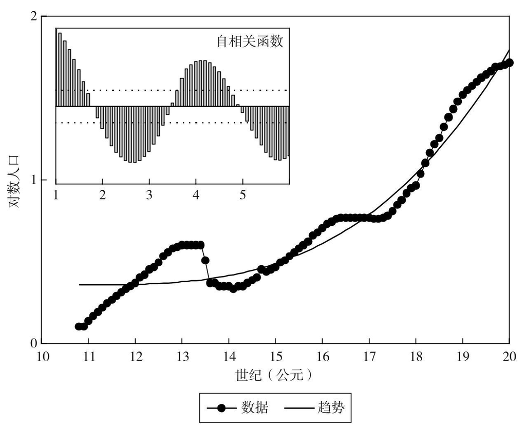

图8.1 公元1080年至2000年英格兰和威尔士的人口数量

注：本图采用对数尺度来绘制人口数量，其规模以百万计，并且以10年为间隔取样。它展现出的趋势为拟合曲线合Y=a+bX<sup>θ</sup>，其中Y=logN(t)，X代表按照0—1的间隔划分的时间刻度。ACF表示消除趋势后的数据的自相关函数。所有时间单位（包括ACF间隔）都是百年。

图8.1中已经清晰地展示出两个特点。第一个特点是它表现出不断上升的趋势。该趋势具有非线性，而且在1800年左右明显加速。人们应该不会对推动这个趋势的机制产生争议（即工业革命），所以它不是本节的关注重点。我为图8.1中的数据匹配了幂函数关系（power relationship）。这些数据展示的第二个特点是它们围绕着一般性趋势上下振荡。为了了解振荡元素的特点，我从数据中删去之前匹配的幂函数曲线，以消除数据序列中的长期趋势。

我们对去掉长期趋势的数据进行了时间序列分析。首先，我们通过自相关函数进行计算（图8.1中插入的小图展示了计算结果），得出的结果展示出明显的振荡趋势，并在第3.1个世纪达到第一个波峰。接下来，我们使用了种群动力学家常用的部分标准工具［如Turchin（2003）的第七章分析种群数据时使用的时间序列技巧］。鲍克斯和詹金斯提出的基本分析观点是对当时的种群密度N<sub>t</sub>进行回归计算，得出N<sub>t-</sub>,N<sub>t-2</sub>等滞后种群密度，其中表示时滞［请参见Chatfield（1989），他以通俗易懂的方式介绍了这部分内容］。我采用了众所周知的非线性时间序列建模方法（nonlinear time-series modeling，NLTSM），利用修正后的多项式粗略描述出当时的人口密度与滞后密度之间的关系［请参见Turchin（2003）了解操作细节］。此外，还有两个结构参数需要从数据中估算得来，即滞后密度的数值d和多项式的次数q。我们最感兴趣的是d，因为它给我们提供了“过程阶数”的估算值。

表8.1 对英国和中国人口数据进行非线性时间序列建模分析得到的结果汇总

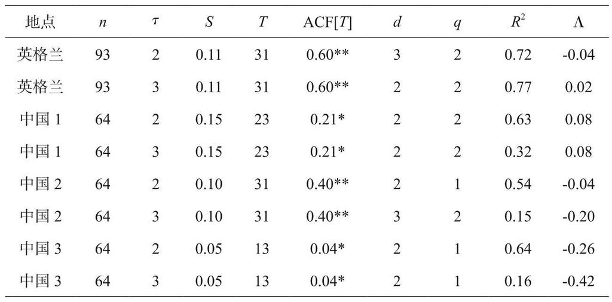

注：数量：数据点n的数量、时滞（按10年计）、振荡幅度的测算结果S（即对数转换数据的标准差）、主周期（也按10年计）、主周期的自相关函数ACF[T]（**表示lag=T时，ACF明显不同于0；*表示lag=T/2时两者相当）、估算的过程阶数d，多项式次数q、最优模型的决定系数R<sup>2</sup>以及估算的主导性李雅普诺夫指数（Lyapunov exponent）Λ。

数据：英格兰（包括威尔士）：公元1080年至2000年；中国1：公元前200年至公元430年；中国2：公元440年至1070年；中国3：公元1080年至1710年（所有数据序列都去除了长期趋势）。要强调的是，所有数据序列的取样间隔都是10年，因此所有时间段（T）和时滞（）都用同样的时间单元（即10年）来表示。